# Sains Data untuk Inovasi dan Pembangunan Regional

E-Book Pendamping Mata Kuliah Statistics for Data Science — Magister Inovasi Regional, Universitas Padjadjaran

I Gede Nyoman Mindra Jaya

2026

[figure not shown]

MAGISTER INOVASI REGIONAL · SEKOLAH PASCASARJANA · UNIVERSITAS PADJADJARAN

Sains Data untuk Inovasi dan Pembangunan Regional

E-Book Pendamping Mata Kuliah *Statistics for Data Science*

Outcome-Based Education · Case-Based Learning · Project-Based Learning · Responsible Generative AI

Penulis**I Gede Nyoman Mindra Jaya**

# Dokumen Mata Kuliah

**Dokumen resmi mata kuliah.** Rencana Pembelajaran Semester (RPS) dan Kontrak Perkuliahan menjadi acuan pembelajaran, asesmen, capstone project, penggunaan Generative AI, serta ketentuan akademik sepanjang semester. Dokumen dapat dibuka langsung di Google Drive atau diunduh melalui tombol yang tersedia.

RPS

### Rencana Pembelajaran Semester

Memuat CPL, CPMK, Sub-CPMK, bahan kajian, strategi pembelajaran, rencana 16 pertemuan, asesmen, rubrik, serta integrasi capstone project.

[Buka RPS di Google Drive](https://drive.google.com/file/d/1fGAoq56jpaOZj0GLsY3kDCyr2jhtA6Eq/view?usp=sharing) [Unduh RPS](https://drive.google.com/uc?export=download&id=1fGAoq56jpaOZj0GLsY3kDCyr2jhtA6Eq)

KP

### Kontrak Perkuliahan

Memuat tata tertib pembelajaran, sistem penilaian, ketentuan tugas dan project, academic integrity, penggunaan Generative AI, serta hak dan kewajiban mahasiswa.

[Buka Kontrak di Google Drive](https://drive.google.com/file/d/1MEqiUbNxyIAV1udTWiAVdSQJ9vyCBljh/view?usp=sharing) [Unduh Kontrak](https://drive.google.com/uc?export=download&id=1MEqiUbNxyIAV1udTWiAVdSQJ9vyCBljh)

# 0. Pendahuluan

**Kata Pengantar**

E-book ini disusun untuk mendukung pembelajaran **Sains Data/Statistics for Data Science** pada Program Magister Inovasi Regional, Sekolah Pascasarjana, Universitas Padjadjaran. Orientasi utamanya bukan menjadikan mahasiswa sebagai pengguna algoritma yang mengejar kompleksitas model, tetapi membentuk kemampuan untuk mengubah persoalan pembangunan wilayah menjadi pertanyaan analitik yang dapat dipertanggungjawabkan, memilih dan memeriksa data yang relevan, menggunakan metode statistik serta *machine learning* secara proporsional, memvalidasi hasil, dan menerjemahkan temuan menjadi rekomendasi inovasi atau kebijakan regional.

Program Magister Inovasi Regional menempatkan kompetensi berbasis data pada inti profil lulusan: administrator/manajer publik berbasis data, analis kebijakan publik berbasis data, *policy entrepreneur* yang digital dan inovatif, serta peneliti kebijakan publik berbasis data. CPL program secara eksplisit memuat kemampuan mendesain pengambilan keputusan dengan *big data* dan *machine learning*, menyusun kebijakan berbasis bukti dan proyeksi, menangkap peluang inovasi melalui *data-driven decision making*, menggunakan metode kuantitatif dan sains data untuk evaluasi kebijakan, serta mempublikasikan hasil penelitian berbasis bukti empiris. Karena itu, mata kuliah ini dirancang sebagai jembatan antara **metode kuantitatif, komputasi, konteks regional, dan keputusan publik**. (Sekolah Pascasarjana Universitas Padjadjaran 2026)

Buku ini memakai prinsip **Outcome-Based Education (OBE)**, *case-based learning*, dan satu **capstone project** yang berkembang sepanjang semester. Setiap metode diperkenalkan melalui urutan: konteks masalah → konsep → formulasi matematis → intuisi → simulasi → data nyata → implementasi R → validasi → interpretasi substantif → implikasi regional. Rumus dituliskan secara eksplisit agar mahasiswa memahami asumsi dan mekanisme metode; kode R diberikan sebagai alat untuk melakukan eksperimen dan memastikan *reproducibility*. (Wickham, Çetinkaya-Rundel, dan Grolemund 2023; James dkk. 2021; Kuhn dan Silge 2022)

Penggunaan **Generative AI** diperbolehkan secara terarah untuk membantu memahami dokumentasi, merancang kerangka kode, *debugging*, membuat alternatif visualisasi, atau menyusun dokumentasi teknis. Namun tanggung jawab ilmiah tetap berada pada mahasiswa: sumber data harus diverifikasi, kode harus diuji, hasil harus divalidasi, interpretasi harus dikerjakan secara substantif, dan penggunaan AI harus dideklarasikan. Pendekatan ini mengikuti prinsip penggunaan AI yang manusia-sentris, transparan, aman, dan dapat dipertanggungjawabkan. (Miao dan Holmes 2023; Tabassi 2023; Autio dkk. 2024)

Buku ini sengaja cukup rinci untuk jenjang magister, tetapi tetap memberi jalur belajar bertahap bagi mahasiswa dengan latar statistika dan pemrograman yang beragam. Mahasiswa yang sudah kuat secara teknis dapat memperdalam bagian formulasi dan eksperimen model; mahasiswa yang masih berkembang dalam R dapat mengikuti kode secara bertahap. Yang tidak boleh hilang pada kedua kelompok adalah kemampuan menjawab tiga pertanyaan: **(1) apakah analisisnya benar secara metodologis, (2) apakah datanya mendukung klaim yang dibuat, dan (3) apakah hasilnya bermakna bagi wilayah dan keputusan yang sedang dibahas?**

**Tujuan akhir mata kuliah.** Mahasiswa mampu menyusun alur yang utuh: **masalah regional → data → eksplorasi → model → validasi → interpretasi → insight → rekomendasi kebijakan/inovasi**, serta mempertahankan seluruh keputusan analitiknya secara ilmiah dan reproducible.

## Peta Mata Kuliah, Asesmen, dan Capstone Project

### Orientasi Kompetensi

Mata kuliah ini mengembangkan lima kelompok kompetensi yang saling terhubung.

1. **Problem framing regional:** mengenali unit analisis, stakeholder, outcome, horizon waktu, dan keputusan yang hendak didukung.
2. **Data literacy dan data engineering dasar:** provenance, metadata, kualitas, integrasi, *tidy data*, transformasi, dan *feature construction*.
3. **Statistical and machine-learning reasoning:** eksplorasi, inferensi, regresi, klasifikasi, *tree-based methods*, clustering, PCA, dan analisis spasial.
4. **Model validation dan decision translation:** resampling, ketidakpastian, fairness, robustness, interpretasi, dan sensitivitas rekomendasi.
5. **Communication and reproducibility:** visualisasi, *policy storytelling*, dashboard, laporan reproducible, sitasi, serta deklarasi penggunaan AI.

### Struktur Penilaian Semester

| Komponen | Bobot | Implementasi yang disarankan |
| --- | --- | --- |
| Capstone Project | 30% | 7 milestone, kerja kelompok, audit kontribusi individu |
| Partisipasi | 10% | diskusi kasus, kritik grafik/model, peer review, studio project |
| Kuis | 10% | 4 kuis formatif × 2,5% |
| Tugas | 10% | 4 tugas analitik × 2,5% |
| UTS | 20% | individual integrative regional data case |
| UAS | 20% | individual analytical synthesis + oral defense |
| **Total** | **100%** |  |

**Prinsip asesmen:** nilai tinggi tidak diberikan hanya karena model canggih. Mahasiswa dinilai pada ketepatan problem framing, kualitas data, validitas metode, ketepatan evaluasi, transparansi asumsi, interpretasi regional, dan kemampuan mempertahankan keputusan analitik.

## Galeri Contoh Capstone Project

Mahasiswa memilih satu persoalan sejak awal semester. Tema berikut adalah **contoh**, bukan daftar tertutup. Setiap tim wajib mempersempit isu menjadi pertanyaan yang dapat dianalisis dengan data dan memiliki stakeholder yang jelas.

### Project 1 — Peta Prioritas Pengurangan Kemiskinan Multidimensi

**Pertanyaan kebijakan:** wilayah mana yang perlu diprioritaskan, dan kombinasi deprivasi apa yang membedakan satu wilayah dengan wilayah lain?

**Data yang mungkin digunakan:** kemiskinan, pendidikan, akses kesehatan, sanitasi, internet, PDRB per kapita, dan data spasial batas administrasi dari BPS/Open Data Jawa Barat/World Bank. Data kemiskinan kabupaten/kota Jawa Barat tersedia sebagai seri tahunan 2002–2025; karena unitnya ribu jiwa, mahasiswa harus membedakan jumlah absolut dari tingkat kemiskinan. (Badan Pusat Statistik dan Pemerintah Provinsi Jawa Barat 2026a)

**Metode:** EDA, standardisasi indikator, indeks komposit dengan analisis sensitivitas bobot, PCA, clustering, pemetaan choropleth, Moran’s $I$ bila struktur spasial dianalisis.

**Produk akhir:** *policy brief*, atlas prioritas, dashboard filter kabupaten/kota, serta daftar rekomendasi yang menjelaskan bahwa prioritas tinggi dapat muncul karena mekanisme yang berbeda.

### Project 2 — Pengangguran, Struktur Ekonomi, dan Mismatch Pasar Kerja

**Pertanyaan kebijakan:** apakah wilayah dengan pertumbuhan ekonomi lebih tinggi selalu memiliki TPT lebih rendah, dan kelompok wilayah mana yang membutuhkan strategi ketenagakerjaan berbeda?

**Data:** TPT kabupaten/kota Jawa Barat 2007–2024 dan laju pertumbuhan PDRB ADHK 2011–2024, ditambah indikator pendidikan atau struktur lapangan usaha bila tersedia. (Badan Pusat Statistik dan Pemerintah Provinsi Jawa Barat 2026d, 2026b)

**Metode:** tren, korelasi, regresi, model dengan interaksi, clustering, model prediksi, evaluasi out-of-time.

**Catatan substantif:** hubungan PDRB–TPT tidak boleh langsung ditafsirkan kausal; struktur industri, partisipasi angkatan kerja, urbanisasi, dan shock ekonomi dapat menjadi penjelasan alternatif.

### Project 3 — Segmentasi Ekosistem UMKM dan Strategi Digitalisasi Daerah

**Pertanyaan kebijakan:** wilayah mana yang memiliki basis UMKM besar tetapi indikator digital/akses pasarnya masih tertinggal?

**Data:** proyeksi jumlah UMKM Jawa Barat 2016–2023, akses internet, penduduk, PDRB, atau data infrastruktur. Karena dataset UMKM berstatus **proyeksi**, status ini harus muncul pada metadata, visualisasi, dan interpretasi. (Dinas Koperasi dan Usaha Kecil Provinsi Jawa Barat 2026)

**Metode:** indikator per 1.000 penduduk, PCA, clustering, profil cluster, dashboard.

### Project 4 — Prediksi dan Prioritisasi Risiko Stunting

**Pertanyaan kebijakan:** indikator apa yang berkaitan dengan tingginya prevalensi stunting dan bagaimana mengidentifikasi wilayah untuk pemeriksaan lebih lanjut?

**Data:** prevalensi balita stunting kabupaten/kota Jawa Barat 2019–2024 atau jumlah balita stunting 2014–2024, ditambah indikator sanitasi, kemiskinan, fasilitas kesehatan, dan pendidikan. (Kementerian Kesehatan Republik Indonesia dan Pemerintah Provinsi Jawa Barat 2026)

**Metode:** regresi/klasifikasi, calibration, threshold berbasis biaya kebijakan, pemetaan, analisis sensitivitas. **Model bukan diagnosis klinis** dan tidak menggantikan verifikasi lapangan.

### Project 5 — Ketahanan Pangan dan Perubahan Kapasitas Produksi Padi

**Pertanyaan kebijakan:** wilayah mana yang menunjukkan penurunan kapasitas tanam atau ketergantungan yang tinggi, dan apakah pola tersebut membentuk klaster spasial?

**Data:** luas areal tanam padi sawah kabupaten/kota Jawa Barat 2013–2020, data penduduk, produksi, curah hujan atau penggunaan lahan jika tersedia. (Pemerintah Provinsi Jawa Barat 2026a)

**Metode:** indikator per kapita/per luas wilayah, tren, clustering, pemetaan, Moran’s $I$, skenario sensitivitas.

### Project 6 — Ketimpangan Akses Layanan Publik dan Digital Connectivity

**Pertanyaan kebijakan:** apakah pertumbuhan konektivitas digital diikuti penyempitan kesenjangan akses layanan dan outcome sosial?

**Metode:** EDA longitudinal, regresi, interaksi urban/rural bila indikator tersedia, segmentasi wilayah, dashboard.

**Risiko analitik:** *ecological fallacy*—hubungan pada level kabupaten tidak selalu berlaku pada individu.

### Project 7 — Pariwisata: Demand Recovery dan Diversifikasi Destinasi

**Pertanyaan kebijakan:** wilayah mana yang memiliki potensi kunjungan tinggi tetapi kapasitas ekonomi lokal atau konektivitasnya belum memadai?

**Metode:** indeks intensitas kunjungan, pertumbuhan tahunan, clustering, model prediksi sederhana, visualisasi spasial. Data harus dibedakan antara kunjungan, tamu, okupansi, dan jumlah objek wisata.

### Project 8 — Indeks Kapasitas Inovasi Daerah

**Pertanyaan kebijakan:** bagaimana membangun indeks kapasitas inovasi yang transparan dan sensitif terhadap pilihan indikator/bobot?

**Metode:** normalisasi, PCA sebagai pembanding indeks berbobot, analisis sensitivitas, ranking stability, clustering, dashboard. Praktik penyusunan indeks komposit harus memisahkan pilihan normatif dari pilihan statistik. (OECD dan Joint Research Centre, European Commission 2008)

### Project 9 — Investasi dan Daya Tarik Wilayah

**Pertanyaan kebijakan:** karakteristik wilayah apa yang berasosiasi dengan realisasi investasi dan bagaimana mengidentifikasi wilayah dengan *investment gap*?

**Metode:** regresi, regularisasi, model pohon, SHAP/feature importance secara hati-hati, klasifikasi wilayah berpotensi tinggi namun realisasi rendah.

### Project 10 — Transportasi, Aksesibilitas, dan Pusat Pertumbuhan

**Pertanyaan kebijakan:** apakah waktu/jarak akses menuju pusat ekonomi dan layanan berkaitan dengan outcome pembangunan wilayah?

**Metode:** feature engineering berbasis jarak, visualisasi peta, regresi, clustering, analisis sensitivitas terhadap definisi aksesibilitas.

**Aturan pemilihan project.** Project harus memiliki: satu stakeholder nyata atau realistis; satu keputusan yang hendak dibantu; minimal dua sumber data atau satu dataset multidimensi; satu komponen validasi; satu bagian interpretasi kebijakan; dokumentasi provenance; dan artefak reproducible. Model yang tidak menambah nilai terhadap pertanyaan kebijakan boleh ditolak meskipun secara teknis menarik.

### Empat Blueprint Project Siap Diadaptasi

Blueprint berikut lebih rinci daripada galeri tema. Mahasiswa **tidak harus** memilih blueprint ini, tetapi dapat menggunakannya untuk memahami level kedalaman yang diharapkan sejak pertemuan pertama.

#### Blueprint A — Sistem Prioritas Kemiskinan Multidimensi Kabupaten/Kota

**Stakeholder:** Bappeda, dinas sosial, dinas kesehatan, dinas pendidikan.  
**Decision question:** kabupaten/kota mana yang memerlukan review prioritas lintas-sektor pada siklus perencanaan berikut, dan dimensi apa yang paling menjelaskan prioritas tiap wilayah?  
**Unit analisis:** kabupaten/kota–tahun.  
**Outcome utama:** tingkat/jumlah kemiskinan atau indeks deprivasi yang dirancang transparan.  
**Kandidat data:** jumlah penduduk miskin kabupaten/kota Jawa Barat 2002–2025, TPT 2007–2024, indikator pendidikan/kesehatan/internet yang tersedia, serta batas administrasi. (Badan Pusat Statistik dan Pemerintah Provinsi Jawa Barat 2026a, 2026d)

**Feature construction:**
$$poverty\ rate=\frac{poor\ population}{population}\times100,$$
$$growth_{it}=\frac{x_{it}-x_{i,t-1}}{x_{i,t-1}},$$
$$z_{ij}=\frac{x_{ij}-\bar x_j}{s_j},$$
$$deprivation_i=\sum_jw_j z_{ij}^{oriented}.$$

**Workflow minimum:** audit metadata → harmonisasi periode → feature rate/growth → EDA disparity → indeks teori → PCA sebagai pembanding → clustering profile → peta → sensitivity bobot → optional predictive model → policy memo.

**Validation:** ranking stability terhadap bobot; bootstrap/temporal sensitivity; cek apakah top-10 berubah bila satu indikator dikeluarkan; bandingkan indeks berbobot dengan PC1.  
**Policy interpretation:** jangan hanya memberi daftar top-10. Kelompokkan alasan: kemiskinan–pengangguran tinggi, layanan rendah, digital gap, atau kombinasi. Rekomendasi harus berbeda menurut profil.  
**Dashboard:** map + profile card + trend + decomposition indikator.  
**Risiko:** denominator tidak konsisten; angka jumlah vs persen; indikator berbeda tahun; ranking false precision; stigma wilayah.  
**Deliverable final:** reproducible report 20–30 halaman ekuivalen, dashboard beta, policy brief 2 halaman, data dictionary, provenance, AI log.

#### Blueprint B — Pengangguran dan Transformasi Ekonomi Regional

**Stakeholder:** Bappeda, dinas tenaga kerja, dinas perindustrian/perdagangan.  
**Decision question:** wilayah mana yang menunjukkan persistensi TPT tinggi meskipun pertumbuhan ekonomi relatif baik, dan apakah pola tersebut mengindikasikan kebutuhan strategi pasar kerja yang berbeda?  
**Data inti:** TPT 2007–2024 dan pertumbuhan PDRB ADHK 2011–2024 dari Open Data Jawa Barat/BPS. (Badan Pusat Statistik dan Pemerintah Provinsi Jawa Barat 2026d, 2026b)

**Hipotesis analitik contoh:** hubungan pertumbuhan dan TPT dapat non-linear serta berbeda menurut tipe wilayah. Model associational:
$$TPT_{it}=\beta_0+\beta_1Growth_{it}+\beta_2Education_{it}+\beta_3Urban_i+\beta_4(Growth_{it}\times Urban_i)+\varepsilon_{it}.$$
Untuk prediksi satu tahun ke depan, gunakan lag:
$$TPT_{i,t+1}=f(TPT_{it},Growth_{it},Education_{it},Digital_{it},\ldots).$$

**Workflow:** time-series profile per wilayah → shock detection → scatter/faceting → baseline OLS → temporal validation → random forest/boosting bila memberi nilai tambah → clustering residual profile → spatial map residual → recommendation.

**Pertanyaan interpretasi:** wilayah dengan TPT aktual jauh di atas prediksi baseline dapat menjadi “positive/negative residual case” untuk diagnostic review. Residual bukan bukti kegagalan kebijakan; ia menunjukkan outcome tidak dijelaskan penuh oleh fitur model.

**Validation:** train ≤2021, validation 2022–2023, test 2024 sebagai contoh; jangan random split jika target masa depan. Bandingkan naive baseline $\hat y_{t+1}=y_t$ dengan regression/ML.  
**Policy outputs:** empat tipologi: high TPT–high growth, high TPT–low growth, low TPT–high growth, low TPT–low growth; kemudian interpretasikan dengan indikator tambahan.  
**Risiko:** pandemi, perubahan survei/metode, pooled ecological inference, target leakage.

#### Blueprint C — Segmentasi UMKM dan Kesiapan Digital Regional

**Stakeholder:** dinas koperasi/UMKM, dinas komunikasi/informatika, pemerintah kabupaten/kota.  
**Decision question:** paket dukungan apa yang berbeda untuk wilayah dengan basis UMKM besar tetapi readiness digital/akses pasar yang berbeda?  
**Data inti:** proyeksi UMKM kabupaten/kota 2016–2023—status **proyeksi** harus dipertahankan pada seluruh dokumentasi. (Dinas Koperasi dan Usaha Kecil Provinsi Jawa Barat 2026)

**Feature contoh:**
$$UMKMpc_i=\frac{UMKM_i}{population_i}\times1000,$$
$$DigitalGap_i=100-Internet_i,$$
$$LQ_{ik}=\frac{sector\ share_{ik}}{province\ sector\ share_k}.$$

**Metode:** EDA → robust scaling → PCA untuk reduksi collinearity → k-means/hierarchical clustering → silhouette/stability → map cluster → profile → policy package. Jika tersedia outcome digital adoption, classification dapat ditambahkan.

**Pertanyaan penting:** apakah cluster stabil jika variabel count diganti per-capita? Jika tidak, cluster awal mungkin hanya mengelompokkan ukuran populasi.  
**Policy package contoh:** cluster 1 basis usaha besar–digital tinggi → market expansion; cluster 2 basis usaha besar–digital rendah → onboarding/infra; cluster 3 basis kecil–akses rendah → ecosystem building; cluster 4 basis kecil–akses tinggi → entrepreneurship/product development. Ini hanyalah contoh interpretasi dan harus mengikuti hasil aktual.

**Validation:** silhouette, multiple starts, alternative K, removal of one dominant feature, scaling alternatives.  
**Dashboard:** cluster map; radar/profile plot secukupnya; table indikator; filter tahun.  
**Risiko:** proyeksi dianggap real count; cluster labels normatif; outlier metropolitan mendominasi; data UMKM formal/informal berbeda cakupan.

#### Blueprint D — Stunting Risk Screening dan Prioritas Verifikasi

**Stakeholder:** dinas kesehatan/Bappeda.  
**Decision question:** wilayah mana yang memiliki probabilitas tinggi terhadap kategori prevalensi stunting tinggi dan membutuhkan review data/intervensi lebih lanjut?  
**Data:** prevalensi stunting 2019–2024 atau jumlah stunting 2014–2024 dari Open Data Jawa Barat, plus indikator kemiskinan, sanitasi, kesehatan, pendidikan. (Kementerian Kesehatan Republik Indonesia dan Pemerintah Provinsi Jawa Barat 2026)

**Label contoh**—hanya bila ada threshold kebijakan/akademik yang sah:
$$Y_i=I(prevalence_i\ge c).$$
Jangan menciptakan threshold seolah resmi. Jika $c$ hanya untuk latihan, tulis “analytical threshold for classroom demonstration”.

**Model baseline:** logistic regression
$$\log\frac{p_i}{1-p_i}=\beta_0+\beta_1Poverty_i+\beta_2Sanitation_i+\beta_3HealthAccess_i+\cdots.$$
Bandingkan random forest bila ada cukup observasi dan fitur. Untuk data hanya 27 kabupaten × beberapa tahun, kompleksitas model harus sangat hati-hati; effective sample size dan dependence perlu dibahas.

**Metric:** sensitivity, precision, calibration, PR/ROC; threshold dipilih dengan cost false negative/kapasitas review.  
**Spatial:** peta prevalensi dan residual/risk; Moran diagnostic jika layak.  
**Interpretasi:** model adalah **screening analytic**, bukan alat diagnosis anak/rumah tangga dan bukan pengganti survei/verifikasi kesehatan.  
**Fairness/coverage:** cek perform menurut urban/rural atau region group bila sample memungkinkan; hindari klaim subgroup dengan n terlalu kecil.  
**Policy output:** prioritas verifikasi, data gaps, dan opsi penguatan surveillance; bukan automatic funding allocation tanpa review manusia.

**Standar proposal capstone minggu 2.** Proposal dianggap siap bila dapat menjawab: siapa stakeholder; keputusan apa; data apa dan sampai tahun berapa; outcome apa; unit analisis apa; metode baseline apa; metode alternatif apa; bagaimana validasi; apa risiko bias; dan produk kebijakan apa. Jika satu poin belum dapat dijawab, milestone harus merekamnya sebagai pertanyaan terbuka dengan rencana penyelesaian.

### Milestone Capstone Minggu 1–16

| Minggu | Milestone | Deliverable utama | Bobot project |
| --- | --- | --- | --- |
| 1 | Tema dan stakeholder | 1 paragraf masalah + calon sumber data | formatif |
| 2 | M1 Problem Framing | *one-page problem brief*, decision question, unit analisis | 3% |
| 3 | Data inventory | metadata, lisensi, definisi indikator, join key | formatif |
| 4 | M2 Data Dossier | data dictionary, audit kualitas, cleaning log | 4% |
| 5 | EDA draft | 3–5 grafik yang menjawab pertanyaan | formatif |
| 6 | M3 Evidence Story | EDA, deskriptif/inferensial awal, narasi regional | 5% |
| 7 | Baseline model | model sederhana + split/resampling | formatif |
| 8 | UTS + project clinic | revisi problem framing berdasarkan umpan balik | — |
| 9 | Model alternatif | tree/ensemble atau model lain yang relevan | formatif |
| 10 | M4 Predictive/Classification Model | perbandingan model + evaluasi | 5% |
| 11 | Segmentasi | cluster profile atau heterogenitas wilayah | formatif |
| 12 | M5 Regional Heterogeneity | PCA/cluster/segmentasi + interpretasi | 4% |
| 13 | Spatial evidence | peta, neighborhood definition, spatial diagnostic | formatif |
| 14 | Robustness/fairness | sensitivity analysis + uncertainty | formatif |
| 15 | M6 Policy & Dashboard Beta | policy options + dashboard beta | 4% |
| 16 | M7 Final Reproducible Package | report, code, data dictionary, dashboard, AI log | 5% |
|  | **Total Project** |  | **30%** |

### Rubrik Capstone Project

| Dimensi | Bobot di dalam Project | Kriteria unggul |
| --- | --- | --- |
| Relevansi masalah & pertanyaan | 15% | Masalah nyata, unit analisis dan keputusan jelas, stakeholder terpetakan |
| Data provenance & quality | 15% | Sumber kredibel, metadata lengkap, cleaning terdokumentasi, keterbatasan eksplisit |
| Metode & validasi | 25% | Metode proporsional, baseline tersedia, leakage dicegah, metrik sesuai, uncertainty dibahas |
| Interpretasi regional | 20% | Menghubungkan hasil dengan heterogenitas wilayah dan mekanisme substantif tanpa overclaim |
| Rekomendasi kebijakan/inovasi | 10% | Spesifik, feasible, target dan indikator monitoring jelas, risiko dibahas |
| Visualisasi/dashboard | 5% | Akurat, terbaca, metadata terlihat, dan tidak misleading |
| Reproducibility & AI integrity | 5% | Kode dapat dijalankan, seed/dependency tercatat, AI-use log lengkap |
| Presentasi & respons kritik | 5% | Narasi terstruktur dan mampu mempertahankan metodologi serta keterbatasan |
| **Total** | **100% dari Project = 30% MK** |  |

## Template Capstone Project Terintegrasi

Template berikut **merupakan bagian dari e-book ini**. Mahasiswa tidak perlu menggunakan file template terpisah. Struktur ini digunakan sejak minggu pertama dan diperbarui pada setiap milestone. Tujuannya adalah menjaga *evidence chain*: **masalah → data → metode → validasi → interpretasi → rekomendasi → monitoring**.

### Halaman Identitas Project

Tuliskan judul project, nama anggota tim, stakeholder sasaran, wilayah studi, periode data, tanggal pembaruan terakhir, serta tautan repositori/penyimpanan data jika diizinkan. Judul harus menyatakan **masalah regional dan tujuan analitik**, bukan hanya nama algoritma.

### Ringkasan Eksekutif

Maksimum 300 kata yang memuat: masalah, keputusan yang didukung, data, metode utama, tiga temuan, dua keterbatasan, dan rekomendasi. Ringkasan ini **ditulis terakhir**, walaupun ditempatkan di awal laporan.

### Problem Framing dan Stakeholder

Gunakan tabel berikut.

| Elemen | Isian wajib |
| --- | --- |
| Masalah regional | Masalah spesifik, terukur, dan relevan bagi wilayah |
| Stakeholder | Instansi/kelompok yang menggunakan hasil |
| Decision question | Keputusan apa yang akan dibantu oleh analisis |
| Unit analisis | Desa, kecamatan, kabupaten/kota, provinsi, wilayah-tahun, dsb. |
| Outcome/indikator | Definisi operasional, satuan, denominator |
| Horizon | Deskriptif saat ini, prediksi tahun depan, monitoring multi-tahun, dsb. |
| Risiko salah keputusan | Konsekuensi false positive/false negative atau salah ranking |

### Data Dossier dan Provenance

| Dataset | Produsen | URL/Sumber | Tahun | Unit | Variabel kunci | Status | Keterbatasan |
| --- | --- | --- | --- | --- | --- | --- | --- |
| Dataset 1 |  |  |  |  |  | final/proyeksi/sementara |  |
| Dataset 2 |  |  |  |  |  |  |  |

Setiap dataset wajib memiliki *access date*, lisensi jika tersedia, perubahan definisi, dan catatan transformasi. Tidak diperkenankan menyalin data dari agregator sekunder jika sumber resmi masih tersedia.

### Import Data dan Reproducibility Check

```r
panel_capstone <- readr::read_csv("data/simulasi_panel_regional.csv", show_col_types = FALSE)
tibble::tibble(
  n_baris = nrow(panel_capstone),
  n_wilayah = dplyr::n_distinct(panel_capstone$wilayah),
  tahun_min = min(panel_capstone$tahun),
  tahun_maks = max(panel_capstone$tahun),
  missing_total = sum(is.na(panel_capstone))
) |>
  knitr::kable(caption = "Output awal: audit struktur dataset capstone")
```

Table 0.1: Output awal: audit struktur dataset capstone

| n_baris | n_wilayah | tahun_min | tahun_maks | missing_total |
| --- | --- | --- | --- | --- |
| 189 | 27 | 2019 | 2025 | 0 |

### Data Cleaning dan Quality Audit

Laporan minimal memuat duplicate key, missingness, range check, consistency check, join mismatch, perubahan kode wilayah, dan keputusan outlier. Semua transformasi harus dilakukan melalui kode, bukan melalui edit manual spreadsheet yang tidak terdokumentasi.

```r
cap_qc <- panel_capstone |>
  dplyr::group_by(tahun) |>
  dplyr::summarise(
    n = dplyr::n(),
    missing_kemiskinan = mean(is.na(kemiskinan_persen)),
    min_kemiskinan = min(kemiskinan_persen, na.rm = TRUE),
    max_kemiskinan = max(kemiskinan_persen, na.rm = TRUE),
    .groups = "drop"
  )
knitr::kable(cap_qc, digits = 3, caption = "Output quality audit per tahun")
```

Table 0.2: Output quality audit per tahun

| tahun | n | missing_kemiskinan | min_kemiskinan | max_kemiskinan |
| --- | --- | --- | --- | --- |
| 2019 | 27 | 0 | 12.056 | 17.664 |
| 2020 | 27 | 0 | 10.589 | 18.048 |
| 2021 | 27 | 0 | 10.734 | 17.976 |
| 2022 | 27 | 0 | 8.477 | 16.303 |
| 2023 | 27 | 0 | 8.570 | 15.518 |
| 2024 | 27 | 0 | 8.636 | 13.924 |
| 2025 | 27 | 0 | 6.006 | 13.055 |

### Exploratory Data Analysis dan Evidence Board

Minimal terdapat empat jenis bukti: distribusi, perbandingan antardaerah, hubungan antarindikator, dan perubahan waktu. Setiap grafik harus memiliki *take-away sentence* satu atau dua kalimat.

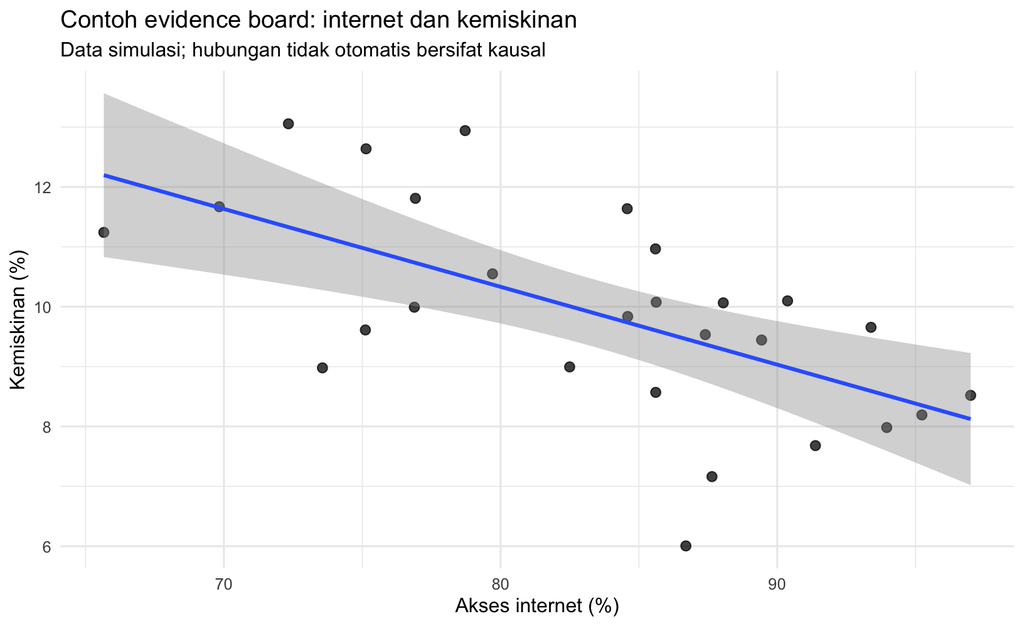

```r
panel_capstone |>
  dplyr::filter(tahun == max(tahun)) |>
  ggplot2::ggplot(ggplot2::aes(internet_persen, kemiskinan_persen)) +
  ggplot2::geom_point(size = 2.4, alpha = .75) +
  ggplot2::geom_smooth(method = "lm", se = TRUE) +
  ggplot2::labs(
    title = "Contoh evidence board: internet dan kemiskinan",
    subtitle = "Data simulasi; hubungan tidak otomatis bersifat kausal",
    x = "Akses internet (%)", y = "Kemiskinan (%)"
  )
```

### Baseline Model

Model pertama harus sederhana dan dapat dijelaskan. Baseline berfungsi sebagai pembanding terhadap model yang lebih kompleks.

```r
cap_latest <- panel_capstone |> dplyr::filter(tahun == max(tahun))
cap_lm <- lm(kemiskinan_persen ~ internet_persen + pdrb_perkapita_juta + tpt_persen + ipm,
             data = cap_latest)
broom::tidy(cap_lm, conf.int = TRUE) |>
  knitr::kable(digits = 3, caption = "Output baseline regression")
```

Table 0.3: Output baseline regression

| term | estimate | std.error | statistic | p.value | conf.low | conf.high |
| --- | --- | --- | --- | --- | --- | --- |
| (Intercept) | 7.522 | 23.830 | 0.316 | 0.755 | -41.897 | 56.941 |
| internet_persen | -0.012 | 0.068 | -0.180 | 0.859 | -0.152 | 0.128 |
| pdrb_perkapita_juta | -0.102 | 0.060 | -1.697 | 0.104 | -0.226 | 0.023 |
| tpt_persen | -0.233 | 0.282 | -0.826 | 0.417 | -0.818 | 0.352 |
| ipm | 0.145 | 0.343 | 0.423 | 0.677 | -0.567 | 0.857 |

### Model Alternatif dan Evaluasi

Jika model alternatif digunakan, tunjukkan **nilai tambah terhadap baseline**. Pilih metrik berdasarkan tujuan keputusan; gunakan data validasi untuk pemilihan model/hyperparameter dan simpan data test untuk evaluasi akhir.

```r
set.seed(260826)
cap_train <- panel_capstone |> dplyr::filter(tahun <= 2023)
cap_test  <- panel_capstone |> dplyr::filter(tahun >= 2024)
cap_fit <- lm(kemiskinan_persen ~ internet_persen + pdrb_perkapita_juta + tpt_persen + ipm,
              data = cap_train)
cap_eval <- cap_test |>
  dplyr::mutate(pred = predict(cap_fit, newdata = cap_test)) |>
  dplyr::summarise(
    RMSE = sqrt(mean((kemiskinan_persen - pred)^2)),
    MAE  = mean(abs(kemiskinan_persen - pred))
  )
knitr::kable(cap_eval, digits = 3, caption = "Output evaluasi out-of-time")
```

Table 0.4: Output evaluasi out-of-time

| RMSE | MAE |
| --- | --- |
| 1.413 | 1.096 |

### Robustness, Sensitivity, dan Subgroup Analysis

Uji minimal satu keputusan analitik: bobot indeks, threshold, pilihan fitur, tahun holdout, jumlah cluster, seed, atau definisi matriks bobot spasial. Jelaskan **bagian kesimpulan yang stabil dan yang sensitif**.

### Interpretasi Regional

Gunakan format empat lapis:

1. **Temuan statistik:** apa pola/output yang diperoleh?
2. **Makna substantif:** apa arti pola itu bagi karakteristik wilayah?
3. **Batas klaim:** deskriptif, asosiasional, prediktif, atau kausal?
4. **Implikasi keputusan:** tindakan atau investigasi apa yang masuk akal?

### Rekomendasi Kebijakan atau Strategi Inovasi

Setiap rekomendasi harus mempunyai rantai: **evidence → target → instrumen → risiko → indikator monitoring**. Hindari kalimat generik seperti “pemerintah perlu meningkatkan perhatian”.

### Dashboard atau Visualisasi Interaktif

Dashboard bersifat opsional jika tidak menambah nilai keputusan. Jika digunakan, minimal memiliki filter wilayah/periode, definisi indikator, sumber data, catatan terakhir diperbarui, dan caveat interpretasi.

### Deklarasi Penggunaan Generative AI

| Tanggal | Tool/model | Tujuan | Output AI yang digunakan | Cara verifikasi | Modifikasi manusia |
| --- | --- | --- | --- | --- | --- |

AI tidak boleh menjadi sumber angka faktual tanpa verifikasi sumber primer. Seluruh kode yang dibantu AI tetap menjadi tanggung jawab mahasiswa.

### Reproducibility Handover

Project dinyatakan siap bila anggota tim lain dapat membuka folder project dan menjalankan ulang analisis hanya dari README dan kode yang tersedia.

```r
cat("R version dan package yang digunakan pada saat knit:\n")
```

```
#> R version dan package yang digunakan pada saat knit:
```

[session information not shown]

### Checklist Deliverable Final

- Laporan reproducible HTML.
- *Policy brief* maksimum dua halaman.
- Data dictionary dan provenance register.
- Folder `R/` atau script analisis yang terstruktur.
- Folder data dengan penjelasan sumber/lisensi; data sensitif tidak dibagikan tanpa izin.
- Dashboard/visual interaktif bila relevan.
- AI-use log.
- README untuk menjalankan ulang analisis.
- Slide presentasi dan lampiran metodologis.
- Pernyataan kontribusi anggota tim.

## Peta Bacaan, Rumus Kunci, dan Target Akademik per Pertemuan

Bagian ini berfungsi sebagai **reading map** agar mahasiswa tidak membaca e-book secara linear tanpa prioritas. Setiap pertemuan memiliki tiga lapis target: **minimum competency** (wajib dikuasai seluruh mahasiswa), **analytical competency** (mampu memilih dan menguji metode), dan **master-level competency** (mampu menjelaskan asumsi, keterbatasan, serta konsekuensi keputusan). Bacaan utama harus dipakai untuk memahami logika metode; dokumentasi package dipakai untuk implementasi, bukan sebagai pengganti referensi metodologis.

| Minggu | Fokus | Rumus/konsep yang wajib dikuasai | Bacaan inti | Bukti belajar |
| --- | --- | --- | --- | --- |
| 1 | Problem framing | empirical risk, loss, indeks komposit, utility | Provost dan Fawcett (2013); James dkk. (2021); OECD dan Joint Research Centre, European Commission (2008) | problem canvas + pertanyaan analitik |
| 2 | Ekosistem/open data | rate, proportion, growth, CAGR, missingness | Wickham, Çetinkaya-Rundel, dan Grolemund (2023); Gebru dkk. (2021) | data dossier + metadata |
| 3 | Wrangling & quality | z-score, robust z, IQR, MAD, LQ | Wickham (2014); Little dan Rubin (2019) | reproducible cleaning log |
| 4 | EDA | mean/median, variance, covariance, correlation, Gini, Theil | Tukey (1977); Wickham, Çetinkaya-Rundel, dan Grolemund (2023) | EDA notebook + anomaly log |
| 5 | Visualization | slope, index, uncertainty interval, denominator awareness | Wilkinson (2005); Tufte (2001) | evidence story |
| 6 | Inferensi & regresi | OLS, sampling uncertainty, CI, $R^2$, VIF, interaction | Harrell (2015); James dkk. (2021) | model card awal |
| 7 | Predictive modeling | RMSE/MAE, CV, regularization, ridge/lasso | Kuhn dan Silge (2022); Hastie, Tibshirani, dan Friedman (2009) | validation memo |
| 8 | UTS | integrasi minggu 1–7 | seluruh bacaan minggu 1–7 | individual case analysis |
| 9 | Tree-based ML | impurity, bagging, random forest, boosting | Breiman (2001); Friedman (2001); Chen dan Guestrin (2016) | baseline-vs-ML comparison |
| 10 | Classification | logit, likelihood, sensitivity/specificity, F1, AUC, calibration | Fawcett (2006); James dkk. (2021) | threshold decision memo |
| 11 | Clustering | distance, within-cluster SS, silhouette, Ward | Kaufman dan Rousseeuw (1990) | segment profile |
| 12 | PCA | covariance/correlation matrix, eigenvalue, PVE, score/loading | Jolliffe dan Cadima (2016) | dimensionality memo |
| 13 | Spatial data | CRS, neighborhood, Moran’s $I$, Local Moran | Pebesma (2018); Moran (1950); Anselin (1995) | spatial diagnostic |
| 14 | Evaluation/robustness | bootstrap, rank stability, fairness, leakage, out-of-time validation | Hardt, Price, dan Srebro (2016); Kuhn dan Silge (2022) | robustness audit |
| 15 | Policy translation | utility, uncertainty, causal caution, DiD overview | Hernán dan Robins (2020); Callaway dan Sant’Anna (2021) | policy brief + dashboard beta |
| 16 | UAS/defense | synthesis, reproducibility, uncertainty, AI disclosure | Gebru dkk. (2021); Mitchell dkk. (2019); Miao dan Holmes (2023) | final package + oral defense |

### Cara Membaca Rumus pada E-Book

Setiap persamaan perlu dibaca melalui **empat lapisan**. Pertama, identifikasi objek matematisnya: apakah skalar, vektor, matriks, probabilitas, atau fungsi. Kedua, jelaskan apa yang dioptimalkan atau diringkas. Ketiga, sebutkan asumsi yang diperlukan agar interpretasi sah. Keempat, terjemahkan kembali hasil ke konteks regional. Sebagai contoh, persamaan regresi

$$\mathbf{y}=\mathbf{X}\boldsymbol\beta+\boldsymbol\varepsilon$$

bukan sekadar instruksi menjalankan `lm()`. Mahasiswa harus mampu menjelaskan bahwa $\mathbf{y}\in\mathbb{R}^{n}$ adalah vektor outcome, $\mathbf{X}\in\mathbb{R}^{n\times p}$ adalah matriks desain, $\boldsymbol\beta\in\mathbb{R}^{p}$ adalah koefisien populasi yang ingin dipelajari, dan $\boldsymbol\varepsilon$ merepresentasikan variasi yang belum dijelaskan model. Jika unit observasi adalah kabupaten-tahun, asumsi independensi sederhana dapat terganggu oleh pengulangan wilayah dan korelasi temporal; jika unit berdekatan secara geografis, residual juga dapat berkorelasi spasial. Karena itu, kemampuan membaca struktur data harus mendahului interpretasi koefisien.

### Standar Penulisan Jawaban Matematis

Untuk kuis, tugas, UTS, dan UAS, jawaban matematis yang dinilai penuh harus memuat: **(1)** rumus, **(2)** definisi seluruh simbol, **(3)** substitusi nilai bila tersedia, **(4)** hasil numerik dengan satuan, dan **(5)** interpretasi substantif. Contoh jawaban yang hanya menulis “RMSE = 2,7 dan model A lebih baik” belum lengkap. Jika outcome adalah TPT dalam persen, jawaban yang lebih tepat adalah: “RMSE 2,7 berarti besar kesalahan prediksi tipikal dalam skala akar-kuadrat sekitar 2,7 poin persentase TPT; dibanding baseline 3,5, model memberi peningkatan prediksi, tetapi kegunaan kebijakannya tetap perlu dinilai terhadap variasi antardaerah dan biaya salah prioritas.”

### Standar Sitasi Akademik dan Sitasi Dataset

Mahasiswa wajib membedakan **referensi metode** dan **referensi data**. Referensi metode menjelaskan teori atau algoritma; sitasi dataset menjelaskan asal bukti empiris. Mengutip buku machine learning tidak menggantikan kewajiban mengutip BPS/Open Data Jawa Barat sebagai pemilik atau penyedia data. Untuk dataset dinamis, catat **judul dataset, instansi penghasil, portal, URL, cakupan tahun yang benar-benar digunakan, tanggal akses, unit observasi, satuan, serta status angka** (misalnya final, sementara, estimasi, atau proyeksi).

Contoh format dokumentasi data yang direkomendasikan:

> **Dataset:** Tingkat Pengangguran Terbuka Berdasarkan Kabupaten/Kota di Jawa Barat. **Penghasil:** Badan Pusat Statistik; **portal:** Open Data Jawa Barat; **cakupan portal:** 2007–2024; **unit analisis:** kabupaten/kota-tahun; **variabel outcome:** `tingkat_pengangguran_terbuka`; **satuan:** persen; **tanggal akses:** dicatat saat pengunduhan. (Badan Pusat Statistik dan Pemerintah Provinsi Jawa Barat 2026d)

Dalam laporan, mahasiswa tidak boleh menyalin definisi portal tanpa memeriksa denominator dan konteks statistiknya. Misalnya, TPT adalah persentase penganggur terhadap angkatan kerja, bukan terhadap seluruh penduduk. Prinsip yang sama berlaku untuk jumlah penduduk miskin: angka absolut dalam ribu jiwa tidak identik dengan persentase kemiskinan. Perbedaan denominator dapat mengubah ranking wilayah dan rekomendasi kebijakan.

### Target Kedalaman Jenjang Magister

Pada level magister, mahasiswa diharapkan bergerak melampaui eksekusi software. Untuk setiap metode utama, mahasiswa harus dapat menjawab setidaknya enam pertanyaan berikut.

1. **Apa estimand atau target prediksinya?** Contoh: rata-rata outcome, koefisien parsial, probabilitas kelas, cluster membership, atau skor komponen utama.
2. **Apa asumsi pentingnya?** Contoh: linearitas, independensi, representativitas, stabilitas distribusi, atau definisi neighborhood spasial.
3. **Bagaimana model divalidasi?** Training error tidak cukup untuk menilai generalisasi.
4. **Apa bentuk ketidakpastian?** Sampling uncertainty, model uncertainty, measurement error, atau uncertainty akibat pilihan preprocessing dapat berbeda.
5. **Apa konsekuensi substantif salah model?** False negative dalam prioritisasi stunting berbeda implikasinya dengan kesalahan prediksi PDRB.
6. **Apa batas klaim?** Prediksi, asosiasi, dan kausalitas adalah tiga jenis klaim yang tidak boleh dipertukarkan.

**Standar kelulusan konseptual.** Mahasiswa tidak cukup mengatakan “saya menggunakan Random Forest karena akurasinya tinggi.” Mereka harus menjelaskan baseline pembanding, skema resampling, hyperparameter, risiko leakage, metrik yang dipakai, uncertainty, interpretability, dan mengapa peningkatan performa tersebut cukup relevan untuk keputusan regional.

## Panduan Tugas dan Kuis Mingguan

Selain empat tugas besar dan empat kuis berbobot yang dijelaskan pada bagian asesmen, dosen dapat menggunakan latihan berikut sebagai **formative checkpoints**. Nilainya dapat dimasukkan ke partisipasi atau dipakai sebagai latihan tanpa bobot. Setiap checkpoint dirancang agar mahasiswa terus mengembangkan capstone.

### Checkpoint Minggu 1–4

**Minggu 1 — Problem framing clinic.** Setiap tim membawa dua kandidat masalah regional. Dalam 5 menit, tim harus menjelaskan stakeholder, keputusan, unit observasi, outcome, horizon waktu, dan alasan data science diperlukan. Kelas memberikan kritik apakah pertanyaan terlalu luas, normatif, atau tidak dapat diuji.

**Minggu 2 — Metadata challenge.** Mahasiswa menerima tiga dataset yang kelihatannya kompatibel, tetapi berbeda cakupan tahun, satuan, atau kode wilayah. Tugasnya adalah menemukan minimal lima risiko integrasi sebelum melakukan `join`. Kuis singkat meminta mahasiswa menghitung rate, growth, dan CAGR serta menjelaskan kapan masing-masing ukuran menyesatkan.

**Minggu 3 — Data-quality audit.** Mahasiswa membuat *audit table* berisi duplicate, missingness, range violation, impossible value, join mismatch, dan perubahan definisi. Setiap keputusan cleaning harus disertai alasan; penghapusan observasi tanpa dokumentasi dinilai sebagai kegagalan reproducibility.

**Minggu 4 — EDA evidence board.** Setiap tim menghasilkan empat visual/summary yang menjawab empat fungsi berbeda: distribusi, perbandingan, hubungan, dan perubahan waktu. Tim juga harus menuliskan satu temuan yang awalnya tampak menarik tetapi ternyata dapat dijelaskan oleh denominator atau outlier.

### Checkpoint Minggu 5–7

**Minggu 5 — Visualization red-team.** Mahasiswa saling menukar grafik dan mencari potensi manipulasi: truncated axis, kategori terlalu banyak, penggunaan warna tanpa fungsi, agregasi yang menutupi heterogenitas, atau label yang membuat korelasi tampak kausal. Revisi grafik menjadi bagian dari evidence story.

**Minggu 6 — Regression defense.** Mahasiswa harus memilih satu spesifikasi regresi dan satu alternatif. Mereka menjelaskan arti $\beta_j$, asumsi, potensi confounding, multicollinearity, residual pattern, dan mengapa interaksi digunakan atau tidak digunakan. Fokusnya bukan “semua variabel signifikan”, melainkan konsistensi model dengan pertanyaan.

**Minggu 7 — Validation lab.** Mahasiswa membandingkan baseline mean/median, regresi, serta satu model regularized. Mereka harus menetapkan split sebelum tuning dan menjelaskan mengapa random split atau time-based split lebih sesuai. Jika data panel, mahasiswa mendiskusikan risiko satu wilayah muncul di train dan test dengan observasi tahun berbeda.

### Checkpoint Minggu 9–12

**Minggu 9 — Complexity budget.** Tim hanya boleh memakai model tree-based yang lebih rumit jika dapat menunjukkan peningkatan out-of-sample yang bermakna dibanding baseline dan model sederhana. Selisih metrik harus diterjemahkan ke unit outcome, bukan hanya persen peningkatan abstrak.

**Minggu 10 — Threshold workshop.** Untuk kasus klasifikasi prioritas intervensi, mahasiswa menghitung confusion matrix pada beberapa threshold dan menyusun tabel konsekuensi kebijakan. Pilihan threshold harus mengacu pada false-positive/false-negative cost dan kapasitas intervensi.

**Minggu 11 — Cluster naming discipline.** Cluster dilarang diberi nama normatif seperti “maju” dan “tertinggal” sebelum profil indikator diperiksa. Tim harus memberikan nama deskriptif yang berasal dari centroid/medoid atau distribusi indikator, lalu menguji stabilitas cluster terhadap scaling dan jumlah cluster.

**Minggu 12 — PCA interpretation.** Mahasiswa menjelaskan loadings, scores, eigenvalues, dan explained variance tanpa menyebut PC1 sebagai “indeks pembangunan” secara otomatis. Label substantif hanya boleh diberikan jika pola loading dan konstruk teoritis mendukungnya.

### Checkpoint Minggu 13–16

**Minggu 13 — Spatial-neighbor challenge.** Setiap tim membandingkan minimal dua definisi $W$ (misalnya queen contiguity dan k-nearest neighbors) dan menjelaskan perubahan Moran’s $I$ atau local pattern. Tujuannya menunjukkan bahwa hasil spasial dipengaruhi definisi neighborhood.

**Minggu 14 — Robustness red-team.** Tim lain mencoba “merusak” kesimpulan dengan mengganti seed, indikator, bobot, threshold, jumlah cluster, atau spesifikasi model. Kesimpulan yang berubah drastis harus dinyatakan sebagai sensitif, bukan disembunyikan.

**Minggu 15 — Policy translation studio.** Setiap rekomendasi harus terhubung ke satu temuan, satu kelompok sasaran, satu instrumen, satu risiko implementasi, dan satu indikator monitoring. Kalimat rekomendasi yang generik seperti “pemerintah perlu meningkatkan perhatian” harus direvisi menjadi tindakan yang dapat dinilai.

**Minggu 16 — Reproducibility handover.** Seorang mahasiswa dari tim lain mencoba membuka dan menjalankan paket project dengan hanya membaca README. Kegagalan karena path lokal, objek yang belum dibuat, file tidak tersedia, atau langkah manual yang tidak terdokumentasi masuk ke *reproducibility defect log*.

## Contoh Pertanyaan Kuis Tambahan

1. Sebuah kabupaten memiliki 20.000 penganggur dan angkatan kerja 250.000 orang. Hitung TPT dan jelaskan mengapa membagi dengan total penduduk adalah keliru.
2. Jika indikator kemiskinan memiliki mean 8,2 dan simpangan baku 2,0, berapa z-score untuk wilayah dengan nilai 11,2? Interpretasikan relatif terhadap distribusi sampel.
3. Mengapa korelasi Pearson tinggi antara PDRB per kapita dan penetrasi internet tidak membuktikan efek kausal internet terhadap PDRB?
4. Kapan median lebih relevan daripada mean untuk merangkum distribusi pendapatan regional?
5. Jelaskan perbedaan training error, validation error, dan test error. Data mana yang boleh digunakan untuk memilih hyperparameter?
6. Pada klasifikasi wilayah prioritas, kapan recall lebih penting daripada precision? Berikan contoh kebijakan.
7. Mengapa standardisasi fitur penting sebelum k-means? Tunjukkan pengaruh skala pada Euclidean distance.
8. Apa konsekuensi menggunakan PCA pada covariance matrix ketika satu indikator memiliki satuan dan variance jauh lebih besar dibanding indikator lain?
9. Jelaskan mengapa Moran’s $I$ bergantung pada definisi matriks bobot spasial $W$.
10. Sebutkan tiga bentuk *data leakage* yang mungkin terjadi pada prediksi indikator kabupaten-tahun.
11. Mengapa model dengan RMSE minimum belum tentu merupakan pilihan kebijakan terbaik?
12. Apa yang harus dicantumkan dalam deklarasi penggunaan Generative AI agar proses analisis tetap transparan?

## Kisi-Kisi Evaluasi yang Lebih Operasional

### Kisi-Kisi UTS 20%

UTS bersifat **individual, open-resource terbatas**, berbentuk satu kasus data regional terintegrasi. Data disediakan dalam keadaan belum sepenuhnya bersih agar mahasiswa menunjukkan kemampuan audit, bukan sekadar menjalankan model. Distribusi yang disarankan adalah: 15% problem framing dan metadata; 20% cleaning/data quality; 20% EDA/visualisasi; 25% inferensi/regresi; 10% validasi dan diagnostic; 10% interpretasi kebijakan. Nilai UTS dalam komponen akhir tetap 20%; persentase di atas adalah distribusi **di dalam skor UTS**.

**Rumus yang boleh/harus dikuasai:** rate/proportion, growth dan CAGR, mean/variance/covariance/correlation, z-score, confidence interval dasar, OLS, $R^2$, adjusted $R^2$, RMSE dan MAE. Mahasiswa dapat diberikan satu halaman formula sheet, tetapi harus mampu menjelaskan setiap simbol dan memilih formula yang sesuai.

**Contoh stimulus UTS:** dataset 27 kabupaten/kota dengan TPT, pertumbuhan PDRB, kemiskinan, dan pendidikan untuk beberapa tahun. Mahasiswa diminta mengaudit denominator, membuat dua visual evidence, mengestimasi regresi, memeriksa minimal dua diagnostic, membandingkan baseline, lalu menulis rekomendasi maksimum 250 kata yang tidak melakukan klaim kausal berlebihan.

### Kisi-Kisi UAS 20%

UAS menilai **sintesis individual** dan dipisahkan dari nilai produk kelompok capstone. Distribusi yang disarankan: 20% problem-method alignment; 20% formulasi dan penjelasan metode; 20% validasi/robustness; 20% interpretasi regional dan rekomendasi; 10% reproducibility/data provenance; 10% oral defense dan responsible AI disclosure.

Mahasiswa harus siap menurunkan atau menjelaskan minimal satu rumus yang benar-benar digunakan dalam project, misalnya OLS, logistic likelihood, k-means objective, PCA eigenproblem, atau Moran’s $I$. Pertanyaan lisan diarahkan pada keputusan yang dibuat mahasiswa: “mengapa threshold ini?”, “mengapa $k=4$?”, “apa akibat mengganti $W$?”, “apa bukti bahwa model menggeneralisasi?”, “bagian mana yang dibantu AI dan bagaimana diverifikasi?”.

**Pemisahan Project dan UAS.** Project 30% menilai kualitas produk kelompok dan milestone sepanjang semester. UAS 20% menilai penguasaan individual terhadap logika, matematika, validasi, interpretasi, dan integritas proses. Dengan desain ini, kontribusi individual tetap dapat diverifikasi.

## Standar Output Analisis pada E-Book

Setiap analisis kuantitatif pada buku ini mengikuti urutan keluaran yang konsisten agar mahasiswa tidak berhenti pada sintaks. Urutan minimal adalah **(1) pemeriksaan data, (2) statistik deskriptif, (3) visualisasi eksploratif, (4) estimasi/model, (5) diagnostik atau evaluasi, (6) visualisasi hasil, dan (7) interpretasi regional**. Untuk metode yang tidak memerlukan model prediktif, bagian evaluasi diganti dengan *quality check*, *sensitivity analysis*, atau pemeriksaan asumsi yang relevan.

Kode R sengaja ditulis sehingga objek yang penting **dicetak langsung di bawah code chunk** melalui `knitr::kable()`, `print()`, `yardstick`, atau objek grafik `ggplot2`. Dengan demikian mahasiswa dapat membaca hubungan antara kode dan hasil, bukan hanya menyalin script.

**Aturan pedagogis.** Setiap angka atau visual yang dipakai dalam kesimpulan harus dapat ditelusuri ke data, definisi variabel, transformasi, metode, dan kode yang menghasilkan output tersebut.

## Protokol Audit Analitik Umum

Protokol berikut berlaku untuk seluruh bab dan tidak diulang pada setiap pertemuan.

1. **Replikasi:** jalankan ulang analisis dari sesi R baru dan pastikan output utama dapat direproduksi.
2. **Alternative specification:** ubah satu keputusan penting—fitur, scaling, threshold, bobot, split, atau definisi neighborhood—kemudian periksa apakah kesimpulan berubah.
3. **Policy translation:** terjemahkan output menjadi implikasi regional tanpa melebihkan jenis bukti. Bedakan klaim deskriptif, asosiasional, prediktif, kausal, dan rekomendasi.
4. **Reproducibility:** dokumentasikan package, versi data, seed, dan dependency yang diperlukan.
5. **AI audit:** bila Generative AI digunakan, simpan prompt atau ringkasan penggunaannya dan tunjukkan verifikasi manusia terhadap kode, sumber, dan interpretasi.
6. **Evidence tag:** selama drafting, tandai klaim sebagai **D** (descriptive), **A** (associational), **P** (predictive), **C** (causal), atau **R** (recommendation) untuk mencegah *claim inflation*.

Pada jenjang magister, jawaban “package menghasilkan output tersebut” tidak cukup. Setiap output harus dapat dijelaskan melalui **definisi → asumsi → keputusan analitik → hasil → ketidakpastian → implikasi regional**.

## Cara Menggunakan E-Book

E-book ini dirancang untuk membangun alur berpikir **masalah regional → data → eksplorasi → model → validasi → interpretasi → insight → rekomendasi kebijakan/inovasi**. R digunakan sebagai *computational laboratory*, bukan sebagai tujuan akhir. Karena itu, setiap bab selalu menghubungkan metode dengan pertanyaan substantif: *apa masalah wilayahnya, indikator apa yang relevan, unit analisisnya apa, apa sumber ketidakpastiannya, dan keputusan apa yang akan didukung oleh hasil analisis?*

Mahasiswa Magister Inovasi Regional tidak diwajibkan menjadi *machine-learning engineer*. Namun, mahasiswa harus mampu menjadi **pengguna analitik yang kritis**: dapat membedakan analisis deskriptif, inferensial, prediktif, dan kausal; memahami konsekuensi kualitas data; memilih model yang proporsional dengan masalah; mengevaluasi model secara tepat; serta menerjemahkan keluaran statistik menjadi rekomendasi yang dapat dipertanggungjawabkan. Pendekatan ini konsisten dengan orientasi program pada kebijakan publik berbasis data, *data-driven decision making*, evaluasi kebijakan, dan inovasi regional.

### Paket Berkas

- `Sains_Data_Inovasi_Regional.Rmd`: naskah utama e-book.
- `references.bib`: pustaka untuk sitasi otomatis.
- `R/00_setup.R`: konfigurasi package dan fungsi utilitas.
- `R/01_generate_simulation_data.R`: pembangkit data simulasi dengan `set.seed()`.
- `R/02_download_real_data.R`: pengunduh INDO-DAPOER World Bank.
- `R/03_prepare_indodapoer.R`: penataan data INDO-DAPOER ke format tidy.
- `R/04_open_data_jabar.R`: pola impor Open Data Jawa Barat.
- `data/`: snapshot data simulasi dan katalog sumber data nyata.

### Prinsip Reproducibility

Setiap analisis minimal mencatat: (1) sumber data dan tanggal akses, (2) definisi unit observasi, (3) kode pembersihan data, (4) aturan penanganan missing value/outlier, (5) pemisahan data training-test bila prediktif, (6) seed untuk proses acak, (7) package dan versi, dan (8) deklarasi penggunaan Generative AI. Untuk proyek akhir, hasil yang tidak dapat direproduksi dari kode dan data yang tersedia dianggap belum selesai, meskipun visualisasinya menarik.

### Catatan Data Nyata

Contoh utama menggunakan **INDO-DAPOER**, basis data subnasional Indonesia dari World Bank yang mencakup lebih dari 200 indikator fiskal, ekonomi, sosial-demografi, dan infrastruktur pada level provinsi/distrik. Data ini sangat baik untuk latihan karena struktur panelnya kaya, tetapi cakupan waktunya berakhir pada 2018 sehingga **tidak boleh dipresentasikan sebagai gambaran kondisi terkini**. Untuk isu terbaru Jawa Barat, mahasiswa diarahkan ke Open Data Jawa Barat/BPS dan wajib mencatat status angka (final, sementara, proyeksi) serta perubahan definisi/kode wilayah. (World Bank 2026; Pemerintah Provinsi Jawa Barat 2026b; Badan Pusat Statistik 2026)

# 1 Sains Data dan Inovasi Regional

## 1.1 Pendahuluan

Sains data untuk inovasi regional dimulai bukan dari algoritma, melainkan dari **masalah keputusan**. Ketimpangan antarwilayah, kemiskinan, akses layanan, produktivitas UMKM, mobilitas, kualitas lingkungan, dan daya inovasi memiliki mekanisme berbeda. Data science membantu menyatukan data administratif, survei, geospasial, sensor, dan sumber digital menjadi bukti yang dapat diuji. Pada jenjang magister, mahasiswa perlu bergerak dari pertanyaan “metode apa yang bisa digunakan?” ke pertanyaan “bukti apa yang dibutuhkan untuk keputusan ini, dengan asumsi dan keterbatasan apa?”. (Provost dan Fawcett 2013)

## 1.2 Tujuan Pembelajaran

Setelah bab ini, mahasiswa mampu: membedakan analisis deskriptif, diagnostik, prediktif, dan preskriptif; merumuskan masalah regional menjadi pertanyaan analitik; menentukan unit analisis; mengidentifikasi stakeholder; dan merancang *minimum viable analysis* untuk capstone.

## 1.3 Definisi dan Konsep

**Sains data** adalah praktik interdisipliner yang menggabungkan pemahaman substantif, statistika, komputasi, dan komunikasi untuk mengekstraksi informasi yang dapat digunakan dari data. Dalam konteks regional, “wilayah” bukan hanya label administratif; wilayah dapat memuat kedekatan spasial, jaringan ekonomi, arus komuter, struktur demografi, dan kapasitas kelembagaan. Karena itu, dua kabupaten dengan indikator rata-rata serupa belum tentu memiliki kebutuhan kebijakan yang sama.

Empat mode analitik yang penting adalah: **deskriptif** (apa yang terjadi?), **diagnostik** (pola apa yang menyertainya?), **prediktif** (apa yang mungkin terjadi pada observasi baru?), dan **preskriptif** (alternatif tindakan apa yang layak dipertimbangkan?). Analisis prediktif yang akurat tidak otomatis menghasilkan kesimpulan kausal. Korelasi antara internet dan kemiskinan, misalnya, belum membuktikan bahwa peningkatan internet *menyebabkan* penurunan kemiskinan.

## 1.4 Formulasi Matematis

Secara sederhana, data dapat ditulis sebagai matriks

$$\mathbf{X}=[x_{ij}], \qquad i=1,\ldots,n,\; j=1,\ldots,p,$$

di mana $n$ adalah jumlah unit observasi (misalnya kabupaten-tahun), $p$ jumlah variabel, dan $x_{ij}$ nilai variabel ke-$j$ pada observasi ke-$i$. Outcome yang ingin dijelaskan/prediksi ditulis $y_i$. Sebuah model prediktif mencari fungsi

$$\hat y_i=f(\mathbf{x}_i),$$

dengan $\mathbf{x}_i$ vektor fitur wilayah ke-$i$ dan $\hat y_i$ prediksi. Kualitas model tidak hanya ditentukan oleh kedekatan $\hat y_i$ terhadap $y_i$, tetapi juga relevansi fitur, kualitas data, stabilitas, fairness, serta kegunaan keputusan.

### 1.4.1 Dari masalah keputusan ke fungsi objektif

Dalam pembelajaran tingkat magister, algoritma dapat dipandang sebagai prosedur untuk memilih fungsi $f$ dari suatu kelas fungsi $\mathcal{F}$. Jika $L(y,\hat y)$ adalah fungsi kerugian (*loss function*), risiko populasi didefinisikan sebagai

$$R(f)=\mathbb{E}_{(X,Y)\sim P}\left[L\{Y,f(X)\}\right].$$

Distribusi populasi $P$ tidak diketahui, sehingga pada data pelatihan $(\mathbf{x}_i,y_i)_{i=1}^{n}$ kita menggunakan **empirical risk**

$$\widehat R_n(f)=\frac{1}{n}\sum_{i=1}^{n}L\{y_i,f(\mathbf{x}_i)\}.$$

Untuk outcome kontinu, pilihan yang umum adalah squared-error loss

$$L(y,\hat y)=(y-\hat y)^2,$$

sedangkan untuk keputusan klasifikasi biner dapat digunakan 0–1 loss

$$L(y,\hat y)=I(y\neq \hat y).$$

Namun biaya kebijakan sering tidak simetris. Misalkan $C_{FN}$ adalah biaya *false negative* (wilayah membutuhkan intervensi tetapi tidak diprioritaskan) dan $C_{FP}$ biaya *false positive*. Kerugian keputusan dapat ditulis

$$L(y,\hat y)=C_{FN}I(y=1,\hat y=0)+C_{FP}I(y=0,\hat y=1).$$

Konsekuensinya penting: **threshold terbaik secara kebijakan tidak harus 0,5**. Nilai threshold harus mempertimbangkan biaya, kapasitas intervensi, serta konsekuensi salah klasifikasi. (James dkk. 2021; Hastie, Tibshirani, dan Friedman 2009)

### 1.4.2 Indikator, normalisasi, dan indeks komposit

Banyak persoalan regional menggunakan beberapa indikator. Jika indikator $x_{ij}$ memiliki unit yang berbeda, dua transformasi umum adalah **min–max scaling**

$$z_{ij}^{(mm)}=\frac{x_{ij}-\min_i(x_{ij})}{\max_i(x_{ij})-\min_i(x_{ij})},$$

dan **z-score standardization**

$$z_{ij}=\frac{x_{ij}-\bar x_j}{s_j}, \qquad
s_j=\sqrt{\frac{1}{n-1}\sum_{i=1}^n(x_{ij}-\bar x_j)^2}.$$

Indeks komposit berbobot dapat ditulis

$$S_i=\sum_{j=1}^{p} w_j z_{ij},\qquad w_j\ge 0,\qquad \sum_{j=1}^{p}w_j=1.$$

Jika indikator “lebih tinggi = lebih buruk”, sedangkan indikator lain “lebih tinggi = lebih baik”, arah harus diseragamkan sebelum agregasi. Untuk skala 0–1, pembalikan sederhana adalah $z_{ij}^{*}=1-z_{ij}$. Pilihan bobot $w_j$ adalah bagian dari desain kebijakan dan harus diuji dengan **sensitivity analysis**. OECD/JRC menekankan pentingnya kerangka teori, seleksi indikator, normalisasi, pembobotan, agregasi, serta analisis ketidakpastian pada indeks komposit. (OECD dan Joint Research Centre, European Commission 2008)

### 1.4.3 Dari prediksi menuju keputusan

Misalkan $a\in\mathcal{A}$ adalah alternatif tindakan dan $\theta$ keadaan dunia yang tidak diketahui. Dalam kerangka keputusan sederhana, kita memilih

$$a^{*}=\arg\max_{a\in\mathcal{A}}\mathbb{E}\{U(a,\theta)\mid \mathcal{D}\},$$

di mana $U(a,\theta)$ adalah utilitas tindakan dan $\mathcal{D}$ adalah data. Rumus ini mengingatkan bahwa prediksi $\hat y$ hanyalah salah satu input keputusan. Kapasitas anggaran, risiko, fairness, implementability, dan preferensi stakeholder dapat mengubah pilihan tindakan walaupun prediksi sama.

### 1.4.4 Notasi inti yang akan dipakai sepanjang buku

| Simbol | Makna |
| --- | --- |
| $n$ | jumlah unit observasi |
| $p$ | jumlah fitur/variabel prediktor |
| $\mathbf{X}\in\mathbb{R}^{n\times p}$ | matriks fitur |
| $\mathbf{x}_i$ | vektor fitur observasi/wilayah ke-$i$ |
| $y_i$ | outcome aktual |
| $\hat y_i$ | outcome prediksi |
| $f(\cdot)$ | fungsi/model prediksi |
| $L(\cdot)$ | fungsi kerugian |
| $R(f)$ | risiko populasi |
| $\widehat R_n(f)$ | empirical risk |
| $w_j$ | bobot indikator ke-$j$ |

### 1.4.5 Kesalahan konseptual yang harus dihindari

1. **Prediction ≠ causation.** Model yang dapat memprediksi kemiskinan tidak otomatis menjelaskan intervensi apa yang akan menurunkannya. (Hernán dan Robins 2020)
2. **Administrative unit ≠ mechanism.** Kabupaten/kota adalah unit pelaporan; mekanisme sosial-ekonomi dapat melintasi batas tersebut.
3. **Ranking ≠ diagnosis.** Peringkat tinggi hanyalah sinyal prioritas; diagnosis kebijakan membutuhkan pembacaan indikator penyusun dan konteks lokal.
4. **Model accuracy ≠ policy value.** Perbaikan RMSE yang sangat kecil dapat tidak bernilai jika interpretasi, biaya implementasi, atau fairness memburuk.
5. **Open data ≠ ready-to-model data.** Ketersediaan publik tidak menjamin definisi stabil, lengkap, dan kompatibel antarsumber.

## 1.5 Intuisi Metode

Bayangkan pemerintah daerah harus menentukan 20 kecamatan prioritas. “Memilih model” baru relevan setelah definisi prioritas disepakati: apakah berdasarkan tingkat kemiskinan, tren memburuk, kerentanan guncangan, kekurangan layanan, atau kombinasi beberapa indikator? Sains data yang baik membuat definisi tersebut eksplisit sehingga hasil dapat diaudit.

### 1.5.1 Worked Example — dari isu kebijakan ke target analitik

Misalkan Bappeda memiliki tiga kabupaten hipotetis A, B, dan C. Outcome yang ingin diprioritaskan adalah *multiple deprivation*. Tiga indikator setelah orientasi “lebih tinggi = lebih buruk” adalah kemiskinan $z_1$, kekurangan internet $z_2$, dan kekurangan akses kesehatan $z_3$. Setelah min–max scaling diperoleh:

| Wilayah | $z_1$ | $z_2$ | $z_3$ |
| --- | --- | --- | --- |
| A | 0.90 | 0.70 | 0.40 |
| B | 0.55 | 0.85 | 0.80 |
| C | 0.35 | 0.30 | 0.90 |

Dengan bobot $(0.50,0.30,0.20)$,
$$S_A=0.50(0.90)+0.30(0.70)+0.20(0.40)=0.74,$$
$$S_B=0.50(0.55)+0.30(0.85)+0.20(0.80)=0.69,$$
$$S_C=0.50(0.35)+0.30(0.30)+0.20(0.90)=0.445.$$

Ranking awal adalah A–B–C. Tetapi bila stakeholder menyatakan akses layanan dasar lebih kritis dan bobot menjadi $(0.35,0.25,0.40)$, maka
$$S_A=0.35(0.90)+0.25(0.70)+0.40(0.40)=0.650,$$
$$S_B=0.35(0.55)+0.25(0.85)+0.40(0.80)=0.725,$$
$$S_C=0.35(0.35)+0.25(0.30)+0.40(0.90)=0.558.$$
Ranking berubah menjadi B–A–C. **Pelajaran:** ranking bukan fakta alam; ia merupakan konsekuensi data, definisi indikator, transformasi, dan preferensi bobot. Maka laporan harus memisahkan hasil empiris dari pilihan normatif. (OECD dan Joint Research Centre, European Commission 2008)

### 1.5.2 Problem-framing canvas

Sebelum membuka R, isi enam kotak berikut.

| Pertanyaan | Contoh jawaban |
| --- | --- |
| Siapa pengambil keputusan? | Bappeda provinsi + dinas terkait |
| Keputusan apa? | memilih 10 kabupaten untuk diagnostic review lanjutan |
| Unit analisis? | kabupaten–tahun |
| Outcome? | indeks kerentanan atau TPT tahun berikutnya |
| Horizon? | alokasi program tahun anggaran berikut |
| Kesalahan paling mahal? | tidak memasukkan wilayah benar-benar rentan |

Bila jawaban “keputusan apa?” masih berupa “mengetahui kondisi”, project belum cukup tajam. Ubah menjadi keputusan yang dapat ditindaklanjuti: prioritas, alokasi, screening, evaluasi, pemantauan, atau desain inovasi.

### 1.5.3 Empirical-risk example dengan cost tidak simetris

Anggap 100 wilayah: 20 benar-benar prioritas. Model A menghasilkan FN=2 dan FP=20; model B FN=7 dan FP=5. Jika $C_{FN}=5$ dan $C_{FP}=1$:
$$C_A=5(2)+1(20)=30,$$
$$C_B=5(7)+1(5)=40.$$
Walau model B mempunyai lebih sedikit false positive, model A lebih baik menurut cost policy yang ditetapkan. Jika cost berubah, pilihan dapat berubah. Karena itu pemilihan metric dan threshold harus mengikuti konsekuensi keputusan, bukan kebiasaan default software.

### 1.5.4 Implementasi R langkah demi langkah

```r
set.seed(260811)
idx <- tibble::tribble(
  ~wilayah, ~kemiskinan, ~internet, ~akses,
  "A", 19, 45, 60,
  "B", 14, 35, 45,
  "C", 10, 70, 40
) |>
  mutate(
    kemiskinan_mm = (kemiskinan-min(kemiskinan))/(max(kemiskinan)-min(kemiskinan)),
    kurang_internet = 1-(internet-min(internet))/(max(internet)-min(internet)),
    kurang_akses = 1-(akses-min(akses))/(max(akses)-min(akses)),
    score_s1 = .50*kemiskinan_mm + .30*kurang_internet + .20*kurang_akses,
    score_s2 = .35*kemiskinan_mm + .25*kurang_internet + .40*kurang_akses
  )
knitr::kable(idx, digits = 3, caption = "Sensitivity of regional priority scores")
```

Table 1.1: Sensitivity of regional priority scores

| wilayah | kemiskinan | internet | akses | kemiskinan_mm | kurang_internet | kurang_akses | score_s1 | score_s2 |
| --- | --- | --- | --- | --- | --- | --- | --- | --- |
| A | 19 | 45 | 60 | 1.000 | 0.714 | 0.00 | 0.714 | 0.529 |
| B | 14 | 35 | 45 | 0.444 | 1.000 | 0.75 | 0.672 | 0.706 |
| C | 10 | 70 | 40 | 0.000 | 0.000 | 1.00 | 0.200 | 0.400 |

Perhatikan bahwa kode menyimpan **indikator asli** dan **indikator tertransformasi**. Jangan menimpa kolom mentah karena audit trail akan hilang.

### 1.5.5 Pertanyaan refleksi tingkat magister

- Apakah target yang dipilih merupakan outcome yang memang dapat dipengaruhi oleh kebijakan dalam horizon yang tersedia?
- Apakah unit analisis terlalu agregat untuk mekanisme yang ingin dijelaskan?
- Apakah ranking diperlukan, atau interval/cluster lebih jujur terhadap uncertainty?
- Apa baseline keputusan tanpa model? Misalnya aturan existing atau indikator tunggal.
- Berapa *minimum useful improvement* yang membuat model baru layak dipakai?
- Siapa yang dapat dirugikan jika model salah?

## 1.6 Contoh dengan Data Simulasi

```r
set.seed(260801)
contoh_wilayah <- tibble(
  wilayah = paste0("W", 1:12),
  kemiskinan = runif(12, 4, 20),
  internet = runif(12, 35, 95),
  akses_layanan = runif(12, 40, 90)
) |>
  mutate(skor_prioritas = 0.6*kemiskinan + 0.25*(100-internet) + 0.15*(100-akses_layanan)) |>
  arrange(desc(skor_prioritas))
knitr::kable(contoh_wilayah, digits = 2, caption = "Contoh pembentukan skor prioritas wilayah (simulasi)")
```

Table 1.2: Contoh pembentukan skor prioritas wilayah (simulasi)

| wilayah | kemiskinan | internet | akses_layanan | skor_prioritas |
| --- | --- | --- | --- | --- |
| W6 | 19.53 | 44.94 | 70.63 | 29.89 |
| W5 | 17.09 | 55.12 | 49.86 | 28.99 |
| W12 | 14.64 | 43.64 | 70.98 | 27.23 |
| W3 | 10.65 | 48.82 | 52.30 | 26.34 |
| W1 | 4.49 | 36.43 | 59.87 | 24.61 |
| W8 | 15.68 | 57.89 | 69.55 | 24.50 |
| W4 | 4.01 | 40.70 | 66.96 | 22.18 |
| W2 | 16.44 | 90.05 | 56.19 | 18.92 |
| W10 | 11.79 | 90.01 | 44.67 | 17.87 |
| W7 | 6.21 | 54.16 | 83.45 | 17.67 |
| W11 | 9.46 | 91.96 | 41.85 | 16.41 |
| W9 | 5.16 | 79.46 | 84.76 | 10.52 |

### 1.6.1 Visualisasi Output: Prioritas Wilayah

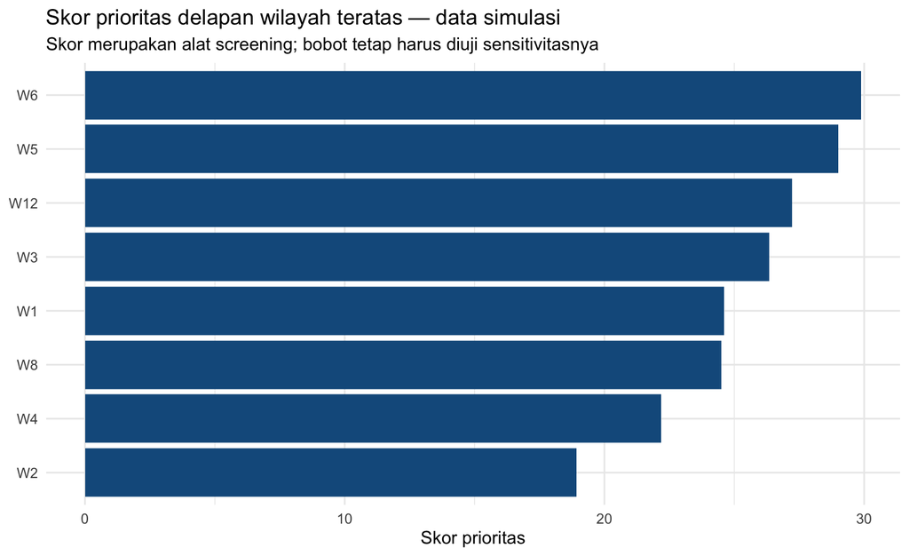

```r
contoh_wilayah |>
  dplyr::slice_head(n = 8) |>
  ggplot2::ggplot(ggplot2::aes(x = reorder(wilayah, skor_prioritas), y = skor_prioritas)) +
  ggplot2::geom_col(fill = "#145B8C") +
  ggplot2::coord_flip() +
  ggplot2::labs(
    title = "Skor prioritas delapan wilayah teratas — data simulasi",
    subtitle = "Skor merupakan alat screening; bobot tetap harus diuji sensitivitasnya",
    x = NULL, y = "Skor prioritas"
  )
```

Contoh ini menunjukkan bahwa definisi indeks adalah keputusan normatif-analitik. Bobot 0,60; 0,25; dan 0,15 bukan “ditemukan” oleh R. Bobot harus dibenarkan dengan teori, proses kebijakan, atau analisis sensitivitas.

## 1.7 Contoh dengan Data Nyata

**INDO-DAPOER** menyediakan indikator provinsi dan kabupaten/kota Indonesia dalam kelompok fiskal, ekonomi, sosial-demografi, dan infrastruktur, dengan cakupan historis 1976-2018. Unit observasi praktisnya adalah wilayah-tahun-indikator. Sumber aslinya antara lain BPS dan kementerian/lembaga Indonesia. Lisensinya CC BY 4.0. Kelebihannya adalah keluasan indikator dan format panel; keterbatasan utamanya adalah data tidak mutakhir dan konsistensi definisi perlu diperiksa antarperiode. (World Bank 2026)

**Kartu dataset real.**

- **Nama:** Indonesia Database for Policy and Economic Research (INDO-DAPOER).
- **Sumber dan URL:** World Bank Data Catalog, https://datacatalog.worldbank.org/search/dataset/0041056/indonesia-database-for-policy-and-economic-research.
- **Tahun:** 1976–2018 (cakupan keseluruhan; ketersediaan aktual berbeda per indikator).
- **Unit observasi:** provinsi/kabupaten/kota–tahun–indikator.
- **Variabel yang digunakan:** kode/nama wilayah; tahun; kode indikator; nilai indikator. Contoh: `SI.POV.NAPR.ZS` = poverty rate (% penduduk), `IDX.HDI` = Human Development Index, `SP.POP.TOTL` = total population.
- **Alasan digunakan:** panel subnasional lintas-sektor cocok untuk melatih problem framing, integrasi indikator, dan analisis disparitas.
- **Keterbatasan:** bukan data terkini; missingness dan cakupan indikator tidak seragam; perubahan definisi/kode wilayah harus diaudit. (World Bank 2026)

## 1.8 Analisis Menggunakan R

```r
# Jika INDO-DAPOER sudah diunduh, gunakan data resmi; bila belum, tampilkan
# struktur indikator dari data simulasi agar e-book tetap dapat diknit offline.
if (dir.exists("data/raw/indodapoer") && length(list.files("data/raw/indodapoer")) > 0) {
  source("R/03_prepare_indodapoer.R")
  indo <- load_indodapoer()
  out <- indo |>
    dplyr::distinct(kode_indikator, indikator) |>
    dplyr::filter(stringr::str_detect(indikator, stringr::regex("poverty|unemploy|development|GDP", ignore_case = TRUE))) |>
    dplyr::arrange(indikator) |>
    head(15)
} else {
  out <- tibble::tribble(
    ~kode_indikator, ~indikator,
    "SIM.POV", "Kemiskinan (%) — simulasi",
    "SIM.TPT", "Tingkat pengangguran terbuka (%) — simulasi",
    "SIM.HDI", "Indeks pembangunan manusia — simulasi",
    "SIM.GDPPC", "PDRB per kapita (juta) — simulasi"
  )
}
knitr::kable(out, caption = "Output: daftar indikator yang relevan dengan problem framing")
```

Table 1.3: Output: daftar indikator yang relevan dengan problem framing

| kode_indikator | indikator |
| --- | --- |
| SIM.POV | Kemiskinan (%) — simulasi |
| SIM.TPT | Tingkat pengangguran terbuka (%) — simulasi |
| SIM.HDI | Indeks pembangunan manusia — simulasi |
| SIM.GDPPC | PDRB per kapita (juta) — simulasi |

Langkah pertama bukan langsung memodelkan, tetapi membaca metadata dan mengecek apakah indikator benar-benar merepresentasikan konsep yang sedang dibahas.

## 1.9 Interpretasi dalam Konteks Regional

Jika suatu wilayah memiliki kemiskinan tinggi tetapi akses internet dan layanan dasar juga rendah, masalahnya dapat mengarah pada *multiple deprivation*. Sebaliknya, pengangguran tinggi di kota dengan PDRB tinggi dapat menunjukkan mismatch tenaga kerja, struktur industri, atau tekanan urbanisasi. Rekomendasi kebijakan harus mengikuti pola substantif ini, bukan sekadar ranking algoritmik.

## 1.10 Latihan

1. Jelaskan perbedaan pertanyaan deskriptif dan prediktif untuk masalah pengangguran.
2. Mengapa unit “kabupaten” dan “kabupaten-tahun” menghasilkan struktur analisis berbeda?
3. Berikan contoh korelasi yang tidak boleh langsung dibaca sebagai hubungan kausal.
4. **Analisis data:** gunakan `simulasi_panel_regional.csv` untuk memilih lima wilayah yang tampak paling tertinggal pada 2025 berdasarkan minimal tiga indikator.
5. **Analisis data:** lakukan analisis sensitivitas dengan dua skema bobot indeks prioritas.
6. **Mini-case:** Bappeda meminta “model AI untuk menentukan desa prioritas”. Susun lima pertanyaan klarifikasi sebelum Anda menulis satu baris kode pun.

### 1.10.1 Tugas Terstruktur Pertemuan 1

**Studio problem framing (formatif menuju M1).** Pilih satu dari sepuluh contoh capstone atau usulkan tema lain. Buat 1 halaman yang memuat: masalah publik; stakeholder; decision question; unit analisis; outcome; minimal 5 kandidat indikator; horizon waktu; risiko salah keputusan; serta satu kalimat yang menjelaskan mengapa analisis tersebut **bukan sekadar membuat dashboard**.

**Rubrik (100):** problem significance 20; analytical question 20; unit/outcome clarity 15; data plausibility 15; decision relevance 20; caveat/ethics 10.

### 1.10.2 Kuis Formatif Pertemuan 1

1. Apa perbedaan *prediction target* dan *policy target*?
2. Mengapa korelasi yang kuat tidak cukup untuk rekomendasi intervensi?
3. Jika cost false negative lima kali false positive, apa konsekuensi terhadap threshold?
4. Mengapa bobot indeks prioritas perlu sensitivity analysis?
5. Tulis satu contoh unit analisis yang salah untuk pertanyaan “perubahan pengangguran kabupaten 2015–2024”, lalu perbaiki.

## 1.11 Hubungan dengan Capstone Project

Milestone awal: pilih satu masalah regional, tentukan stakeholder, unit analisis, outcome/indikator utama, dan keputusan yang hendak didukung. Hasilnya berupa *one-page problem brief*.

## 1.12 Kesimpulan

Sains data regional adalah disiplin pengambilan keputusan berbasis bukti. Algoritma penting, tetapi kualitas formulasi masalah, definisi indikator, data provenance, dan interpretasi kebijakan menentukan apakah analisis benar-benar berguna.

## 1.13 Pendalaman Magister — Problem framing dan decision science

### 1.13.1 Audit metodologis

1. Outcome terlalu jauh dari keputusan aktual.
2. Unit administrasi dipakai tanpa alasan.
3. Indikator normatif dicampur dengan fitur prediktif.
4. Ranking diperlakukan sebagai kebenaran absolut.
5. Stakeholder tidak menentukan false-positive/false-negative cost.
6. Model dipilih sebelum masalah dirumuskan.

### 1.13.2 Pertanyaan viva / diskusi kelas

1. Apa baseline keputusan tanpa model?
2. Klaim apa yang hanya deskriptif dan mana yang prediktif?
3. Bagaimana bobot indeks dipertanggungjawabkan?
4. Siapa yang menanggung kerugian jika ranking salah?
5. Bagaimana menguji stabilitas ranking?
6. Apa bukti bahwa outcome relevan dengan horizon kebijakan?

# 2 Ekosistem Data, Open Data, dan Data Provenance

## 2.1 Pendahuluan

Analisis regional sering gagal bukan karena model, melainkan karena data berasal dari sistem yang berbeda: kode wilayah berubah, definisi indikator tidak identik, periode pencatatan tidak sinkron, dan angka proyeksi diperlakukan seperti hasil observasi. Bab ini menempatkan **provenance** dan metadata sebagai bagian dari metode ilmiah, bukan urusan administratif.

## 2.2 Tujuan Pembelajaran

Mahasiswa mampu memetakan ekosistem data regional, mengevaluasi kualitas sumber, membuat *data inventory*, membedakan data primer/sekunder/administratif/open data, dan menyusun dokumentasi dataset (*datasheet*).

## 2.3 Definisi dan Konsep

**Data provenance** adalah jejak asal-usul data: siapa produsen data, bagaimana data dikumpulkan, kapan diperbarui, transformasi apa yang dilakukan, dan lisensi apa yang berlaku. *Datasheets for datasets* membantu mendokumentasikan motivasi, komposisi, proses pengumpulan, preprocessing, penggunaan yang direkomendasikan, serta keterbatasan. (Gebru dkk. 2021)

Dalam analisis regional, cek minimal: unit geografis, kode wilayah, frekuensi waktu, definisi denominator, perubahan metodologi, status angka sementara/final, missingness, dan *revision policy*. “Jumlah penduduk miskin” tidak sama dengan “persentase penduduk miskin”; perbandingan antarkabupaten membutuhkan denominator.

## 2.4 Formulasi Matematis

Untuk indikator berbasis rasio,

$$r_i=\frac{a_i}{b_i}\times c,$$

di mana $a_i$ adalah pembilang, $b_i$ denominator, dan $c$ konstanta skala (misalnya 100 untuk persen atau 1.000 untuk per seribu). Membandingkan $a_i$ tanpa mempertimbangkan $b_i$ dapat menimbulkan *size bias*.

Missingness dapat diringkas sebagai

$$m_j=\frac{1}{n}\sum_{i=1}^n I(x_{ij}\;\text{missing}),$$

dengan $I(\cdot)$ fungsi indikator. Nilai $m_j$ adalah proporsi missing untuk variabel $j$.

### 2.4.1 Struktur indikator: count, rate, proportion, index, dan stock–flow

Mahasiswa harus membedakan tipe indikator karena operasi matematis yang sah berbeda. **Count** adalah jumlah kejadian/unit, **rate** menghubungkan kejadian dengan populasi berisiko dan periode waktu, **proportion** adalah bagian dari keseluruhan, sedangkan **index** biasanya merupakan transformasi beberapa komponen.

Proporsi:
$$p_i=\frac{a_i}{n_i},\qquad 0\le p_i\le 1.$$

Rate per $k$ penduduk:
$$r_i=\frac{a_i}{n_i}\times k.$$

Perubahan absolut dan relatif:
$$\Delta x_t=x_t-x_{t-1},\qquad
g_t=\frac{x_t-x_{t-1}}{x_{t-1}}\times100\%.$$

Jika interval lebih dari satu tahun, *compound annual growth rate* (CAGR) adalah
$$\operatorname{CAGR}=\left(\frac{x_T}{x_0}\right)^{1/T}-1.$$

**Stock** diukur pada titik waktu (misalnya jumlah penduduk pada pertengahan tahun), sedangkan **flow** diakumulasi selama periode (misalnya investasi selama tahun). Menjumlahkan atau membagi stock dan flow tanpa memperhatikan waktu dapat menghasilkan indikator yang menyesatkan.

### 2.4.2 Kelengkapan, duplikasi, dan konsistensi

Untuk variabel $j$, completeness dapat diringkas sebagai

$$C_j=1-m_j=1-\frac{1}{n}\sum_{i=1}^n I(x_{ij}\text{ missing}).$$

Jika kunci yang diharapkan unik adalah kombinasi wilayah–tahun, tingkat duplikasi dapat ditulis

$$D=\frac{n-n_{\text{unik}}}{n}.$$

Ketika dua sumber digabungkan dengan kunci $K$, *match rate* adalah

$$M=\frac{n_{\text{matched}}}{n_{\text{target}}}.$$

Nilai $M<1$ bukan sekadar masalah teknis. Penyebabnya dapat berupa perubahan kode wilayah, pemekaran, perbedaan kapitalisasi nama, atau cakupan unit yang tidak sama. *Join* harus didiagnosis sebelum baris tak cocok dihapus.

### 2.4.3 Mekanisme missing data

Gunakan $R_{ij}=1$ bila $X_{ij}$ teramati dan $0$ bila hilang. Secara konseptual:

- **MCAR**: $P(R\mid X_{obs},X_{mis})=P(R)$;
- **MAR**: $P(R\mid X_{obs},X_{mis})=P(R\mid X_{obs})$;
- **MNAR**: probabilitas missing tetap bergantung pada nilai yang tidak teramati.

Klasifikasi ini penting karena *complete-case analysis* dapat bias ketika missing terkait dengan karakteristik wilayah. Wilayah dengan kapasitas pelaporan rendah, misalnya, mungkin memiliki missingness lebih tinggi. (Little dan Rubin 2019)

Imputasi mean sederhana
$$x_{ij}^{imp}=\bar x_j$$
mempertahankan rata-rata tetapi cenderung mengecilkan varians dan merusak hubungan antarvariabel. Untuk analisis serius, pertimbangkan multiple imputation atau model yang secara eksplisit menangani missingness, disertai sensitivity analysis. (Little dan Rubin 2019)

### 2.4.4 Harmonisasi lintas waktu dan wilayah

Jika batas wilayah berubah, indikator historis mungkin harus dikonversi ke *constant geography*. Secara abstrak, jika $\mathbf{x}^{old}$ adalah nilai pada unit lama dan $\mathbf{A}$ matriks alokasi dari unit lama ke unit baru, maka

$$\mathbf{x}^{new}=\mathbf{A}\mathbf{x}^{old}.$$

Elemen $a_{kj}$ menyatakan proporsi unit lama $j$ yang dialokasikan ke unit baru $k$. Untuk count, bobot dapat berbasis populasi/area sesuai konsep; untuk rate, jangan langsung mengalikan tanpa merekonstruksi numerator dan denominator jika memungkinkan.

### 2.4.5 Provenance sebagai objek yang dapat diaudit

Untuk setiap dataset, simpan minimal tuple
$$\mathcal{P}=(\text{producer},\text{URL},\text{access date},\text{version},\text{license},\text{unit},\text{period},\text{transformation}).$$

Prinsip ini konsisten dengan *datasheets for datasets*: dokumentasi harus menjelaskan motivasi, komposisi, proses pengumpulan, preprocessing, penggunaan yang direkomendasikan, dan keterbatasan. (Gebru dkk. 2021)

## 2.5 Intuisi Metode

Data berkualitas tidak selalu berarti “tanpa missing”. Yang lebih penting adalah mengetahui mengapa missing terjadi. Wilayah terpencil mungkin lebih sering tidak melaporkan data; jika demikian, menghapus baris missing dapat secara sistematis menghilangkan wilayah yang justru paling membutuhkan kebijakan.

### 2.5.1 Worked Example — denominator mengubah cerita

Dua wilayah melaporkan 5.000 dan 3.000 penganggur. Tanpa denominator, wilayah pertama tampak lebih buruk. Jika angkatan kerja masing-masing 100.000 dan 40.000:
$$TPT_A=\frac{5{,}000}{100{,}000}\times100=5\%,$$
$$TPT_B=\frac{3{,}000}{40{,}000}\times100=7.5\%.$$
Maka cerita berubah. Untuk kebijakan tenaga kerja, count berguna untuk memperkirakan volume layanan; rate berguna untuk membandingkan tingkat masalah. Keduanya dapat diperlukan, tetapi menjawab pertanyaan berbeda.

### 2.5.2 Worked Example — weighted rate tidak sama dengan mean rate

Misalkan rate tiga kabupaten adalah 4%, 8%, 12% dengan angkatan kerja 1 juta, 100 ribu, dan 50 ribu. Mean sederhana adalah 8%. Weighted rate:
$$\bar r_w=\frac{0.04(1{,}000{,}000)+0.08(100{,}000)+0.12(50{,}000)}{1{,}150{,}000}=4.70\%.$$
Perbedaan besar terjadi karena ukuran denominator tidak sama. Agregasi rate tingkat provinsi sebaiknya direkonstruksi dari numerator/denominator yang sesuai jika tersedia, bukan selalu mean kabupaten.

### 2.5.3 Missingness sebagai informasi substantif

Bayangkan missing rate pelaporan fasilitas kesehatan adalah 5% di perkotaan dan 35% di daerah terpencil. Jika seluruh baris missing dihapus, dataset analitik menjadi lebih “urban” daripada populasi target. Untuk mendiagnosis, modelkan indikator missing:
$$P(R_i=1\mid X_i)=\operatorname{logit}^{-1}(\gamma_0+\gamma_1Remote_i+\gamma_2Capacity_i).$$
Tujuannya bukan selalu mengestimasi mekanisme missing secara formal, tetapi melihat apakah missingness berpola. (Little dan Rubin 2019)

### 2.5.4 Data provenance table yang wajib ada pada capstone

```r
provenance <- tibble::tribble(
  ~dataset, ~producer, ~period, ~unit, ~status, ~access_date,
  "TPT", "BPS / Open Data Jabar", "2007-2024", "kab/kota-tahun", "published", "2026-08-07",
  "UMKM", "Dinas KUK / Open Data Jabar", "2016-2023", "kab/kota-tahun", "projection", "2026-08-07",
  "INDO-DAPOER", "World Bank", "1976-2018", "subnational-year", "historical", "2026-08-07"
)
knitr::kable(provenance, caption = "Contoh minimum provenance register")
```

Table 2.1: Contoh minimum provenance register

| dataset | producer | period | unit | status | access_date |
| --- | --- | --- | --- | --- | --- |
| TPT | BPS / Open Data Jabar | 2007-2024 | kab/kota-tahun | published | 2026-08-07 |
| UMKM | Dinas KUK / Open Data Jabar | 2016-2023 | kab/kota-tahun | projection | 2026-08-07 |
| INDO-DAPOER | World Bank | 1976-2018 | subnational-year | historical | 2026-08-07 |

### 2.5.5 Checklist validasi sumber

Sebelum data dimodelkan, jawab **ya/tidak**:

1. Producer resmi dapat diidentifikasi?
2. Definisi indikator tertulis?
3. Unit/satuan jelas?
4. Periodisitas jelas?
5. Angka final/sementara/proyeksi diketahui?
6. Kode wilayah dan versi nomenklatur diketahui?
7. Lisensi/ketentuan penggunaan diperiksa?
8. Perubahan metodologi dicari?
9. Tanggal akses dicatat?
10. URL landing page disimpan selain direct-download URL?

Jika beberapa jawaban “tidak”, masalah tersebut harus masuk limitation dan dapat mengubah metode. Sumber data yang kredibel tidak berarti setiap field otomatis siap dipakai.

## 2.6 Contoh dengan Data Simulasi

```r
set.seed(260802)
dq <- tibble(
  wilayah = sprintf("W%02d", 1:40),
  populasi = round(runif(40, 100000, 3000000)),
  kasus = rpois(40, lambda = 200),
  akses_data = runif(40)
) |>
  mutate(
    kasus = if_else(akses_data < .12, NA_integer_, kasus),
    rate_per_100k = kasus/populasi*100000
  )

dq |>
  summarise(n = n(), missing_kasus = mean(is.na(kasus)), median_rate = median(rate_per_100k, na.rm = TRUE)) |>
  knitr::kable(digits = 3, caption = "Audit kualitas data sederhana")
```

Table 2.2: Audit kualitas data sederhana

| n | missing_kasus | median_rate |
| --- | --- | --- |
| 40 | 0.125 | 12.573 |

### 2.6.1 Visualisasi Output: Pola Missingness

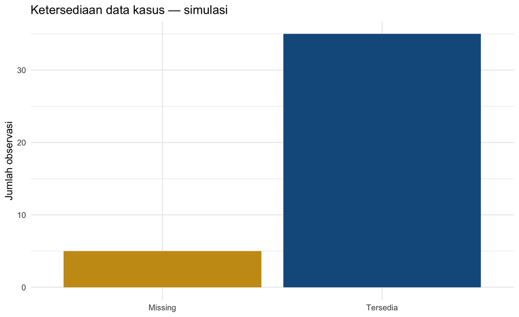

```r
tibble::tibble(
  status = ifelse(is.na(dq$kasus), "Missing", "Tersedia")
) |>
  dplyr::count(status) |>
  ggplot2::ggplot(ggplot2::aes(status, n, fill = status)) +
  ggplot2::geom_col(show.legend = FALSE) +
  ggplot2::scale_fill_manual(values = c("Missing" = "#C99A17", "Tersedia" = "#145B8C")) +
  ggplot2::labs(title = "Ketersediaan data kasus — simulasi", x = NULL, y = "Jumlah observasi")
```

## 2.7 Contoh dengan Data Nyata

Open Data Jawa Barat menyediakan dataset mentah dari perangkat daerah dan BPS, dengan pilihan CSV/Excel/API. Contoh yang relevan adalah TPT kabupaten/kota 2007-2024, jumlah penduduk miskin 2002-2025, dan proyeksi UMKM 2016-2023. Perhatikan bahwa dataset UMKM secara eksplisit berstatus **proyeksi**, sehingga tidak boleh ditafsirkan identik dengan sensus usaha aktual. (Pemerintah Provinsi Jawa Barat 2026b)

**Kartu dataset real.**

- **Nama:** (i) Tingkat Pengangguran Terbuka (TPT) kabupaten/kota Jawa Barat; (ii) Jumlah Penduduk Miskin kabupaten/kota Jawa Barat; (iii) Proyeksi Jumlah UMKM kabupaten/kota Jawa Barat.
- **Sumber dan URL:** Open Data Jawa Barat/BPS untuk TPT https://opendata.jabarprov.go.id/id/dataset/tingkat-pengangguran-terbuka-berdasarkan-kabupatenkota-di-jawa-barat; kemiskinan https://opendata.jabarprov.go.id/id/dataset/jumlah-penduduk-miskin-berdasarkan-kabupatenkota-di-jawa-barat; UMKM https://opendata.jabarprov.go.id/id/dataset/proyeksi-jumlah-usaha-mikro-kecil-menengah-umkm-berdasarkan-kabupatenkota-di-jawa-barat.
- **Tahun:** TPT 2007–2024; kemiskinan 2002–2025; UMKM 2016–2023.
- **Unit observasi:** kabupaten/kota–tahun.
- **Variabel/definisi:** kode/nama provinsi dan kabupaten/kota; `tingkat_pengangguran_terbuka` = persen TPT; `jumlah_penduduk_miskin` = ribu jiwa; `proyeksi_jumlah_umkm` = proyeksi jumlah unit UMKM; `satuan`; `tahun`.
- **Alasan digunakan:** menunjukkan bahwa beberapa open datasets dapat memiliki produsen, periode, unit, dan status angka berbeda sehingga provenance harus dikelola eksplisit.
- **Keterbatasan:** seri tidak memiliki periode identik; nilai UMKM adalah proyeksi; kode wilayah/definisi dapat berubah antarversi. (Pemerintah Provinsi Jawa Barat 2026b)

## 2.8 Analisis Menggunakan R

```r
katalog <- read_csv("data/katalog_data_real.csv", show_col_types = FALSE)
knitr::kable(katalog[, c("dataset","sumber","cakupan_tahun","unit_observasi")],
             caption = "Katalog sumber data nyata untuk mata kuliah")
```

Table 2.3: Katalog sumber data nyata untuk mata kuliah

| dataset | sumber | cakupan_tahun | unit_observasi |
| --- | --- | --- | --- |
| Tingkat Pengangguran Terbuka berdasarkan Kabupaten/Kota di Jawa Barat | Open Data Jawa Barat / BPS | 2007-2024 | Kabupaten/kota-tahun |
| Jumlah Penduduk Miskin berdasarkan Kabupaten/Kota di Jawa Barat | Open Data Jawa Barat / BPS | 2002-2025 | Kabupaten/kota-tahun |
| Proyeksi Jumlah UMKM berdasarkan Kabupaten/Kota di Jawa Barat | Open Data Jawa Barat / Dinas Koperasi dan Usaha Kecil | 2016-2023 | Kabupaten/kota-tahun |
| Jumlah Penduduk berdasarkan Kabupaten/Kota di Jawa Barat | Open Data Jawa Barat / BPS | 2010-2025 | Kabupaten/kota-tahun |
| Indonesia Database for Policy and Economic Research (INDO-DAPOER) | World Bank Data Catalog; sumber indikator terutama BPS dan kementerian/lembaga Indonesia | 1976-2018 | Provinsi/kabupaten/kota-tahun-indikator |
| World Bank Official Boundaries | World Bank Data Catalog | diperbarui berkala | Geometri admin 0/1/2 |

```r
if (dir.exists("data/raw/indodapoer") && length(list.files("data/raw/indodapoer")) > 0) {
  source("R/03_prepare_indodapoer.R")
  indo <- load_indodapoer()
  quality <- indo |>
    dplyr::group_by(kode_indikator, indikator) |>
    dplyr::summarise(
      prop_missing = mean(is.na(nilai)),
      tahun_min = min(tahun[!is.na(nilai)], na.rm = TRUE),
      tahun_max = max(tahun[!is.na(nilai)], na.rm = TRUE),
      .groups = "drop"
    ) |>
    dplyr::arrange(prop_missing) |>
    head(20)
} else {
  demo <- readr::read_csv("data/simulasi_panel_regional.csv", show_col_types = FALSE)
  quality <- tibble::tibble(
    variabel = names(demo),
    prop_missing = purrr::map_dbl(demo, ~mean(is.na(.x))),
    kelas = purrr::map_chr(demo, ~class(.x)[1])
  )
}
knitr::kable(quality, digits = 3, caption = "Output: audit kelengkapan dan struktur data")
```

Table 2.4: Output: audit kelengkapan dan struktur data

| variabel | prop_missing | kelas |
| --- | --- | --- |
| wilayah | 0 | character |
| tahun | 0 | numeric |
| urban | 0 | numeric |
| longitude | 0 | numeric |
| latitude | 0 | numeric |
| pdrb_perkapita_juta | 0 | numeric |
| kemiskinan_persen | 0 | numeric |
| tpt_persen | 0 | numeric |
| ipm | 0 | numeric |
| internet_persen | 0 | numeric |
| umkm_per_1000 | 0 | numeric |
| indeks_pendidikan | 0 | numeric |
| akses_kesehatan | 0 | numeric |
| indeks_inovasi | 0 | numeric |

## 2.9 Interpretasi dalam Konteks Regional

Audit metadata dapat mengubah keputusan analitik. Jika data pengangguran tersedia tahunan tetapi indikator inovasi hanya tersedia pada tahun tertentu, memaksakan model panel tahunan dapat menghasilkan banyak imputasi dan asumsi. Pilihan yang lebih defensible mungkin mengubah unit waktu atau membatasi pertanyaan pada cross-section tertentu.

## 2.10 Latihan

1. Apa perbedaan *data provenance* dan *data quality*?
2. Mengapa angka proyeksi harus diberi label eksplisit dalam dashboard?
3. Sebutkan tiga risiko ketika kode wilayah berubah karena pemekaran.
4. **Analisis:** buat *data inventory* dari minimal tiga dataset Open Data Jabar.
5. **Analisis:** hitung persentase missing per variabel pada data simulasi setelah sengaja menambahkan missing 10%.
6. **Mini-case:** dua dinas melaporkan angka UMKM berbeda. Susun prosedur rekonsiliasi sebelum memilih salah satu sumber.

### 2.10.1 Tugas Terstruktur Pertemuan 2

Buat **data dossier** untuk tiga sumber data calon capstone. Setiap sumber harus memuat producer, URL, access date, periode, unit observasi, definisi variabel, status angka (final/sementara/proyeksi), lisensi, update frequency, missingness yang terlihat, dan risiko integrasi. Pilih satu sumber yang **tidak jadi digunakan** dan jelaskan alasan penolakannya.

### 2.10.2 Kuis Formatif Pertemuan 2

1. Bedakan count, rate, proportion, dan index.
2. Mengapa jumlah penganggur tidak dapat selalu diperoleh dari TPT × total penduduk?
3. Apa perbedaan MCAR, MAR, dan MNAR?
4. Apa yang harus dilakukan bila kode kabupaten berbeda antardataset?
5. Mengapa angka proyeksi harus diberi label eksplisit?

## 2.11 Hubungan dengan Capstone Project

Milestone 2 dimulai di sini: mahasiswa menyiapkan *data dossier* berisi sumber, URL, tanggal akses, definisi variabel, periode, unit observasi, lisensi, dan keterbatasan.

## 2.12 Kesimpulan

Model yang canggih tidak dapat memperbaiki provenance yang tidak jelas. Metadata, denominator, definisi indikator, dan perubahan metodologi adalah bagian inti dari validitas analisis regional.

## 2.13 Pendalaman Magister — Data governance, provenance, dan measurement

### 2.13.1 Audit metodologis

1. Denominator tidak sesuai definisi indikator.
2. Seri historis digabung tanpa cek perubahan metodologi.
3. Proyeksi dianggap observasi aktual.
4. Missingness sistematis diabaikan.
5. Kode wilayah beda versi.
6. Lisensi dan tanggal akses tidak dicatat.

### 2.13.2 Pertanyaan viva / diskusi kelas

1. Apa unit pengukuran vs unit observasi?
2. Mengapa rate tidak boleh dirata-ratakan sembarang?
3. Bagaimana mendeteksi missingness yang berpola?
4. Apa tindakan bila kode wilayah berubah?
5. Bagaimana membedakan revision data dan data error?
6. Mengapa provenance bagian metode ilmiah?

# 3 Data Wrangling, Data Quality, dan Feature Construction

## 3.1 Pendahuluan

Data kebijakan hampir selalu memerlukan penataan: nama wilayah tidak konsisten, angka tersimpan sebagai teks, struktur wide/long bercampur, dan indikator harus dinormalisasi. Bab ini memperlakukan *data wrangling* sebagai proses analitik yang terdokumentasi.

## 3.2 Tujuan Pembelajaran

Mahasiswa mampu melakukan import, tipe data, reshape, join, deduplikasi, penanganan missing, deteksi outlier, serta konstruksi indikator yang sesuai unit dan denominator.

## 3.3 Definisi dan Konsep

Data **tidy** memiliki satu variabel per kolom, satu observasi per baris, dan satu jenis unit observasi per tabel. (Wickham, Çetinkaya-Rundel, dan Grolemund 2023) Kunci join harus mencerminkan identitas observasi; untuk panel kabupaten/kota biasanya kombinasi `kode_wilayah + tahun`, bukan hanya nama wilayah.

Feature construction harus mempunyai makna substantif. `UMKM per 1.000 penduduk` sering lebih dapat dibandingkan antardaerah daripada jumlah UMKM mentah. Transformasi log dapat mengurangi skewness pada nilai ekonomi yang sangat lebar, tetapi interpretasinya berubah.

## 3.4 Formulasi Matematis

Standardisasi z-score:

$$z_{ij}=\frac{x_{ij}-\bar x_j}{s_j},$$

dengan $\bar x_j$ mean dan $s_j$ simpangan baku variabel $j$. Transformasi log yang sering digunakan:

$$x^{*}=\log(1+x),$$

terutama bila $x\ge0$ dan distribusi sangat skewed. Penambahan 1 mencegah masalah $\log(0)$, tetapi harus dinyatakan secara eksplisit.

### 3.4.1 Prinsip tidy data dan transformasi yang dapat dilacak

Dalam *tidy data*, setiap variabel berada pada kolom, setiap observasi pada baris, dan setiap jenis unit observasi pada tabel tersendiri. Struktur ini mengurangi ambiguitas saat agregasi dan pemodelan. (Wickham 2014; Wickham, Çetinkaya-Rundel, dan Grolemund 2023)

Jika $x_i$ adalah nilai mentah, transformasi log sering dipakai untuk distribusi sangat menceng:
$$x_i^{*}=\log(x_i+c),$$
dengan $c>0$ ketika nol mungkin muncul. Perubahan unit harus dinyatakan: koefisien pada skala log tidak identik dengan koefisien skala asli.

### 3.4.2 Standardisasi dan robust scaling

Z-score:
$$z_i=\frac{x_i-\bar x}{s}.$$

Robust z-score berbasis median dan MAD:
$$z_i^{rob}=\frac{x_i-\operatorname{median}(x)}{1.4826\operatorname{MAD}(x)},$$

di mana
$$\operatorname{MAD}(x)=\operatorname{median}_i\{|x_i-\operatorname{median}(x)|\}.$$

Konstanta 1,4826 membuat MAD mendekati simpangan baku untuk data normal. Robust scaling berguna ketika terdapat outlier yang valid secara substantif—misalnya kota metropolitan memang ekstrem dibanding kabupaten rural—dan kita tidak ingin ekstrem tersebut otomatis dianggap kesalahan.

### 3.4.3 Deteksi outlier: rule bukan vonis

IQR:
$$\operatorname{IQR}=Q_{0.75}-Q_{0.25}.$$

Aturan boxplot menandai observasi potensial di luar
$$[Q_{0.25}-1.5\operatorname{IQR},\;Q_{0.75}+1.5\operatorname{IQR}].$$

Outlier tidak boleh langsung dihapus. Klasifikasikan: (a) data entry error, (b) definisi unit berbeda, (c) kejadian ekstrem nyata, atau (d) perubahan metodologi. Dalam data regional, ekstrem yang nyata sering justru menjadi objek analisis.

### 3.4.4 Feature engineering untuk regional analytics

Beberapa fitur yang sering lebih bermakna daripada count mentah:

**Per kapita**
$$x_i^{pc}=\frac{x_i}{N_i}\times k.$$

**Density**
$$d_i=\frac{N_i}{A_i},$$
dengan $A_i$ luas wilayah.

**Share**
$$s_{ik}=\frac{x_{ik}}{\sum_k x_{ik}}.$$

**Lag temporal**
$$x_{i,t-1}=L(x_{it}).$$

**Growth**
$$g_{it}=\frac{x_{it}-x_{i,t-1}}{x_{i,t-1}}.$$

**Difference**
$$\Delta x_{it}=x_{it}-x_{i,t-1}.$$

**Location quotient (LQ)** untuk konsentrasi sektor $k$ di wilayah $i$:
$$LQ_{ik}=\frac{x_{ik}/\sum_k x_{ik}}{\sum_i x_{ik}/\sum_i\sum_k x_{ik}}.$$
$LQ>1$ menunjukkan konsentrasi relatif di atas rata-rata wilayah pembanding. Interpretasi bergantung pada definisi variabel—tenaga kerja, output, atau unit usaha.

### 3.4.5 Transformasi sebelum split dapat menyebabkan leakage

Jika parameter preprocessing (mean, SD, imputation value, PCA loading) dihitung dari seluruh data sebelum train/test split, informasi test set bocor ke proses training. Secara benar, parameter transformasi $\widehat\theta$ harus dihitung hanya dari training:
$$\widehat\theta=g(\mathcal{D}_{train}),\qquad
\widetilde X_{test}=T(X_{test};\widehat\theta).$$

Framework `recipes` pada `tidymodels` membantu menerapkan prinsip ini secara sistematis. (Kuhn dan Silge 2022)

## 3.5 Intuisi Metode

Jika Kabupaten A memiliki 200 ribu UMKM dan Kabupaten B 80 ribu UMKM, belum tentu A lebih “entrepreneurial”. Setelah dibagi populasi usia kerja, ranking dapat berubah. Feature engineering yang baik mengubah data menjadi ukuran yang lebih dekat dengan konsep kebijakan.

### 3.5.1 Worked Example — growth dan division by zero

Jika UMKM suatu wilayah meningkat dari 10.000 menjadi 11.500 unit,
$$g=\frac{11{,}500-10{,}000}{10{,}000}=0.15=15\%.$$
Jika baseline $x_{t-1}=0$, growth rate tidak terdefinisi. Jangan mengganti denominator nol dengan angka kecil tanpa justifikasi karena dapat menciptakan pertumbuhan ekstrem artifisial. Gunakan perubahan absolut atau definisi alternatif.

### 3.5.2 Worked Example — Location Quotient

Wilayah A memiliki 20.000 pekerja manufaktur dari total 100.000 pekerja; provinsi memiliki 300.000 pekerja manufaktur dari 3.000.000 pekerja.
$$LQ_A=\frac{20{,}000/100{,}000}{300{,}000/3{,}000{,}000}=\frac{0.20}{0.10}=2.$$
Artinya konsentrasi tenaga kerja manufaktur dua kali share provinsi. **Bukan berarti produktivitas dua kali lebih tinggi**, dan bukan bukti sektor tersebut “lebih baik”.

### 3.5.3 Join audit

Jika tabel A memiliki 27 kabupaten/kota × 10 tahun = 270 key dan tabel B setelah join hanya match 258 key:
$$M=258/270=95.56\%.$$
12 key yang tidak match harus diperiksa. Contoh R:

```r
a <- tibble(wilayah=c("A","B","C"), tahun=2024, x=1:3)
b <- tibble(wilayah=c("A","B","D"), tahun=2024, y=11:13)
anti_join(a,b,by=c("wilayah","tahun"))
```

```
#> # A tibble: 1 × 3
#>   wilayah tahun     x
#>   <chr>   <dbl> <int>
#> 1 C        2024     3
```

```r
anti_join(b,a,by=c("wilayah","tahun"))
```

```
#> # A tibble: 1 × 3
#>   wilayah tahun     y
#>   <chr>   <dbl> <int>
#> 1 D        2024    13
```

`anti_join()` sering lebih penting daripada `left_join()` karena mengungkap observasi yang hilang akibat perbedaan key.

### 3.5.4 Outlier decision log

Gunakan kategori keputusan berikut:

| Temuan | Diagnosis | Tindakan |
| --- | --- | --- |
| nilai negatif pada jumlah penduduk | impossible | cek source/parse; jangan imputasi diam-diam |
| PDRB per kapita sangat tinggi | plausible structural extreme | pertahankan; pertimbangkan log/robust scaling |
| TPT 850 | kemungkinan decimal/unit error | cek metadata/satuan |
| lon/lat di luar Indonesia | coordinate error | koreksi dari sumber atau exclude terdocumentasi |

### 3.5.5 Leakage-safe recipe

```r
set.seed(260813)
dat <- readr::read_csv("data/simulasi_panel_regional.csv", show_col_types = FALSE) |>
  dplyr::filter(tahun == 2025) |>
  dplyr::select(kemiskinan_persen, pdrb_perkapita_juta, internet_persen, tpt_persen, ipm)
split <- initial_split(dat, prop = .8, strata = kemiskinan_persen)
train <- training(split); test <- testing(split)
rec <- recipe(kemiskinan_persen ~ ., data = train) |>
  step_impute_median(all_numeric_predictors()) |>
  step_zv(all_predictors()) |>
  step_normalize(all_numeric_predictors())
prep_rec <- prep(rec, training = train)
train_baked <- bake(prep_rec, new_data = NULL)
test_baked  <- bake(prep_rec, new_data = test)
knitr::kable(head(train_baked, 6), digits = 3, caption = "Output: data training setelah preprocessing leakage-safe")
```

Table 3.1: Output: data training setelah preprocessing leakage-safe

| pdrb_perkapita_juta | internet_persen | tpt_persen | ipm | kemiskinan_persen |
| --- | --- | --- | --- | --- |
| -1.476 | -0.628 | -0.719 | -0.328 | 9.992 |
| 0.459 | 0.524 | 1.979 | 0.718 | 6.006 |
| 0.643 | 0.396 | -0.477 | -0.561 | 8.570 |
| -0.070 | 0.398 | 0.303 | 0.000 | 10.076 |
| -0.391 | 0.275 | -0.596 | -0.468 | 11.637 |
| -0.546 | -1.018 | -0.758 | -0.899 | 8.979 |

Mean/median dan SD dipelajari dari training. Inilah alasan workflow modeling sebaiknya menyatukan preprocessing dan model. (Kuhn dan Silge 2022)

### 3.5.6 Checklist feature engineering

Setiap fitur baru harus memiliki: formula; denominator; unit; temporal alignment; rationale; potential leakage; dan interpretasi. Fitur `growth_2024` tidak boleh digunakan untuk memprediksi outcome 2023; fitur “jumlah penerima program” dapat menjadi post-treatment variable bila digunakan untuk menjelaskan outcome setelah program.

## 3.6 Contoh dengan Data Simulasi

```r
set.seed(260803)
raw <- tibble(
  kab_kota = c("Kab. A", "kab a ", "KOTA B", "Kota C"),
  tahun = c("2024", "2024", "2024", "2024"),
  penduduk = c("1,200,000", "1,200,000", "850,000", NA),
  umkm = c(85000, 85000, 62000, 21000)
)

clean <- raw |>
  clean_names() |>
  mutate(
    kab_kota = str_to_title(str_squish(kab_kota)),
    tahun = as.integer(tahun),
    penduduk = parse_number(penduduk),
    umkm_per_1000 = umkm/penduduk*1000
  ) |>
  distinct(kab_kota, tahun, .keep_all = TRUE)
knitr::kable(clean, digits = 2, caption = "Contoh cleaning dan konstruksi rate")
```

Table 3.2: Contoh cleaning dan konstruksi rate

| kab_kota | tahun | penduduk | umkm | umkm_per_1000 |
| --- | --- | --- | --- | --- |
| Kab. A | 2024 | 1200000 | 85000 | 70.83 |
| Kab A | 2024 | 1200000 | 85000 | 70.83 |
| Kota B | 2024 | 850000 | 62000 | 72.94 |
| Kota C | 2024 | NA | 21000 | NA |

## 3.7 Contoh dengan Data Nyata

Dataset TPT Open Data Jawa Barat memuat kode provinsi, nama provinsi, kode kabupaten/kota, nama kabupaten/kota, TPT (%), satuan, dan tahun. Kode wilayah sebaiknya dijadikan kunci utama saat menggabungkannya dengan data penduduk atau kemiskinan. Periksa apakah standar kode wilayah konsisten antarversi dataset. (Pemerintah Provinsi Jawa Barat 2026b)

**Kartu dataset real.**

- **Nama:** Tingkat Pengangguran Terbuka Berdasarkan Kabupaten/Kota di Jawa Barat.
- **Sumber dan URL:** Open Data Jawa Barat; produsen BPS, https://opendata.jabarprov.go.id/id/dataset/tingkat-pengangguran-terbuka-berdasarkan-kabupatenkota-di-jawa-barat.
- **Tahun:** 2007–2024; periode tahunan.
- **Unit observasi:** kabupaten/kota–tahun.
- **Variabel/definisi:** `kode_provinsi`, `nama_provinsi`, `kode_kabupaten_kota`, `nama_kabupaten_kota`, `tingkat_pengangguran_terbuka` = persentase TPT, `satuan` = persen, `tahun`.
- **Alasan digunakan:** struktur long/panel sederhana ideal untuk latihan type conversion, key checking, join, dan harmonisasi data regional.
- **Keterbatasan:** seri ini memberikan persentase, bukan jumlah penganggur; validasi kode wilayah diperlukan ketika digabung dengan dataset lain. (Pemerintah Provinsi Jawa Barat 2026b)

## 3.8 Analisis Menggunakan R

```r
panel <- read_csv("data/simulasi_panel_regional.csv", show_col_types = FALSE)

panel_2025 <- panel |>
  filter(tahun == 2025) |>
  mutate(
    pdrb_log = log1p(pdrb_perkapita_juta),
    kemiskinan_z = as.numeric(scale(kemiskinan_persen))
  )

panel_2025 |>
  select(wilayah, pdrb_perkapita_juta, pdrb_log, kemiskinan_persen, kemiskinan_z) |>
  head() |>
  knitr::kable(digits = 3)
```

| wilayah | pdrb_perkapita_juta | pdrb_log | kemiskinan_persen | kemiskinan_z |
| --- | --- | --- | --- | --- |
| Wilayah_01 | 31.612 | 3.485 | 9.992 | 0.061 |
| Wilayah_02 | 65.249 | 4.193 | 7.681 | -1.257 |
| Wilayah_03 | 52.521 | 3.980 | 6.006 | -2.212 |
| Wilayah_04 | 54.513 | 4.017 | 8.570 | -0.750 |
| Wilayah_05 | 46.803 | 3.867 | 10.076 | 0.109 |
| Wilayah_06 | 43.338 | 3.792 | 11.637 | 0.999 |

### 3.8.1 Visualisasi Output: Dampak Transformasi

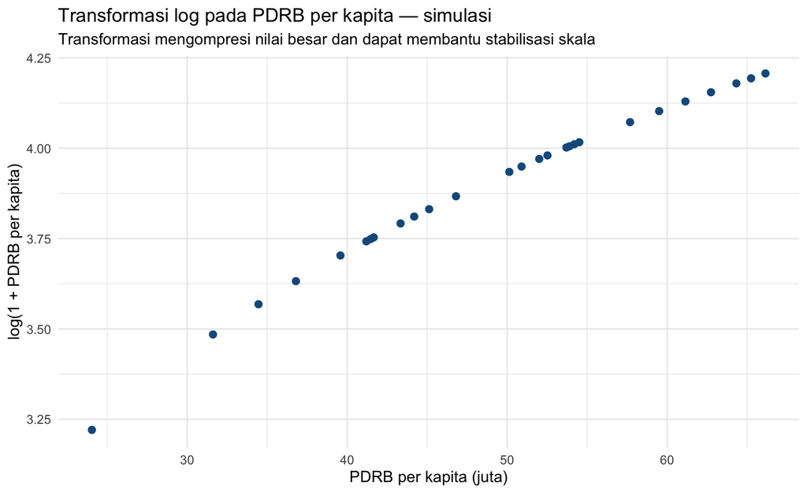

```r
panel_2025 |>
  ggplot2::ggplot(ggplot2::aes(pdrb_perkapita_juta, pdrb_log)) +
  ggplot2::geom_point(size = 2.2, colour = "#145B8C") +
  ggplot2::labs(
    title = "Transformasi log pada PDRB per kapita — simulasi",
    subtitle = "Transformasi mengompresi nilai besar dan dapat membantu stabilisasi skala",
    x = "PDRB per kapita (juta)", y = "log(1 + PDRB per kapita)"
  )
```

```r
if (file.exists("data/raw/tpt_jabar.csv") && file.exists("data/raw/penduduk_jabar.csv")) {
  tpt <- readr::read_csv("data/raw/tpt_jabar.csv", show_col_types = FALSE) |> janitor::clean_names()
  penduduk <- readr::read_csv("data/raw/penduduk_jabar.csv", show_col_types = FALSE) |> janitor::clean_names()
  regional <- tpt |>
    dplyr::inner_join(penduduk, by = c("kode_kabupaten_kota", "tahun"), suffix = c("_tpt", "_pop"))
  out <- head(regional, 8)
} else {
  out <- readr::read_csv("data/simulasi_panel_regional.csv", show_col_types = FALSE) |>
    dplyr::select(wilayah, tahun, tpt_persen, pdrb_perkapita_juta, kemiskinan_persen) |>
    head(8)
}
knitr::kable(out, digits = 2, caption = "Output: hasil integrasi data; gunakan data simulasi bila raw data resmi belum tersedia")
```

Table 3.3: Output: hasil integrasi data; gunakan data simulasi bila raw data resmi belum tersedia

| wilayah | tahun | tpt_persen | pdrb_perkapita_juta | kemiskinan_persen |
| --- | --- | --- | --- | --- |
| Wilayah_01 | 2019 | 7.01 | 17.25 | 17.55 |
| Wilayah_01 | 2020 | 9.29 | 18.82 | 16.01 |
| Wilayah_01 | 2021 | 8.16 | 32.33 | 15.19 |
| Wilayah_01 | 2022 | 7.82 | 29.36 | 15.32 |
| Wilayah_01 | 2023 | 7.89 | 23.84 | 15.52 |
| Wilayah_01 | 2024 | 6.99 | 28.46 | 12.75 |
| Wilayah_01 | 2025 | 7.12 | 31.61 | 9.99 |
| Wilayah_02 | 2019 | 9.07 | 44.30 | 13.41 |

## 3.9 Interpretasi dalam Konteks Regional

Cleaning adalah bagian dari argumentasi. Menghapus duplikat tanpa memahami penyebabnya dapat menghapus kategori yang sebenarnya berbeda. Mengimputasi missing dengan mean provinsi dapat meratakan disparitas dan membuat wilayah ekstrem tampak “normal”. Setiap keputusan cleaning perlu log perubahan.

## 3.10 Latihan

1. Mengapa join dengan nama wilayah lebih berisiko daripada kode wilayah?
2. Kapan transformasi log berguna dan apa konsekuensi interpretasinya?
3. Bedakan outlier karena error dengan outlier yang merupakan fenomena kebijakan penting.
4. **Analisis:** buat pipeline cleaning untuk `simulasi_panel_regional.csv` dan tambahkan unit pada nama variabel.
5. **Analisis:** buat tabel audit duplikasi dan missing per tahun.
6. **Mini-case:** satu kabupaten mengalami lonjakan PDRB 5 kali lipat karena perubahan unit dari juta ke ribu. Tunjukkan bagaimana Anda mendeteksi dan memperbaikinya.

### 3.10.1 Tugas 1 — Data Quality & Wrangling (2,5%)

Gunakan dua tabel regional yang memiliki kunci wilayah–tahun. Lakukan: cleaning nama kolom; audit duplicate; audit missing; validasi join; minimal tiga feature engineering (per capita/rate, growth, lag/LQ); dokumentasikan setiap keputusan. Serahkan `.Rmd` dan HTML.

**Rubrik:** audit data 25; correctness transform 25; join validation 20; reproducibility 15; interpretasi 15.

### 3.10.2 Kuis 1 — Minggu 1–3 (2,5%)

Kuis 10–15 soal campuran konsep dan potongan kode. Kisi-kisi: unit analisis; denominator; provenance; tidy data; missingness; scaling; outlier; feature engineering; leakage preprocessing.

## 3.11 Hubungan dengan Capstone Project

Mahasiswa menyerahkan *data cleaning log*: input, transformasi, alasan, jumlah baris sebelum/sesudah, dan isu yang belum terselesaikan.

## 3.12 Kesimpulan

Wrangling bukan kosmetik. Kesalahan unit, denominator, kode wilayah, dan join dapat menghasilkan kesimpulan kebijakan yang salah meskipun model dihitung dengan benar.

## 3.13 Pendalaman Magister — Wrangling sebagai bagian inferensi

### 3.13.1 Audit metodologis

1. Cleaning menghapus observasi valid.
2. Join many-to-many tidak disadari.
3. Feature menggunakan informasi masa depan.
4. Outlier dihapus karena ekstrem.
5. Growth dihitung dari denominator nol.
6. Transformasi tidak disimpan dalam script.

### 3.13.2 Pertanyaan viva / diskusi kelas

1. Apa konsekuensi many-to-many join?
2. Kapan robust scaling lebih tepat?
3. Bagaimana membedakan data error dan structural extreme?
4. Apa risiko feature engineering pasca-outcome?
5. Mengapa anti_join wajib saat integrasi?
6. Bagaimana membangun cleaning log?

# 4 Exploratory Data Analysis dan Statistika Deskriptif Regional

## 4.1 Pendahuluan

EDA adalah proses menguji struktur data sebelum memaksakan model. Untuk data regional, EDA harus melihat distribusi, tren, heterogenitas antardaerah, hubungan antarindikator, missingness, dan kemungkinan struktur spasial/temporal. (Tukey 1977)

## 4.2 Tujuan Pembelajaran

Mahasiswa mampu menyusun ringkasan numerik dan grafis, membandingkan distribusi antarwilayah/waktu, mendeteksi pola nonlinier/outlier, dan merumuskan hipotesis analitik dari EDA.

## 4.3 Definisi dan Konsep

Ukuran pemusatan (mean, median), penyebaran (SD, IQR), quantile, dan korelasi harus dipilih sesuai distribusi dan tujuan. Untuk data skewed, median sering lebih stabil daripada mean. Korelasi Pearson mengukur asosiasi linear, sedangkan Spearman berbasis ranking dan lebih robust terhadap nonnormalitas tertentu.

## 4.4 Formulasi Matematis

Mean dan variance sampel:

$$\bar x=\frac{1}{n}\sum_{i=1}^{n}x_i,\qquad s^2=\frac{1}{n-1}\sum_{i=1}^{n}(x_i-\bar x)^2.$$

Korelasi Pearson:

$$r_{xy}=\frac{\sum_i(x_i-\bar x)(y_i-\bar y)}{\sqrt{\sum_i(x_i-\bar x)^2\sum_i(y_i-\bar y)^2}}.$$

### 4.4.1 Ukuran lokasi dan penyebaran

Rata-rata aritmetik:
$$\bar x=\frac{1}{n}\sum_{i=1}^{n}x_i.$$

Rata-rata tertimbang—misalnya rata-rata provinsi dari rate kabupaten dengan bobot populasi yang relevan:
$$\bar x_w=\frac{\sum_{i=1}^{n}w_i x_i}{\sum_{i=1}^{n}w_i}.$$

Varians sampel dan simpangan baku:
$$s^2=\frac{1}{n-1}\sum_{i=1}^{n}(x_i-\bar x)^2,\qquad s=\sqrt{s^2}.$$

Coefficient of variation:
$$CV=\frac{s}{\bar x}\times100\%,$$
berguna untuk membandingkan dispersi relatif pada variabel dengan skala berbeda ketika mean positif dan bermakna.

### 4.4.2 Covariance dan correlation

$$\operatorname{Cov}(X,Y)=\frac{1}{n-1}\sum_{i=1}^{n}(x_i-\bar x)(y_i-\bar y),$$

$$r_{XY}=\frac{\operatorname{Cov}(X,Y)}{s_Xs_Y}.$$

Pearson correlation mengukur hubungan linear, bukan hubungan kausal. Spearman correlation adalah Pearson correlation pada ranks dan lebih sesuai ketika hubungan monotonic tetapi tidak linear atau ketika robust terhadap skala ordinal dibutuhkan.

### 4.4.3 Ukuran ketimpangan: Gini dan Theil

Untuk nilai non-negatif yang diurutkan $x_{(1)}\le\cdots\le x_{(n)}$, salah satu bentuk koefisien Gini adalah
$$G=\frac{2\sum_{i=1}^{n} i x_{(i)}}{n\sum_{i=1}^{n}x_{(i)}}-\frac{n+1}{n}.$$

$G=0$ menunjukkan kesetaraan sempurna; nilai lebih tinggi menunjukkan konsentrasi lebih besar. Pada indikator regional, jelaskan **apa yang didistribusikan**—pendapatan, PDRB per kapita, kapasitas layanan, atau investasi—karena makna normatifnya berbeda.

Theil $T$ index:
$$T=\frac{1}{n}\sum_{i=1}^{n}\frac{x_i}{\bar x}\ln\left(\frac{x_i}{\bar x}\right).$$

Keunggulan Theil adalah dekomposabilitas antar dan dalam kelompok, bermanfaat saat membedakan ketimpangan antarkawasan metropolitan/nonmetropolitan atau antar koridor pembangunan.

### 4.4.4 Quantile dan robust summaries

Quantile $Q_p$ memenuhi secara konseptual $P(X\le Q_p)=p$. Median adalah $Q_{0.5}$. Untuk distribusi menceng, laporkan median dan IQR selain mean dan SD. Perbedaan mean–median sendiri dapat memberi sinyal konsentrasi ekstrem.

### 4.4.5 EDA sebagai proses iteratif

EDA bukan “membuat banyak grafik”, tetapi siklus
$$\text{Question}\rightarrow \text{Visualization/Summary}\rightarrow \text{Pattern}\rightarrow \text{New Question}.$$

Tukey menekankan EDA sebagai eksplorasi yang membuka struktur data sebelum pemodelan konfirmatori. (Tukey 1977) Untuk konteks regional, minimal bedakan variasi **antarwilayah**, **antarwaktu**, dan **interaksi wilayah–waktu**.

### 4.4.6 Decomposition sederhana panel regional

Untuk indikator $y_{it}$, dekomposisi konseptual
$$y_{it}=\mu+\alpha_i+\gamma_t+e_{it}$$
memisahkan rata-rata umum $\mu$, efek wilayah $\alpha_i$, efek waktu $\gamma_t$, dan residual. Walaupun belum menjadi model panel formal, struktur ini membantu mahasiswa bertanya apakah perbedaan didominasi karakteristik persisten wilayah atau shock waktu bersama.

## 4.5 Intuisi Metode

Dua provinsi dapat memiliki mean kemiskinan sama tetapi distribusi kabupaten sangat berbeda. Salah satu homogen, yang lain memiliki beberapa kantong kemiskinan ekstrem. Kebijakan yang hanya melihat mean provinsi akan kehilangan informasi target.

### 4.5.1 Worked Example — mean vs median pada distribusi regional

Pendapatan per kapita hipotetis lima wilayah: 20, 22, 24, 26, 100. Mean:
$$\bar x=\frac{20+22+24+26+100}{5}=38.4,$$
median = 24. Satu wilayah ekstrem menggeser mean jauh dari mayoritas. Tidak ada statistik yang “lebih benar” secara universal: mean relevan untuk total/expectation; median lebih representatif untuk typical region saat skew tinggi.

### 4.5.2 Worked Example — weighted mean

Jika indikator A=60 dengan populasi 1 juta dan B=80 dengan populasi 100 ribu, mean sederhana 70, tetapi
$$\bar x_w=\frac{60(1{,}000{,}000)+80(100{,}000)}{1{,}100{,}000}=61.82.$$
Pertanyaan substantif menentukan bobot: populasi, rumah tangga, angkatan kerja, atau bobot sampling.

### 4.5.3 Worked Example — Gini kecil

Untuk tiga nilai $x=(10,20,30)$ yang sudah diurutkan:
$$G=\frac{2[1(10)+2(20)+3(30)]}{3(60)}-\frac{4}{3}
=\frac{280}{180}-1.3333=0.2222.$$
Gini sensitif pada keseluruhan distribusi. Jika satu wilayah melonjak menjadi 100, Gini meningkat. Tetapi Gini tidak memberi tahu **wilayah mana** yang tertinggal; selalu kombinasikan dengan distribusi/ranking/peta.

### 4.5.4 Worked Example — Theil dan dekomposisi pemikiran

Theil memberi nol ketika semua $x_i=\bar x$. Karena term $x_i/\bar x\ln(x_i/\bar x)$ bertambah untuk nilai yang menyimpang, indeks meningkat dengan ketimpangan. Kelebihan untuk regional analytics adalah dekomposisi:
$$T=T_{between}+T_{within},$$
sehingga kita dapat bertanya apakah ketimpangan provinsi terutama berasal dari perbedaan antar-kawasan atau variasi di dalam kawasan.

### 4.5.5 EDA matrix

Untuk capstone, minimal isi matriks berikut.

| Perspektif | Pertanyaan | Statistik/grafik |
| --- | --- | --- |
| cross-section | wilayah mana ekstrem? | boxplot, rank, map |
| temporal | membaik/memburuk? | line, growth, slope |
| bivariate | variabel bergerak bersama? | scatter/correlation |
| multivariate | pola gabungan? | pairwise, PCA/cluster kemudian |
| uncertainty | seberapa stabil? | CI, sensitivity, missing analysis |

### 4.5.6 EDA R workflow

```r
panel <- readr::read_csv("data/simulasi_panel_regional.csv", show_col_types=FALSE)
panel_2025 <- panel |> filter(tahun==2025)
panel_2025 |>
  summarise(
    n=n(),
    mean_pov=mean(kemiskinan_persen),
    median_pov=median(kemiskinan_persen),
    sd_pov=sd(kemiskinan_persen),
    iqr_pov=IQR(kemiskinan_persen),
    cv_pov=sd_pov/mean_pov
  ) |> knitr::kable(digits=3)
```

| n | mean_pov | median_pov | sd_pov | iqr_pov | cv_pov |
| --- | --- | --- | --- | --- | --- |
| 27 | 9.886 | 9.837 | 1.753 | 2.329 | 0.177 |

Setelah statistik keluar, tugas mahasiswa bukan membaca angka satu per satu, tetapi menghubungkan: apakah mean–median berbeda? apakah CV besar? apakah outlier valid? apakah tahun 2025 representatif atau shock?

## 4.6 Contoh dengan Data Simulasi

```r
panel <- read_csv("data/simulasi_panel_regional.csv", show_col_types = FALSE)
latest <- panel |> filter(tahun == max(tahun))

latest |>
  summarise(across(c(kemiskinan_persen, tpt_persen, ipm, internet_persen),
                   list(mean = mean, median = median, sd = sd))) |>
  pivot_longer(everything()) |>
  knitr::kable(digits = 2, caption = "Ringkasan indikator regional 2025 (simulasi)")
```

Table 4.1: Ringkasan indikator regional 2025 (simulasi)

| name | value |
| --- | --- |
| kemiskinan_persen_mean | 9.89 |
| kemiskinan_persen_median | 9.84 |
| kemiskinan_persen_sd | 1.75 |
| tpt_persen_mean | 8.07 |
| tpt_persen_median | 7.75 |
| tpt_persen_sd | 1.10 |
| ipm_mean | 70.74 |
| ipm_median | 70.68 |
| ipm_sd | 1.18 |
| internet_persen_mean | 83.44 |
| internet_persen_median | 85.60 |
| internet_persen_sd | 8.19 |

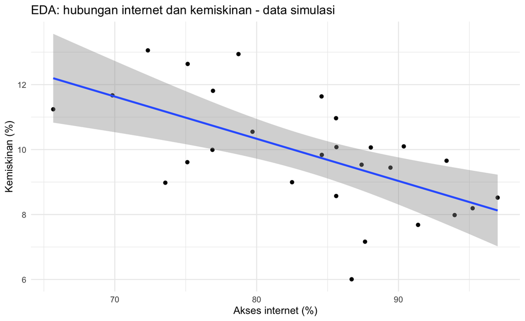

```r
latest |>
  ggplot(aes(internet_persen, kemiskinan_persen)) +
  geom_point() +
  geom_smooth(method = "lm", se = TRUE) +
  labs(x = "Akses internet (%)", y = "Kemiskinan (%)",
       title = "EDA: hubungan internet dan kemiskinan - data simulasi")
```

## 4.7 Contoh dengan Data Nyata

Gunakan Poverty Rate (`SI.POV.NAPR.ZS`), HDI (`IDX.HDI`), populasi (`SP.POP.TOTL`), dan literacy rate (`SE.LITR.15UP.ZS`) dari INDO-DAPOER. Metadata World Bank menyatakan sumber indikator tersebut terutama BPS/SUSENAS. Data historis dapat digunakan untuk mengamati disparitas, tetapi batas periode harus dicantumkan. (World Bank 2026)

**Kartu dataset real.**

- **Nama:** subset indikator sosial-ekonomi INDO-DAPOER.
- **Sumber dan URL:** World Bank Data Catalog, https://datacatalog.worldbank.org/search/dataset/0041056/indonesia-database-for-policy-and-economic-research.
- **Tahun:** maksimum 1976–2018; contoh EDA menggunakan tahun yang memiliki overlap indikator memadai.
- **Unit observasi:** wilayah–tahun setelah indikator di-*pivot* menjadi kolom.
- **Variabel/definisi:** `SI.POV.NAPR.ZS` = poverty rate (%), `IDX.HDI` = HDI, `SP.POP.TOTL` = total population, `SE.LITR.15UP.ZS` = literacy rate usia 15+.
- **Alasan digunakan:** memungkinkan EDA multivariat untuk melihat tren, dispersi, outlier, dan disparitas antardaerah.
- **Keterbatasan:** indikator dapat berasal dari sumber/survei berbeda dan tidak selalu tersedia pada tahun yang sama; analisis harus melaporkan analytic sample. (World Bank 2026)

## 4.8 Analisis Menggunakan R

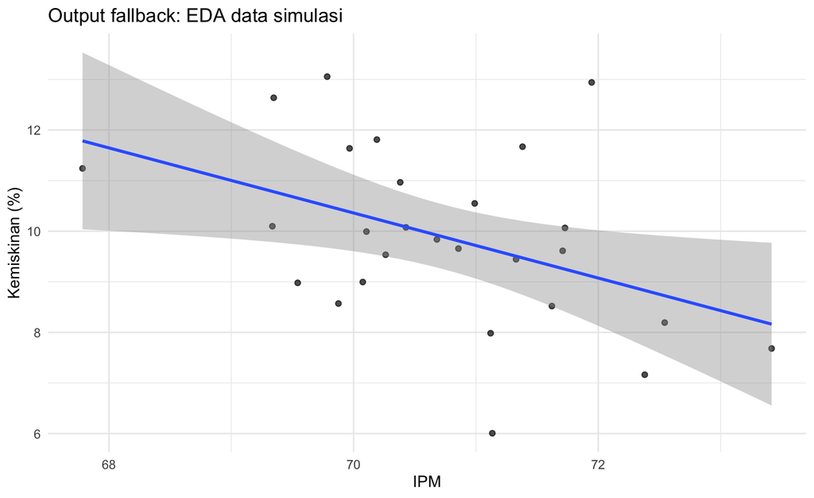

```r
if (dir.exists("data/raw/indodapoer") && length(list.files("data/raw/indodapoer")) > 0) {
  source("R/03_prepare_indodapoer.R")
  indo <- load_indodapoer()
  eda <- indo |>
    dplyr::filter(kode_indikator %in% c("SI.POV.NAPR.ZS", "IDX.HDI"), tahun == 2018) |>
    dplyr::select(wilayah, kode_indikator, nilai) |>
    tidyr::pivot_wider(names_from = kode_indikator, values_from = nilai)
  ggplot2::ggplot(eda, ggplot2::aes(IDX.HDI, SI.POV.NAPR.ZS)) +
    ggplot2::geom_point(alpha = .65) + ggplot2::geom_smooth(method = "lm") +
    ggplot2::labs(x = "HDI", y = "Poverty rate (%)", title = "EDA data INDO-DAPOER 2018")
} else {
  eda <- readr::read_csv("data/simulasi_panel_regional.csv", show_col_types = FALSE) |> dplyr::filter(tahun == 2025)
  ggplot2::ggplot(eda, ggplot2::aes(ipm, kemiskinan_persen)) +
    ggplot2::geom_point(alpha = .7) + ggplot2::geom_smooth(method = "lm") +
    ggplot2::labs(x = "IPM", y = "Kemiskinan (%)", title = "Output fallback: EDA data simulasi")
}
```

## 4.9 Paket Output Analisis Lengkap

```r
eda4 <- readr::read_csv("data/simulasi_panel_regional.csv", show_col_types = FALSE) |>
  dplyr::filter(tahun == 2025)
vars4 <- c("pdrb_perkapita_juta", "kemiskinan_persen", "tpt_persen", "ipm", "internet_persen", "indeks_inovasi")
summary4 <- eda4 |>
  dplyr::summarise(dplyr::across(dplyr::all_of(vars4), list(mean=mean, median=median, sd=sd, min=min, q1=~quantile(.x,.25), q3=~quantile(.x,.75), max=max))) |>
  tidyr::pivot_longer(dplyr::everything(), names_to=c("indikator","stat"), names_pattern="(.*)_(mean|median|sd|min|q1|q3|max)") |>
  tidyr::pivot_wider(names_from=stat, values_from=value)
knitr::kable(summary4, digits=2, caption="Ringkasan lengkap indikator regional tahun 2025")
```

Table 4.2: Ringkasan lengkap indikator regional tahun 2025

| indikator | mean | median | sd | min | q1 | q3 | max |
| --- | --- | --- | --- | --- | --- | --- | --- |
| pdrb_perkapita_juta | 49.22 | 50.90 | 10.86 | 24.04 | 41.56 | 56.10 | 66.15 |
| kemiskinan_persen | 9.89 | 9.84 | 1.75 | 6.01 | 8.77 | 11.10 | 13.05 |
| tpt_persen | 8.07 | 7.75 | 1.10 | 6.69 | 7.19 | 8.72 | 10.35 |
| ipm | 70.74 | 70.68 | 1.18 | 67.78 | 70.02 | 71.50 | 73.42 |
| internet_persen | 83.44 | 85.60 | 8.19 | 65.66 | 76.90 | 88.74 | 96.99 |
| indeks_inovasi | 68.25 | 69.00 | 4.12 | 60.29 | 65.42 | 71.06 | 76.82 |

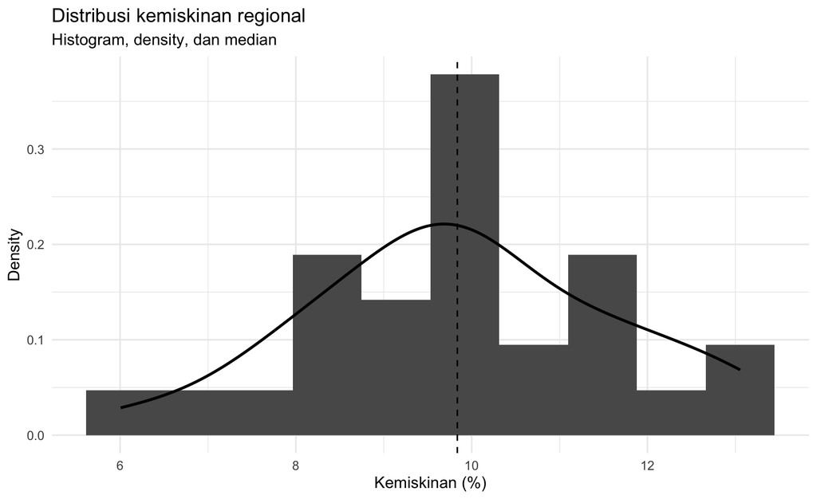

```r
ggplot2::ggplot(eda4, ggplot2::aes(kemiskinan_persen)) +
  ggplot2::geom_histogram(ggplot2::aes(y=ggplot2::after_stat(density)), bins=10) +
  ggplot2::geom_density(linewidth=1) +
  ggplot2::geom_vline(xintercept=median(eda4$kemiskinan_persen), linetype=2) +
  ggplot2::labs(title="Distribusi kemiskinan regional", subtitle="Histogram, density, dan median", x="Kemiskinan (%)", y="Density")
```

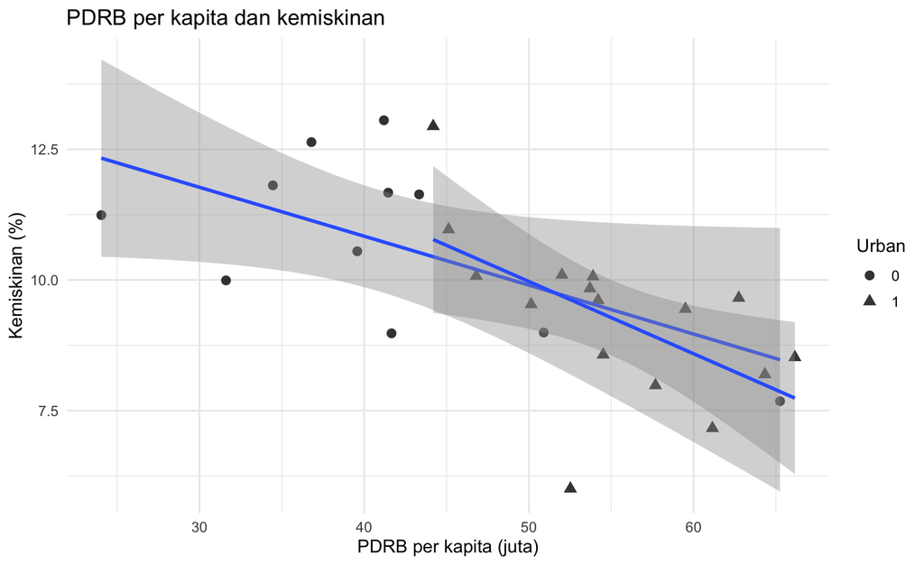

```r
ggplot2::ggplot(eda4, ggplot2::aes(pdrb_perkapita_juta, kemiskinan_persen, shape=factor(urban))) +
  ggplot2::geom_point(size=2.7, alpha=.8) +
  ggplot2::geom_smooth(method="lm", se=TRUE) +
  ggplot2::labs(title="PDRB per kapita dan kemiskinan", x="PDRB per kapita (juta)", y="Kemiskinan (%)", shape="Urban")
```

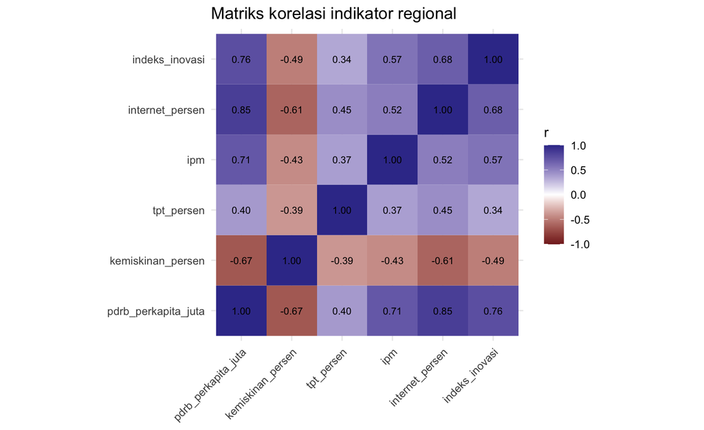

```r
cor4 <- cor(eda4 |> dplyr::select(dplyr::all_of(vars4)), use="pairwise.complete.obs")
cor_long4 <- as.data.frame(as.table(cor4))
ggplot2::ggplot(cor_long4, ggplot2::aes(Var1,Var2,fill=Freq)) +
  ggplot2::geom_tile() + ggplot2::geom_text(ggplot2::aes(label=sprintf("%.2f",Freq)), size=3) +
  ggplot2::scale_fill_gradient2(limits=c(-1,1), midpoint=0) +
  ggplot2::coord_equal() + ggplot2::labs(title="Matriks korelasi indikator regional",x=NULL,y=NULL,fill="r") +
  ggplot2::theme(axis.text.x=ggplot2::element_text(angle=45,hjust=1))
```

## 4.10 Interpretasi dalam Konteks Regional

Jika hubungan HDI-kemiskinan negatif tetapi terdapat wilayah yang jauh dari pola umum, outlier tersebut justru menarik untuk *case tracing*: apakah ada struktur ekonomi khusus, kualitas layanan, urbanisasi, atau masalah measurement? EDA menghasilkan pertanyaan baru, bukan hanya grafik.

## 4.11 Latihan

1. Kapan median lebih informatif daripada mean?
2. Apa yang tidak dapat disimpulkan dari korelasi tinggi?
3. Mengapa agregasi provinsi dapat menyembunyikan disparitas kabupaten?
4. **Analisis:** buat *small multiples* tren kemiskinan untuk 9 wilayah simulasi.
5. **Analisis:** hitung matriks korelasi dan identifikasi pasangan variabel yang berpotensi multikolinear.
6. **Mini-case:** rata-rata pengangguran turun, tetapi 25% kabupaten justru naik. Bagaimana Anda menyampaikan temuan ini kepada pengambil kebijakan?

### 4.11.1 Tugas Terstruktur Pertemuan 4

Susun *regional disparity profile* untuk satu indikator utama dan minimal dua indikator penjelas. Wajib menyajikan mean/median/SD/IQR, CV atau ukuran ketimpangan, top–bottom regions, trend, serta dua hipotesis substantif yang **belum** diklaim sebagai kausal.

### 4.11.2 Kuis Formatif Pertemuan 4

1. Kapan median lebih informatif daripada mean?
2. Apa arti $G=0$ pada koefisien Gini?
3. Mengapa korelasi pada pooled panel dapat berbeda dari korelasi per tahun?
4. Apa manfaat Theil dibanding satu ukuran dispersi biasa?
5. Bedakan pola antarwilayah dan pola antarwaktu.

## 4.12 Hubungan dengan Capstone Project

Milestone EDA harus menghasilkan 3-5 temuan yang dapat ditindaklanjuti, bukan puluhan grafik tanpa narasi. Setiap grafik perlu menjawab pertanyaan tertentu.

## 4.13 Kesimpulan

EDA adalah mekanisme *quality control* dan pembentuk hipotesis. Untuk konteks regional, selalu lihat distribusi, waktu, dan heterogenitas antarwilayah sebelum membangun model.

## 4.14 Pendalaman Magister — EDA dan ketimpangan regional

### 4.14.1 Audit metodologis

1. Pooled pattern menutupi heterogenitas waktu.
2. Mean menutupi skew/outlier.
3. Korelasi ekologis dianggap individual.
4. Ranking tanpa uncertainty.
5. Ketimpangan disimpulkan dari satu statistic.
6. Multiple comparisons tanpa konteks.

### 4.14.2 Pertanyaan viva / diskusi kelas

1. Mengapa mean dan median dapat memberi cerita berbeda?
2. Apa yang Gini tidak beritahu?
3. Bagaimana Theil membantu dekomposisi?
4. Apa Simpson’s paradox secara intuitif?
5. Bagaimana memisahkan efek wilayah dan waktu secara deskriptif?
6. Kapan weighted mean diperlukan?

# 5 Visualisasi Data dan Data Storytelling untuk Kebijakan

## 5.1 Pendahuluan

Visualisasi kebijakan harus cepat dipahami, tetapi tidak boleh mengorbankan ketepatan. Grafik yang baik mengarahkan perhatian pada pesan substantif sekaligus menyediakan konteks: unit, baseline, skala, denominator, dan ketidakpastian. Grammar of Graphics menyediakan kerangka sistematis untuk memetakan data ke estetika visual. (Wilkinson 2005; Tufte 2001)

## 5.2 Tujuan Pembelajaran

Mahasiswa mampu memilih bentuk grafik sesuai pertanyaan, menghindari visual yang menyesatkan, membangun *data story*, dan merancang prototipe dashboard regional.

## 5.3 Definisi dan Konsep

Data storytelling menggabungkan **evidence**, **narrative**, dan **visual design**. Narasi kebijakan umumnya mengikuti: konteks → gap/disparitas → siapa/di mana → faktor terkait → implikasi → opsi tindakan. Dashboard berbeda dari laporan: dashboard membantu monitoring/eksplorasi, sedangkan laporan dapat memuat argumentasi lebih panjang.

## 5.4 Formulasi Matematis

Perubahan absolut dan relatif:

$$\Delta x=x_t-x_{t-1}, \qquad g=\frac{x_t-x_{t-1}}{x_{t-1}}\times100\%.$$

Keduanya dapat menghasilkan pesan berbeda. Kenaikan 2 poin persentase dari 4% ke 6% adalah +2 pp tetapi +50% secara relatif.

### 5.4.1 Transformasi visual sebagai transformasi analitik

Jika grafik menggunakan log scale, hubungan visual berubah. Untuk $x>0$,
$$x^{*}=\log(x).$$
Perbedaan pada skala log berhubungan dengan rasio pada skala asli:
$$\log x_2-\log x_1=\log\left(\frac{x_2}{x_1}\right).$$
Karena itu, setiap transformasi sumbu harus disebutkan dan dipahami, bukan dianggap dekorasi.

### 5.4.2 Rates, indexes, dan baseline

Indeks dengan tahun dasar $0$:
$$I_t=\frac{x_t}{x_0}\times100.$$
Nilai $I_t=125$ berarti 25% di atas level tahun dasar, bukan “naik 125%”. Untuk membandingkan trajectory kabupaten dengan skala absolut sangat berbeda, indeks dapat lebih informatif daripada plot count.

### 5.4.3 Slope dan annualized change

Untuk dua titik waktu,
$$\text{slope}=\frac{y_{t_2}-y_{t_1}}{t_2-t_1}.$$
Jika model tren linear $y_t=\beta_0+\beta_1t+\varepsilon_t$, maka $\beta_1$ adalah perubahan rata-rata per unit waktu, dengan asumsi tren linear memadai.

### 5.4.4 Encoding visual dan risiko distorsi

Dalam *Grammar of Graphics*, grafik adalah pemetaan data ke aesthetics—position, length, color, shape, size—plus geometric objects dan coordinate system. (Wilkinson 2005) Untuk perbandingan presisi, posisi pada skala bersama umumnya lebih mudah dibaca dibanding area/volume. Karena itu bubble chart yang menarik secara visual belum tentu tepat untuk membandingkan perbedaan kecil.

Untuk choropleth, klasifikasi nilai dapat menggunakan quantile. Jika $K$ kelas, batas kuantil adalah $Q_{k/K}$. Namun klasifikasi quantile membuat tiap kelas berisi jumlah wilayah relatif sama dan dapat menyembunyikan gap substantif; *equal interval* dan *natural breaks* memberi pesan berbeda. Metode klasifikasi wajib dilaporkan.

### 5.4.5 Uncertainty dalam visualisasi

Jika estimasi $\hat\theta$ memiliki standard error $SE(\hat\theta)$, interval aproksimasi 95% adalah
$$\hat\theta\pm 1.96\,SE(\hat\theta),$$
untuk kondisi asimtotik yang memadai. Menampilkan ribbon/interval membantu mencegah pembaca memperlakukan estimasi sebagai angka pasti.

### 5.4.6 Data storytelling untuk kebijakan

Satu *evidence story* yang kuat memiliki struktur:

$$\text{Claim} + \text{Evidence} + \text{Context} + \text{Uncertainty} + \text{Decision implication}.$$

“Pengangguran turun” adalah claim; grafik trend adalah evidence; perubahan definisi atau shock pandemi adalah context; interval atau sensitivitas adalah uncertainty; implikasi target program adalah decision implication. Visualisasi yang indah tanpa lima komponen ini berisiko menjadi poster, bukan alat kebijakan. (Tufte 2001)

## 5.5 Intuisi Metode

Grafik bar cocok untuk membandingkan kategori; line chart untuk tren waktu; scatterplot untuk hubungan; peta untuk pola geografis. Peta bukan default untuk semua indikator regional. Jika tujuan hanya ranking 27 kabupaten, sorted dot plot sering lebih mudah dibaca daripada choropleth.

### 5.5.1 Worked Example — indeks tahun dasar

Jika TPT wilayah A adalah 10% pada 2020 dan 7% pada 2024, indeks basis 2020:
$$I_{2024}=\frac{7}{10}\times100=70.$$
Artinya level 2024 adalah 70% dari level 2020 atau turun 30% relatif terhadap baseline. Jangan menulis “TPT menjadi 70%” tanpa menyebut bahwa 70 adalah **indeks**, bukan rate aktual.

### 5.5.2 Worked Example — slope vs percent change

Dari 10% menjadi 7% selama 4 tahun:
$$\text{slope}=\frac{7-10}{4}=-0.75\text{ percentage point/year}.$$
Perubahan relatif:
$$\frac{7-10}{10}=-30\%.$$
“Turun 3 percentage points” berbeda dari “turun 30 persen”. Bahasa kebijakan harus membedakan percentage point dan percent change.

### 5.5.3 Visual encoding audit

Sebelum menggunakan grafik, cek:

- **position/length** untuk perbandingan presisi;
- **color hue** untuk kategori;
- **color luminance** untuk ordered values;
- **area** hanya jika pembaca tidak perlu membandingkan nilai kecil dengan presisi;
- **shape** untuk sedikit kategori;
- **animation** hanya jika dinamika waktu tidak lebih jelas dengan small multiples.

Peta sebaiknya tidak digunakan hanya karena data memiliki nama wilayah. Jika pertanyaan adalah tren 20 tahun, line chart sering lebih efektif; peta membantu ketika spatial pattern substantif.

### 5.5.4 Worked R story

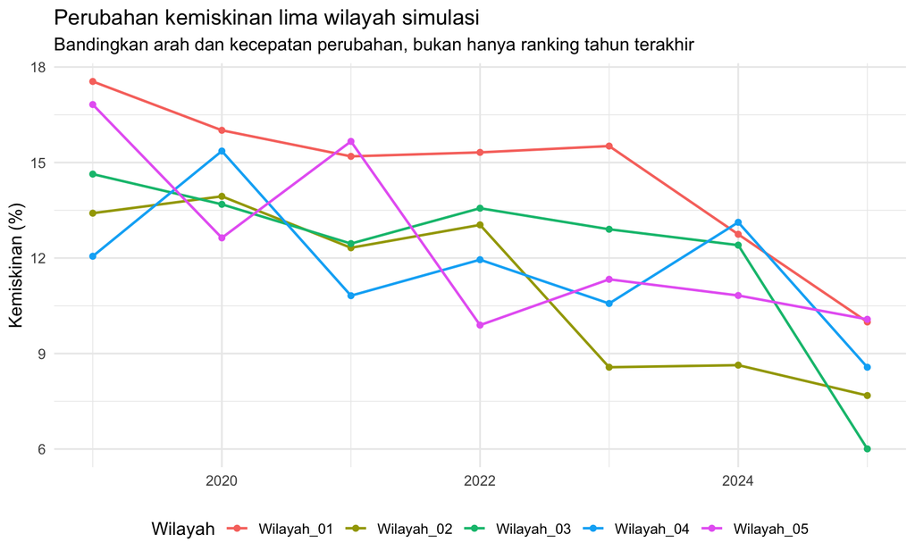

```r
sel <- panel |> filter(wilayah %in% unique(wilayah)[1:5])
ggplot(sel, aes(tahun, kemiskinan_persen, group=wilayah, color=wilayah)) +
  geom_line(linewidth=.8) + geom_point(size=1.5) +
  labs(title="Perubahan kemiskinan lima wilayah simulasi",
       subtitle="Bandingkan arah dan kecepatan perubahan, bukan hanya ranking tahun terakhir",
       x=NULL, y="Kemiskinan (%)", color="Wilayah") +
  theme(legend.position="bottom")
```

Setelah grafik, tulis tiga jenis kalimat: **pattern** (“semua turun tetapi kecepatannya berbeda”), **exception** (“wilayah X stagnan”), dan **implication** (“intervensi seragam mungkin kurang tepat”).

### 5.5.5 Checklist caption yang kuat

Caption seharusnya menjawab: apa yang diukur; unit; periode; denominator; sumber; dan caveat. Contoh: “TPT kabupaten/kota Jawa Barat, persen angkatan kerja, 2007–2024; sumber BPS melalui Open Data Jawa Barat. Perubahan seri perlu dibaca bersama metadata dan kondisi pasar kerja.” (Badan Pusat Statistik dan Pemerintah Provinsi Jawa Barat 2026d)

### 5.5.6 Anti-pattern visualisasi

1. Sumbu dipotong untuk bar chart sehingga perbedaan tampak dramatis.
2. Warna diverging tanpa titik tengah bermakna.
3. Menggunakan 27 warna kategori pada satu grafik.
4. Dual axis tanpa hubungan transformasi eksplisit.
5. Choropleth count tanpa standardisasi populasi ketika tujuan membandingkan risiko.
6. Peta dengan kelas quantile tetapi narasi seolah kelas merepresentasikan threshold substantif.

## 5.6 Contoh dengan Data Simulasi

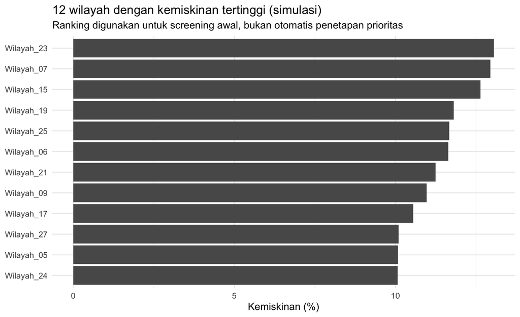

```r
latest <- read_csv("data/simulasi_panel_regional.csv", show_col_types = FALSE) |>
  filter(tahun == 2025) |>
  arrange(desc(kemiskinan_persen)) |>
  slice_head(n = 12)

ggplot(latest, aes(x = reorder(wilayah, kemiskinan_persen), y = kemiskinan_persen)) +
  geom_col() +
  coord_flip() +
  labs(x = NULL, y = "Kemiskinan (%)",
       title = "12 wilayah dengan kemiskinan tertinggi (simulasi)",
       subtitle = "Ranking digunakan untuk screening awal, bukan otomatis penetapan prioritas")
```

## 5.7 Contoh dengan Data Nyata

TPT Open Data Jawa Barat memiliki seri tahunan 2007-2024, sehingga cocok untuk visualisasi tren dan perbandingan kabupaten/kota. Dataset menghasilkan persentase TPT, bukan jumlah penganggur; untuk beban absolut perlu sumber jumlah angkatan kerja atau jumlah penganggur. (Pemerintah Provinsi Jawa Barat 2026b)

**Kartu dataset real.**

- **Nama:** Tingkat Pengangguran Terbuka Berdasarkan Kabupaten/Kota di Jawa Barat.
- **Sumber dan URL:** Open Data Jawa Barat/BPS, https://opendata.jabarprov.go.id/id/dataset/tingkat-pengangguran-terbuka-berdasarkan-kabupatenkota-di-jawa-barat.
- **Tahun:** 2007–2024.
- **Unit observasi:** kabupaten/kota–tahun.
- **Variabel/definisi:** identitas wilayah; `tingkat_pengangguran_terbuka` = persentase angkatan kerja yang menganggur menurut definisi statistik produsen; `satuan` = persen; `tahun`.
- **Alasan digunakan:** seri waktu lintas wilayah cocok untuk latihan small multiples, ranking yang bertanggung jawab, dan *storytelling* perubahan.
- **Keterbatasan:** persentase tidak menunjukkan beban absolut; perubahan kecil tidak selalu substantif; narasi harus menyebut tahun dan sumber. (Pemerintah Provinsi Jawa Barat 2026b)

## 5.8 Analisis Menggunakan R

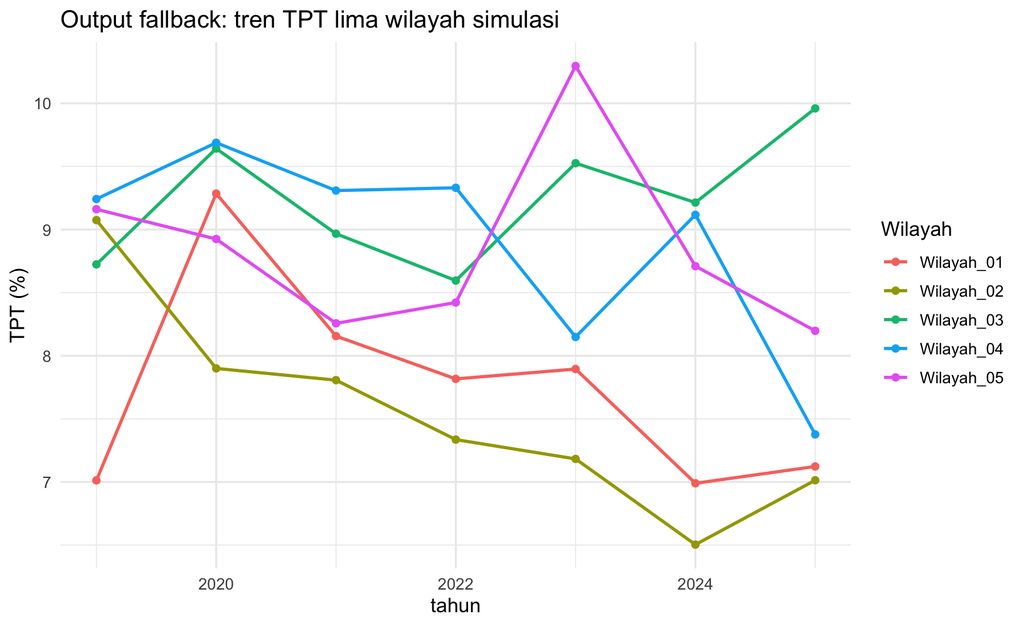

```r
if (file.exists("data/raw/tpt_jabar.csv")) {
  tpt <- readr::read_csv("data/raw/tpt_jabar.csv", show_col_types = FALSE) |> janitor::clean_names()
  dat_plot <- tpt |> dplyr::group_by(nama_kabupaten_kota) |> dplyr::filter(dplyr::n() >= 3) |> dplyr::ungroup() |> dplyr::slice_head(n = 80)
  ggplot2::ggplot(dat_plot, ggplot2::aes(tahun, tingkat_pengangguran_terbuka, group = nama_kabupaten_kota)) +
    ggplot2::geom_line(alpha=.55) + ggplot2::labs(y="TPT (%)", title="Tren TPT — data resmi yang tersedia")
} else {
  dat_plot <- readr::read_csv("data/simulasi_panel_regional.csv", show_col_types = FALSE) |>
    dplyr::filter(wilayah %in% unique(wilayah)[1:5])
  ggplot2::ggplot(dat_plot, ggplot2::aes(tahun, tpt_persen, group=wilayah, color=wilayah)) +
    ggplot2::geom_line(linewidth=.9) + ggplot2::geom_point() +
    ggplot2::labs(y="TPT (%)", title="Output fallback: tren TPT lima wilayah simulasi", color="Wilayah")
}
```

## 5.9 Paket Visual Evidence Lengkap

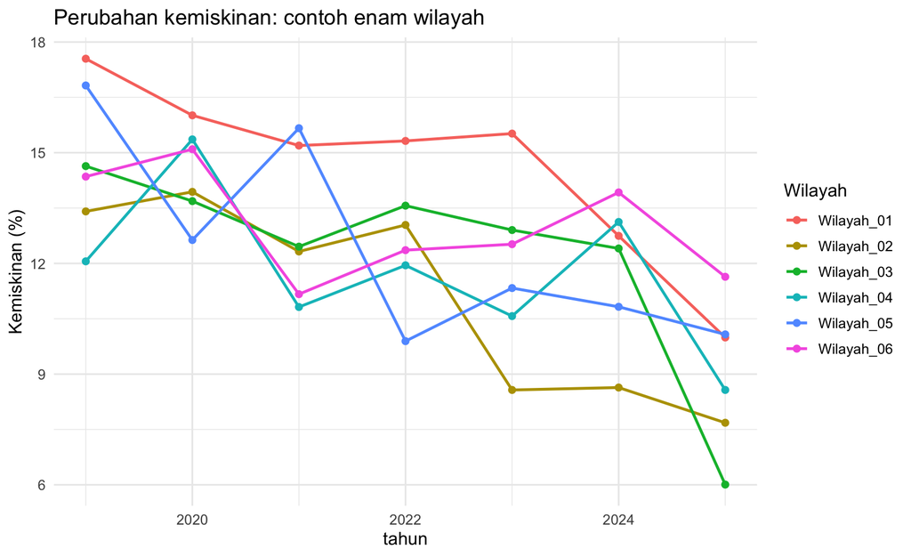

```r
vis5 <- readr::read_csv("data/simulasi_panel_regional.csv", show_col_types = FALSE)
sel5 <- unique(vis5$wilayah)[1:6]
ggplot2::ggplot(vis5 |> dplyr::filter(wilayah %in% sel5), ggplot2::aes(tahun, kemiskinan_persen, group=wilayah, colour=wilayah)) +
  ggplot2::geom_line(linewidth=.9) + ggplot2::geom_point(size=1.8) +
  ggplot2::labs(title="Perubahan kemiskinan: contoh enam wilayah", y="Kemiskinan (%)", colour="Wilayah")
```

```r
rank5 <- vis5 |> dplyr::filter(tahun==max(tahun)) |> dplyr::arrange(dplyr::desc(kemiskinan_persen)) |>
  dplyr::select(wilayah, kemiskinan_persen, tpt_persen, ipm, internet_persen)
knitr::kable(rank5, digits=2, caption="Evidence table untuk mendampingi visual ranking")
```

Table 5.1: Evidence table untuk mendampingi visual ranking

| wilayah | kemiskinan_persen | tpt_persen | ipm | internet_persen |
| --- | --- | --- | --- | --- |
| Wilayah_23 | 13.05 | 7.05 | 69.78 | 72.33 |
| Wilayah_07 | 12.94 | 8.68 | 71.95 | 78.72 |
| Wilayah_15 | 12.64 | 7.56 | 69.35 | 75.14 |
| Wilayah_19 | 11.81 | 7.54 | 70.19 | 76.92 |
| Wilayah_25 | 11.67 | 6.69 | 71.38 | 69.83 |
| Wilayah_06 | 11.64 | 7.25 | 69.97 | 84.58 |
| Wilayah_21 | 11.24 | 6.74 | 67.78 | 65.66 |
| Wilayah_09 | 10.97 | 9.63 | 70.38 | 85.60 |
| Wilayah_17 | 10.55 | 7.31 | 70.99 | 79.71 |
| Wilayah_27 | 10.10 | 7.65 | 69.34 | 90.37 |
| Wilayah_05 | 10.08 | 8.20 | 70.43 | 85.62 |
| Wilayah_24 | 10.06 | 8.67 | 71.73 | 88.05 |
| Wilayah_01 | 9.99 | 7.12 | 70.11 | 76.88 |
| Wilayah_18 | 9.84 | 7.75 | 70.68 | 84.59 |
| Wilayah_20 | 9.66 | 6.79 | 70.86 | 93.39 |
| Wilayah_26 | 9.61 | 9.63 | 71.71 | 75.11 |
| Wilayah_16 | 9.53 | 9.09 | 70.26 | 87.40 |
| Wilayah_22 | 9.44 | 8.76 | 71.33 | 89.43 |
| Wilayah_13 | 8.99 | 7.88 | 70.08 | 82.50 |
| Wilayah_08 | 8.98 | 7.08 | 69.54 | 73.56 |
| Wilayah_04 | 8.57 | 7.38 | 69.88 | 85.61 |
| Wilayah_10 | 8.52 | 8.09 | 71.62 | 96.99 |
| Wilayah_14 | 8.19 | 10.03 | 72.54 | 95.23 |
| Wilayah_12 | 7.98 | 10.35 | 71.12 | 93.96 |
| Wilayah_02 | 7.68 | 7.01 | 73.42 | 91.38 |
| Wilayah_11 | 7.16 | 7.94 | 72.38 | 87.64 |
| Wilayah_03 | 6.01 | 9.96 | 71.13 | 86.70 |

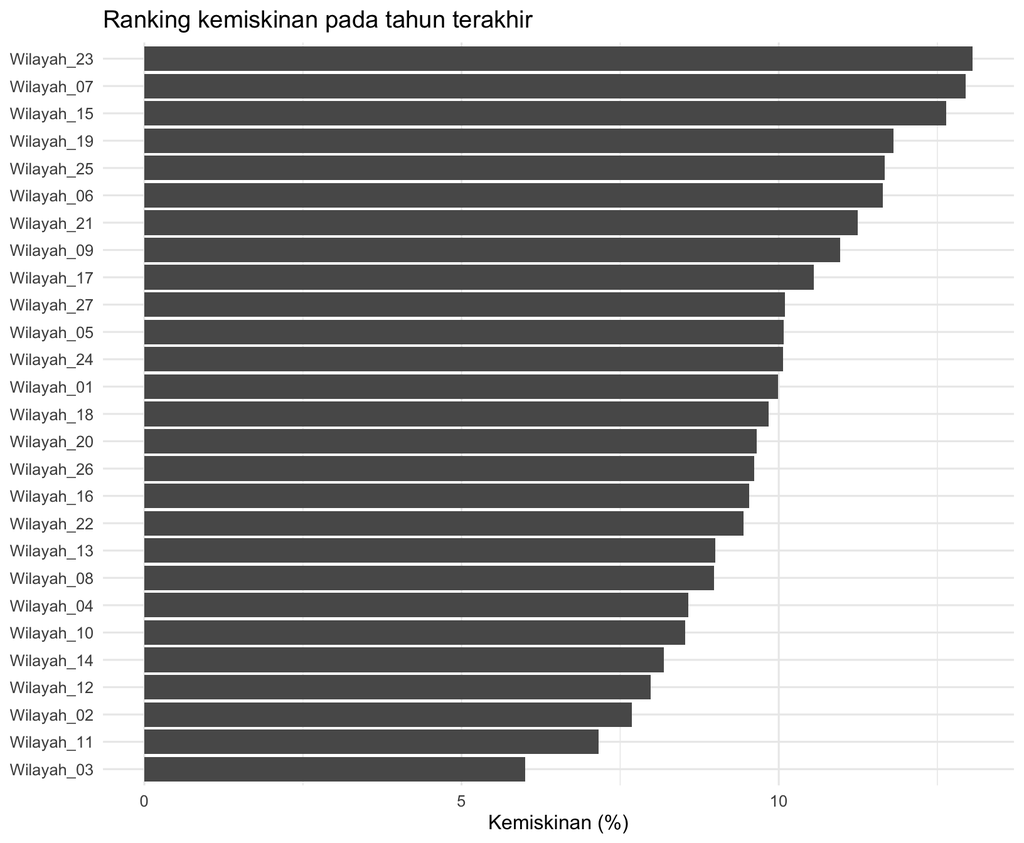

```r
ggplot2::ggplot(rank5, ggplot2::aes(reorder(wilayah, kemiskinan_persen), kemiskinan_persen)) +
  ggplot2::geom_col() + ggplot2::coord_flip() +
  ggplot2::labs(title="Ranking kemiskinan pada tahun terakhir", x=NULL, y="Kemiskinan (%)")
```

## 5.10 Interpretasi dalam Konteks Regional

Visualisasi harus membedakan “nilai tinggi” dan “masalah besar”. Kota kecil dengan TPT tinggi mungkin memiliki jumlah penganggur absolut lebih sedikit daripada kabupaten besar dengan TPT sedang. Dashboard yang baik memungkinkan pembaca melihat **rate dan count** secara berdampingan.

## 5.11 Latihan

1. Mengapa sumbu y yang dipotong dapat menyesatkan pada bar chart?
2. Kapan peta lebih informatif daripada ranking plot?
3. Bedakan perubahan persentase dan poin persentase.
4. **Analisis:** buat tiga jenis grafik untuk indikator yang sama dan evaluasi mana paling komunikatif.
5. **Analisis:** buat visual `before-after` untuk dua tahun pada data simulasi.
6. **Mini-case:** kepala daerah hanya punya 30 detik melihat dashboard. Rancang tiga KPI dan jelaskan alasan pemilihannya.

### 5.11.1 Tugas 2 — Evidence Visualization (2,5%)

Buat satu halaman *policy evidence story* berisi maksimal empat grafik. Setiap grafik harus memiliki: pertanyaan, caption substantif, sumber, unit/satuan, periode, dan satu kalimat caveat. Sertakan satu grafik yang sengaja buruk, kemudian revisi dan jelaskan mengapa versi kedua lebih tepat.

### 5.11.2 Kuis Formatif Pertemuan 5

Fokus: transformasi log; indeks tahun dasar; slope; pilihan visual encoding; masalah dual-axis; choropleth classification; uncertainty; claim–evidence–context–decision implication.

## 5.12 Hubungan dengan Capstone Project

Mahasiswa membuat *storyboard* 5 panel: masalah, disparitas, driver/pola, model/evidence, dan rekomendasi. Ini menjadi kerangka dashboard dan presentasi akhir.

## 5.13 Kesimpulan

Visualisasi kebijakan adalah alat penalaran dan komunikasi. Pilih bentuk grafik berdasarkan pertanyaan, bukan karena efek visualnya menarik.

## 5.14 Pendalaman Magister — Visual evidence dan policy storytelling

### 5.14.1 Audit metodologis

1. Grafik menjawab pertanyaan yang salah.
2. Sumbu/warna memperbesar perbedaan.
3. Count dipetakan tanpa denominator.
4. Peta dipakai saat time trend lebih relevan.
5. Uncertainty dihilangkan.
6. Caption tidak memuat sumber/periode.

### 5.14.2 Pertanyaan viva / diskusi kelas

1. Apa unit pesan satu grafik?
2. Kapan choropleth tidak tepat?
3. Apa beda percent dan percentage point?
4. Bagaimana klasifikasi peta memengaruhi cerita?
5. Mengapa uncertainty perlu divisualisasikan?
6. Apa struktur claim–evidence–context–decision?

# 6 Statistika Inferensial dan Regresi untuk Data Regional

## 6.1 Pendahuluan

Regresi menghubungkan outcome dengan satu atau lebih prediktor dan menyediakan kerangka untuk estimasi, ketidakpastian, dan prediksi. Pada data regional, regresi sangat berguna, tetapi interpretasi harus membedakan **asosiasi** dari **efek kausal**.

## 6.2 Tujuan Pembelajaran

Mahasiswa mampu merumuskan model regresi, menginterpretasi koefisien dan interval kepercayaan, mengecek residual secara dasar, mengenali multikolinearitas, dan menjelaskan keterbatasan inferensi observasional.

## 6.3 Definisi dan Konsep

Model linear berganda menaksir hubungan kondisional: perubahan ekspektasi outcome ketika satu prediktor berubah, dengan prediktor lain ditahan konstan. Asumsi penting meliputi spesifikasi mean yang memadai, independensi/struktur error yang sesuai, serta stabilitas hubungan. Data panel dan spasial sering melanggar independensi sederhana sehingga regresi OLS harus dilihat sebagai baseline, bukan akhir analisis.

## 6.4 Formulasi Matematis

$$y_i=\beta_0+\beta_1x_{i1}+\cdots+\beta_px_{ip}+\varepsilon_i,$$

dengan $y_i$ outcome, $x_{ij}$ prediktor, $\beta_j$ koefisien, dan $\varepsilon_i$ error. Estimator OLS dalam notasi matriks:

$$\hat{\boldsymbol\beta}=(\mathbf X^\top\mathbf X)^{-1}\mathbf X^\top\mathbf y.$$

Interval kepercayaan koefisien secara umum:

$$\hat\beta_j \pm t_{\alpha/2,df}\,SE(\hat\beta_j).$$

### 6.4.1 Estimasi, standard error, dan confidence interval

Misalkan $X_1,\dots,X_n$ i.i.d. dengan mean $\mu$ dan varians $\sigma^2$. Rata-rata sampel
$$\bar X=\frac{1}{n}\sum_{i=1}^nX_i$$
memiliki
$$E(\bar X)=\mu,\qquad \operatorname{Var}(\bar X)=\frac{\sigma^2}{n}.$$
Standard error diestimasi oleh
$$SE(\bar X)=\frac{s}{\sqrt n}.$$
Untuk populasi normal atau sampel yang memadai, CI mean dengan $t$ adalah
$$\bar x\pm t_{1-\alpha/2,n-1}\frac{s}{\sqrt n}.$$
Interpretasi frequentist: prosedur interval tersebut memiliki coverage $1-\alpha$ pada repeated sampling; bukan probabilitas posterior bahwa $\mu$ berada di interval tertentu.

### 6.4.2 Uji hipotesis

Untuk $H_0:\mu=\mu_0$,
$$t=\frac{\bar x-\mu_0}{s/\sqrt n}.$$
$p$-value adalah probabilitas memperoleh statistik uji setidaknya se-ekstrem yang teramati **jika $H_0$ dan asumsi model benar**. $p$-value bukan ukuran besar efek, bukan probabilitas $H_0$ benar, dan bukan pengganti relevansi kebijakan.

### 6.4.3 Regresi linear sederhana dan berganda

Model:
$$y_i=\beta_0+\beta_1x_{i1}+\cdots+\beta_px_{ip}+\varepsilon_i,
\qquad E(\varepsilon_i\mid X)=0.$$
Dalam bentuk matriks:
$$\mathbf y=\mathbf X\boldsymbol\beta+\boldsymbol\varepsilon.$$
OLS memilih
$$\widehat{\boldsymbol\beta}=\arg\min_{\boldsymbol\beta}(\mathbf y-\mathbf X\boldsymbol\beta)'(\mathbf y-\mathbf X\boldsymbol\beta),$$
yang, jika $\mathbf X'\mathbf X$ invertibel, memiliki solusi
$$\widehat{\boldsymbol\beta}=(\mathbf X'\mathbf X)^{-1}\mathbf X'\mathbf y.$$
Residual:
$$e_i=y_i-\hat y_i.$$
Estimator varians error:
$$\hat\sigma^2=\frac{\sum_{i=1}^{n}e_i^2}{n-p-1}.$$
Varian koefisien di bawah homoskedastisitas:
$$\operatorname{Var}(\widehat{\boldsymbol\beta}\mid X)=\sigma^2(\mathbf X'\mathbf X)^{-1}.$$

### 6.4.4 Goodness of fit dan penalti kompleksitas

$$SST=\sum_i(y_i-\bar y)^2,\qquad SSE=\sum_i(y_i-\hat y_i)^2.$$

$$R^2=1-\frac{SSE}{SST}.$$

Adjusted $R^2$:
$$\bar R^2=1-\frac{SSE/(n-p-1)}{SST/(n-1)}.$$
$R^2$ tinggi tidak menjamin model memiliki error prediksi kecil pada data baru atau memiliki interpretasi kausal yang valid. (Harrell 2015)

### 6.4.5 Multikolinearitas dan VIF

Untuk prediktor $X_j$, regresikan $X_j$ terhadap prediktor lain dan peroleh $R_j^2$. Variance Inflation Factor:
$$VIF_j=\frac{1}{1-R_j^2}.$$
VIF menunjukkan inflasi varians koefisien akibat hubungan linear antarfitur; threshold seperti 5 atau 10 hanyalah rule-of-thumb, bukan hukum universal.

### 6.4.6 Interaksi dan nonlinearity

Model interaksi:
$$y=\beta_0+\beta_1x_1+\beta_2x_2+\beta_3x_1x_2+\varepsilon.$$
Efek marginal $x_1$ adalah
$$\frac{\partial E(Y\mid X)}{\partial x_1}=\beta_1+\beta_3x_2.$$
Artinya efek $x_1$ bergantung pada $x_2$. Dalam konteks regional, dampak asosiasional digital connectivity terhadap outcome dapat berbeda menurut tingkat urbanisasi atau kapasitas fiskal.

### 6.4.7 Prediksi bukan klaim kausal

Koefisien OLS bersifat kausal hanya di bawah asumsi identifikasi yang kuat. Jika variabel tak teramati $U$ memengaruhi $X$ dan $Y$, maka asosiasi dapat mengalami confounding. Buku kausal modern menekankan pemisahan pertanyaan prediktif dan kausal. (Hernán dan Robins 2020) Dalam mata kuliah ini, regresi terutama digunakan untuk **deskripsi kondisional dan prediksi**, kecuali desain identifikasi dijelaskan eksplisit.

## 6.5 Intuisi Metode

Koefisien internet -0,05 pada model kemiskinan berarti bahwa, dalam model dan skala yang digunakan, peningkatan 1 poin persentase internet diasosiasikan dengan penurunan rata-rata 0,05 poin kemiskinan ketika variabel lain tetap. Ini bukan bukti efek kausal jika faktor confounding tidak ditangani.

### 6.5.1 Worked Example — interpretasi koefisien

Model hipotetis:
$$\widehat{Poverty}=18-0.08\,Internet-0.04\,PDRBpc+0.30\,TPT.$$
Jika internet diukur persen, koefisien $-0.08$ berarti pada data/model tersebut, kenaikan 1 percentage point internet **berasosiasi** dengan penurunan rata-rata 0,08 percentage point poverty, conditional on PDRBpc dan TPT. Kenaikan 10 points berasosiasi dengan 0,8 points lebih rendah. Kata “menyebabkan” tidak dibenarkan tanpa desain kausal.

### 6.5.2 Matrix OLS miniature

Untuk model tanpa intercept yang sangat sederhana dengan
$$X=\begin{bmatrix}1\\2\\3\end{bmatrix},\quad y=\begin{bmatrix}2\\4\\5\end{bmatrix},$$
$$X'X=1^2+2^2+3^2=14,\qquad X'y=1(2)+2(4)+3(5)=25.$$
Maka
$$\hat\beta=25/14=1.786.$$
Prediksi $\hat y=(1.786,3.571,5.357)'$. Contoh ini membantu melihat bahwa formula matriks adalah generalisasi prosedur minimisasi squared residual.

### 6.5.3 Confidence interval vs prediction interval

Untuk mean response pada $x_0$:
$$SE\{\hat y(x_0)\}=\hat\sigma\sqrt{x_0'(X'X)^{-1}x_0}.$$
Untuk observasi baru:
$$SE_{pred}=\hat\sigma\sqrt{1+x_0'(X'X)^{-1}x_0}.$$
Prediction interval lebih lebar karena mencakup irreducible individual error selain uncertainty mean. Ini penting saat memberi range outcome satu wilayah, bukan hanya expected mean.

### 6.5.4 Residual diagnostics

Empat pertanyaan minimum:

1. **Linearity:** residual vs fitted menunjukkan pola melengkung?
2. **Homoskedastisitas:** spread residual meningkat pada fitted besar?
3. **Influence:** adakah wilayah ekstrem dengan leverage besar?
4. **Dependence:** residual mungkin berkorelasi antarwaktu/spasial?

Pada panel regional, asumsi independence sering paling rapuh. Jika observasi wilayah berulang, standard error OLS biasa dapat tidak memadai. Mata kuliah ini mengenalkan diagnosis; model panel/spatial formal dapat menjadi studi lanjut.

### 6.5.5 R implementation

```r
d <- panel |> filter(tahun==2025)
fit6 <- lm(kemiskinan_persen ~ internet_persen + pdrb_perkapita_juta + tpt_persen,
           data=d)
broom::tidy(fit6, conf.int=TRUE) |> knitr::kable(digits=3)
```

| term | estimate | std.error | statistic | p.value | conf.low | conf.high |
| --- | --- | --- | --- | --- | --- | --- |
| (Intercept) | 17.477 | 3.581 | 4.880 | 0.000 | 10.068 | 24.886 |
| internet_persen | -0.020 | 0.064 | -0.309 | 0.760 | -0.152 | 0.113 |
| pdrb_perkapita_juta | -0.086 | 0.047 | -1.834 | 0.080 | -0.184 | 0.011 |
| tpt_persen | -0.209 | 0.271 | -0.771 | 0.449 | -0.771 | 0.352 |

```r
broom::glance(fit6) |> select(r.squared, adj.r.squared, sigma, AIC) |> knitr::kable(digits=3)
```

| r.squared | adj.r.squared | sigma | AIC |
| --- | --- | --- | --- |
| 0.464 | 0.394 | 1.365 | 99.102 |

Gunakan `broom::augment()` untuk residual/fitted. Setelah output, tulis **effect scale**, uncertainty, dan limitation. Koefisien kecil belum tentu tidak substantif bila satu unit perubahan variabel sangat besar; sebaliknya koefisien “signifikan” dapat tidak relevan secara kebijakan.

### 6.5.6 Pertanyaan kritik regresi

- Apakah outcome continuous dan model linear masuk akal?
- Adakah rate bounded 0–100 yang mendekati boundary?
- Adakah denominator sangat berbeda sehingga weighting relevan?
- Adakah omitted variable yang membuat interpretasi kausal berbahaya?
- Apakah data pooled time menyebabkan pseudo-replication?
- Apakah hubungan nonlinear/interaksi didukung teori?

## 6.6 Contoh dengan Data Simulasi

```r
panel <- read_csv("data/simulasi_panel_regional.csv", show_col_types = FALSE) |>
  filter(tahun == 2025)

m1 <- lm(kemiskinan_persen ~ pdrb_perkapita_juta + internet_persen + ipm + tpt_persen,
         data = panel)
broom::tidy(m1, conf.int = TRUE) |>
  knitr::kable(digits = 3, caption = "Regresi kemiskinan pada data simulasi")
```

Table 6.1: Regresi kemiskinan pada data simulasi

| term | estimate | std.error | statistic | p.value | conf.low | conf.high |
| --- | --- | --- | --- | --- | --- | --- |
| (Intercept) | 7.522 | 23.830 | 0.316 | 0.755 | -41.897 | 56.941 |
| pdrb_perkapita_juta | -0.102 | 0.060 | -1.697 | 0.104 | -0.226 | 0.023 |
| internet_persen | -0.012 | 0.068 | -0.180 | 0.859 | -0.152 | 0.128 |
| ipm | 0.145 | 0.343 | 0.423 | 0.677 | -0.567 | 0.857 |
| tpt_persen | -0.233 | 0.282 | -0.826 | 0.417 | -0.818 | 0.352 |

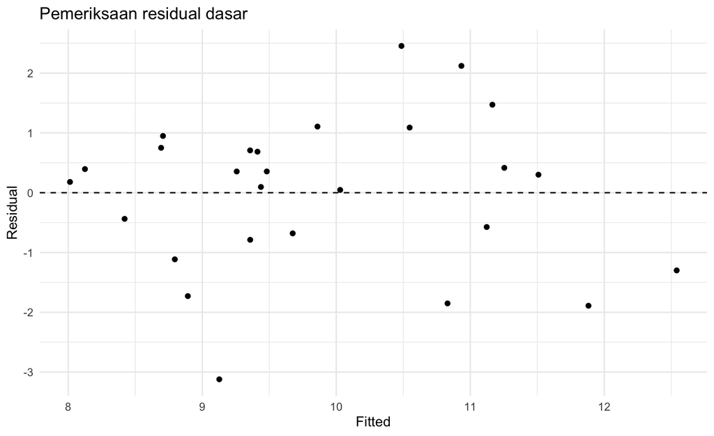

```r
augment(m1) |>
  ggplot(aes(.fitted, .resid)) +
  geom_hline(yintercept = 0, linetype = 2) +
  geom_point() +
  labs(x = "Fitted", y = "Residual", title = "Pemeriksaan residual dasar")
```

## 6.7 Contoh dengan Data Nyata

INDO-DAPOER memiliki poverty rate (`SI.POV.NAPR.ZS`), HDI (`IDX.HDI`), literacy (`SE.LITR.15UP.ZS`), populasi (`SP.POP.TOTL`), unemployment counts (`SL.UEM.TOTL`) dan labor force (`SL.TLF`). TPT dapat dikonstruksi dari `SL.UEM.TOTL/SL.TLF*100` jika definisi dan periode kompatibel. (World Bank 2026)

**Kartu dataset real.**

- **Nama:** subset kemiskinan, pembangunan manusia, literasi, populasi, pengangguran dan angkatan kerja INDO-DAPOER.
- **Sumber dan URL:** World Bank Data Catalog, https://datacatalog.worldbank.org/search/dataset/0041056/indonesia-database-for-policy-and-economic-research.
- **Tahun:** sampai 2018, dipilih periode dengan overlap data.
- **Unit observasi:** kabupaten/kota–tahun.
- **Variabel/definisi:** poverty rate (%), HDI (indeks), literacy 15+ (%), total population, number unemployed, labor force; TPT latihan dapat dihitung sebagai `unemployed/labor_force*100` bila definisinya kompatibel.
- **Alasan digunakan:** menyediakan outcome dan covariates untuk regresi/inferensi dengan konteks pembangunan regional.
- **Keterbatasan:** regresi observasional menunjukkan asosiasi, bukan efek kebijakan kausal; denominator dan kompatibilitas definisi harus diverifikasi. (World Bank 2026)

## 6.8 Analisis Menggunakan R

```r
if (dir.exists("data/raw/indodapoer") && length(list.files("data/raw/indodapoer")) > 0) {
  source("R/03_prepare_indodapoer.R")
  indo <- load_indodapoer()
  sel <- indo |>
    dplyr::filter(kode_indikator %in% c("SI.POV.NAPR.ZS", "IDX.HDI", "SE.LITR.15UP.ZS", "SL.UEM.TOTL", "SL.TLF"), tahun == 2018) |>
    dplyr::select(wilayah, kode_indikator, nilai) |>
    tidyr::pivot_wider(names_from = kode_indikator, values_from = nilai) |>
    dplyr::mutate(tpt_constructed = 100 * SL.UEM.TOTL / SL.TLF)
  fit_real <- lm(SI.POV.NAPR.ZS ~ IDX.HDI + SE.LITR.15UP.ZS + tpt_constructed, data = sel)
} else {
  sel <- readr::read_csv("data/simulasi_panel_regional.csv", show_col_types = FALSE) |> dplyr::filter(tahun == 2025)
  fit_real <- lm(kemiskinan_persen ~ ipm + indeks_pendidikan + tpt_persen, data = sel)
}
broom::tidy(fit_real, conf.int = TRUE) |> knitr::kable(digits = 3, caption = "Output: estimasi model dan interval kepercayaan")
```

Table 6.2: Output: estimasi model dan interval kepercayaan

| term | estimate | std.error | statistic | p.value | conf.low | conf.high |
| --- | --- | --- | --- | --- | --- | --- |
| (Intercept) | 17.875 | 22.593 | 0.791 | 0.437 | -28.863 | 64.612 |
| ipm | 0.146 | 0.392 | 0.372 | 0.714 | -0.665 | 0.957 |
| indeks_pendidikan | -0.187 | 0.084 | -2.212 | 0.037 | -0.361 | -0.012 |
| tpt_persen | -0.640 | 0.299 | -2.138 | 0.043 | -1.259 | -0.021 |

## 6.9 Paket Output Regresi Lengkap

```r
reg6 <- readr::read_csv("data/simulasi_panel_regional.csv", show_col_types = FALSE) |>
  dplyr::filter(tahun == 2025)
fit6 <- stats::lm(kemiskinan_persen ~ pdrb_perkapita_juta + tpt_persen + internet_persen + ipm + urban, data=reg6)
coef6 <- broom::tidy(fit6, conf.int=TRUE)
knitr::kable(coef6, digits=3, caption="Koefisien OLS, standard error, p-value, dan 95% CI")
```

Table 6.3: Koefisien OLS, standard error, p-value, dan 95% CI

| term | estimate | std.error | statistic | p.value | conf.low | conf.high |
| --- | --- | --- | --- | --- | --- | --- |
| (Intercept) | 2.866 | 24.361 | 0.118 | 0.907 | -47.796 | 53.528 |
| pdrb_perkapita_juta | -0.125 | 0.065 | -1.929 | 0.067 | -0.259 | 0.010 |
| tpt_persen | -0.434 | 0.352 | -1.234 | 0.231 | -1.165 | 0.297 |
| internet_persen | -0.017 | 0.068 | -0.254 | 0.802 | -0.158 | 0.124 |
| ipm | 0.248 | 0.360 | 0.689 | 0.498 | -0.501 | 0.997 |
| urban | 0.888 | 0.926 | 0.959 | 0.348 | -1.038 | 2.815 |

```r
glance6 <- broom::glance(fit6) |> dplyr::select(r.squared, adj.r.squared, sigma, statistic, p.value, AIC, BIC, df.residual)
knitr::kable(glance6, digits=3, caption="Ringkasan goodness-of-fit model regresi")
```

Table 6.4: Ringkasan goodness-of-fit model regresi

| r.squared | adj.r.squared | sigma | statistic | p.value | AIC | BIC | df.residual |
| --- | --- | --- | --- | --- | --- | --- | --- |
| 0.49 | 0.369 | 1.393 | 4.043 | 0.01 | 101.726 | 110.797 | 21 |

```r
aug6 <- broom::augment(fit6)
metric6 <- tibble::tibble(
  RMSE = rmse_manual(reg6$kemiskinan_persen, aug6$.fitted),
  MAE = mae_manual(reg6$kemiskinan_persen, aug6$.fitted),
  mean_residual = mean(aug6$.resid),
  max_cooks_d = max(aug6$.cooksd)
)
knitr::kable(metric6, digits=3, caption="Ukuran error dan influence pada data estimasi")
```

Table 6.5: Ukuran error dan influence pada data estimasi

| RMSE | MAE | mean_residual | max_cooks_d |
| --- | --- | --- | --- |
| 1.228 | 0.942 | 0 | 0.256 |

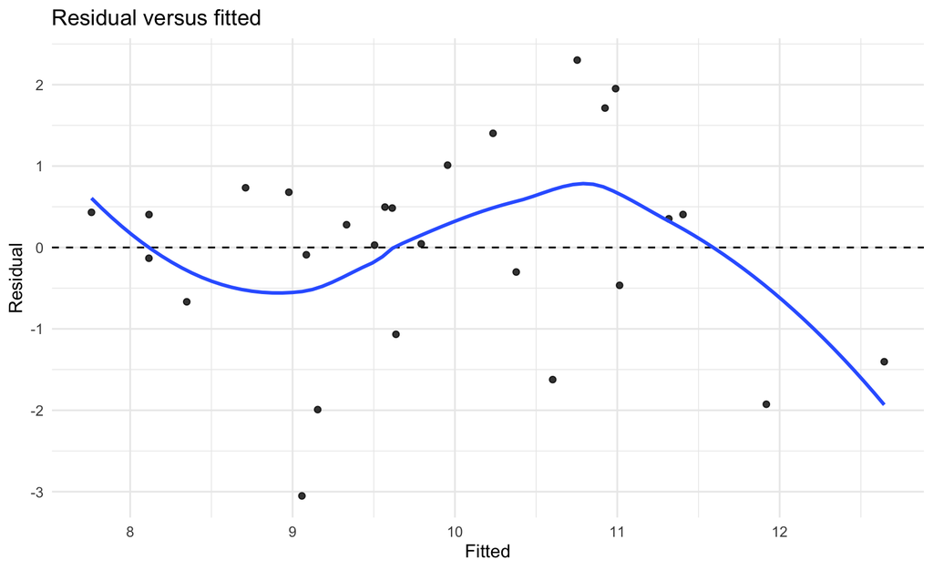

```r
ggplot2::ggplot(aug6, ggplot2::aes(.fitted, .resid)) +
  ggplot2::geom_hline(yintercept=0, linetype=2) + ggplot2::geom_point(alpha=.8) +
  ggplot2::geom_smooth(se=FALSE) + ggplot2::labs(title="Residual versus fitted", x="Fitted", y="Residual")
```

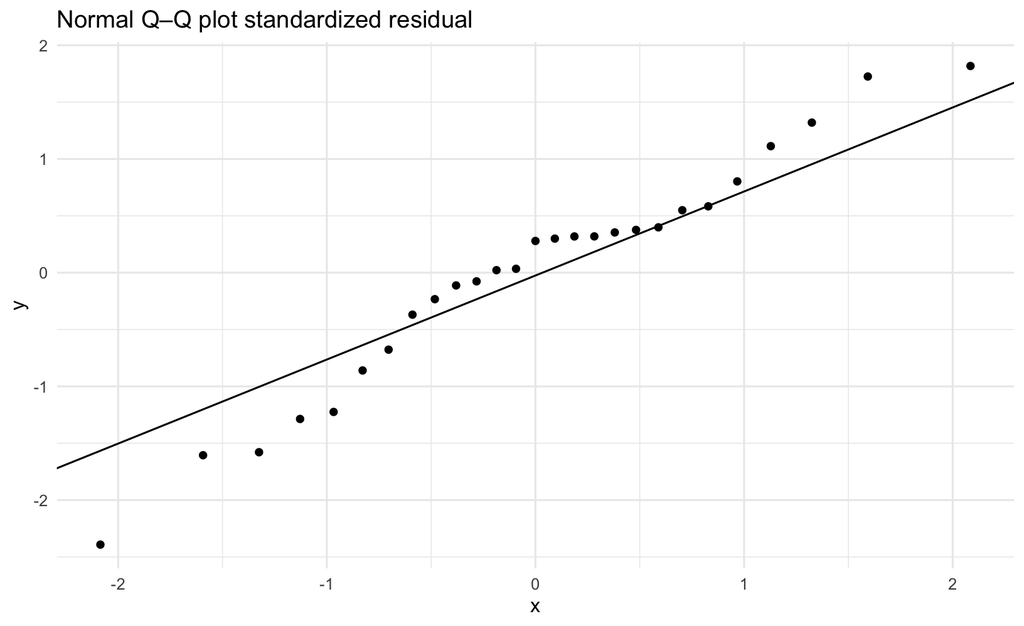

```r
ggplot2::ggplot(aug6, ggplot2::aes(sample=.std.resid)) +
  ggplot2::stat_qq() + ggplot2::stat_qq_line() +
  ggplot2::labs(title="Normal Q–Q plot standardized residual")
```

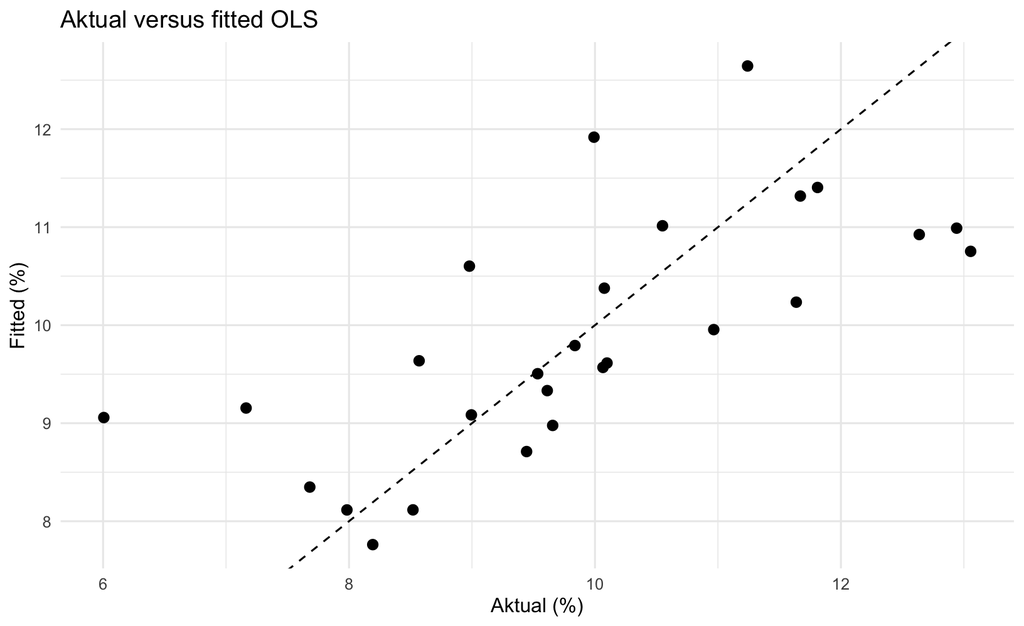

```r
ggplot2::ggplot(aug6, ggplot2::aes(kemiskinan_persen, .fitted)) +
  ggplot2::geom_abline(slope=1,intercept=0,linetype=2) + ggplot2::geom_point(size=2.5) +
  ggplot2::labs(title="Aktual versus fitted OLS", x="Aktual (%)", y="Fitted (%)")
```

## 6.10 Interpretasi dalam Konteks Regional

Koefisien harus dibaca bersama skala, interval ketidakpastian, dan plausibilitas substantif. Jika model menunjukkan HDI dan literacy sama-sama kuat tetapi sangat berkorelasi, koefisien individual dapat menjadi tidak stabil. Untuk kebijakan, fokus pada *evidence pattern* dan ketidakpastian, bukan pada signifikansi p-value saja.

## 6.11 Latihan

1. Apa arti “mengontrol variabel lain” dalam regresi?
2. Mengapa p-value kecil tidak sama dengan dampak kebijakan besar?
3. Apa risiko multikolinearitas pada indikator pembangunan yang saling tumpang tindih?
4. **Analisis:** bandingkan model sederhana dan model berganda pada data simulasi.
5. **Analisis:** buat interval kepercayaan prediksi untuk lima wilayah.
6. **Mini-case:** koefisien investasi positif terhadap pengangguran. Susun minimal tiga penjelasan selain “investasi meningkatkan pengangguran”.

### 6.11.1 Tugas Terstruktur Pertemuan 6

Bangun baseline regression untuk outcome regional. Laporkan model equation, coefficient table, CI, residual diagnostics, VIF, satu interaction term yang punya justifikasi, dan interpretasi substantif. Tuliskan satu paragraf berjudul **“Apa yang tidak dapat saya simpulkan secara kausal dari model ini.”**

### 6.11.2 Kuis Formatif Pertemuan 6

1. Interpretasi $\beta_j$ pada multiple regression.
2. Perbedaan CI koefisien dan prediction interval.
3. Apa arti VIF besar?
4. Bagaimana membaca interaction $x_1x_2$?
5. Mengapa $R^2$ tinggi tidak menjamin model bagus untuk data baru?

## 6.12 Hubungan dengan Capstone Project

Kelompok menyusun **baseline statistical model** dan mendokumentasikan asumsi. Baseline dibutuhkan agar model ML yang lebih kompleks memiliki pembanding yang bermakna.

## 6.13 Kesimpulan

Regresi adalah alat dasar yang sangat kuat untuk regional analytics jika digunakan dengan disiplin interpretasi, diagnostik, dan kesadaran terhadap confounding serta struktur data.

## 6.14 Pendalaman Magister — Inferensi dan regression reasoning

### 6.14.1 Audit metodologis

1. P-value dijadikan ukuran importance.
2. R2 dijadikan ukuran kausalitas.
3. Multikolinearitas diabaikan.
4. Nonlinearity/interaksi tidak diperiksa.
5. Dependence panel/spasial diabaikan.
6. Koefisien asosiasi disebut dampak kebijakan.

### 6.14.2 Pertanyaan viva / diskusi kelas

1. Apa makna conditional coefficient?
2. Mengapa CI bukan probabilitas parameter frequentist?
3. Apa yang dilakukan VIF?
4. Bagaimana interaction mengubah marginal effect?
5. Kapan prediction interval lebih relevan?
6. Apa asumsi tambahan untuk causal interpretation?

# 7 Predictive Modeling, Resampling, dan Pencegahan Data Leakage

## 7.1 Pendahuluan

Prediksi menilai kemampuan model untuk bekerja pada data yang tidak digunakan saat fitting. Kesalahan umum dalam proyek regional adalah mengevaluasi model pada data training atau melakukan preprocessing menggunakan seluruh data sebelum split, sehingga kinerja terlihat terlalu baik.

## 7.2 Tujuan Pembelajaran

Mahasiswa mampu membangun workflow train/test, cross-validation, baseline, feature preprocessing, serta mendeteksi leakage temporal dan geografis.

## 7.3 Definisi dan Konsep

**Generalization error** adalah error pada observasi baru. **Data leakage** terjadi ketika informasi yang seharusnya tidak tersedia saat prediksi masuk ke proses training. Untuk forecast atau panel waktu, random split dapat membocorkan informasi masa depan. Untuk wilayah, random split juga dapat terlalu optimistis bila wilayah tetangga sangat serupa.

## 7.4 Formulasi Matematis

MSE dan RMSE:

$$MSE=\frac{1}{n}\sum_{i=1}^n(y_i-\hat y_i)^2,\qquad RMSE=\sqrt{MSE}.$$

MAE:

$$MAE=\frac{1}{n}\sum_{i=1}^n|y_i-\hat y_i|.$$

Dalam $K$-fold cross-validation,

$$CV_K=\frac{1}{K}\sum_{k=1}^K L_k,$$

dengan $L_k$ loss pada fold ke-$k$.

### 7.4.1 Generalization error

Tujuan prediksi bukan meminimalkan training error, tetapi error pada data baru:
$$Err_{gen}=\mathbb{E}_{(X,Y)\sim P_{new}}[L\{Y,\hat f(X)\}].$$
Test error adalah estimator praktis dari kuantitas ini ketika test set benar-benar independen dari proses training/tuning.

### 7.4.2 K-fold cross-validation

Data training dibagi menjadi $K$ fold $\mathcal{I}_1,\dots,\mathcal{I}_K$. Model $\hat f^{(-k)}$ dilatih tanpa fold $k$. Estimator CV risk:
$$\widehat R_{CV}=\frac{1}{n}\sum_{k=1}^{K}\sum_{i\in\mathcal I_k}L\{y_i,\hat f^{(-k)}(x_i)\}.$$
Untuk panel regional, random CV dapat terlalu optimistis bila observasi wilayah yang sama muncul di train dan validation. Gunakan *grouped CV*, spatial blocking, atau rolling/temporal split sesuai target deployment. (Kuhn dan Silge 2022)

### 7.4.3 Metrik regresi

$$RMSE=\sqrt{\frac{1}{n}\sum_i(y_i-\hat y_i)^2},$$

$$MAE=\frac{1}{n}\sum_i|y_i-\hat y_i|,$$

$$MAPE=\frac{100\%}{n}\sum_i\left|\frac{y_i-\hat y_i}{y_i}\right|.$$
MAPE bermasalah saat $y_i$ dekat nol. Untuk indikator seperti growth yang dapat nol/negatif, MAE/RMSE atau scaled errors biasanya lebih aman.

### 7.4.4 Bias–variance decomposition

Untuk squared error pada titik $x_0$,
$$E[(Y-\hat f(x_0))^2]
=\sigma^2+\{Bias[\hat f(x_0)]\}^2+Var[\hat f(x_0)].$$
Model sangat fleksibel dapat menurunkan bias tetapi meningkatkan variance. Resampling membantu memilih kompleksitas yang memberi trade-off generalization terbaik. (Hastie, Tibshirani, dan Friedman 2009)

### 7.4.5 Ridge dan lasso sebagai regularized regression

Ridge:
$$\widehat\beta^{ridge}=\arg\min_{\beta_0,\boldsymbol\beta}
\left\{\sum_i(y_i-\beta_0-\mathbf x_i'\boldsymbol\beta)^2+\lambda\sum_{j=1}^{p}\beta_j^2\right\}.$$
Lasso:
$$\widehat\beta^{lasso}=\arg\min_{\beta_0,\boldsymbol\beta}
\left\{\sum_i(y_i-\beta_0-\mathbf x_i'\boldsymbol\beta)^2+\lambda\sum_{j=1}^{p}|\beta_j|\right\}.$$
Ridge mengecilkan koefisien; lasso dapat menghasilkan beberapa koefisien tepat nol. Prediktor sebaiknya distandardisasi sebelum regularisasi. (Hoerl dan Kennard 1970; Tibshirani 1996)

### 7.4.6 Data leakage formal

Misalkan transformasi preprocessing memiliki parameter $\theta$. Leakage terjadi jika
$$\widehat\theta=g(\mathcal D_{train}\cup\mathcal D_{test})$$
ketika seharusnya
$$\widehat\theta=g(\mathcal D_{train}).$$
Contoh: standardisasi, imputasi, feature selection, PCA, atau tuning threshold menggunakan test set. Test set baru “dibuka” setelah seluruh keputusan model selesai.

## 7.5 Intuisi Metode

RMSE lebih memberi penalti pada error besar. Jika kebijakan sangat sensitif terhadap kegagalan memprediksi wilayah ekstrem, RMSE bisa lebih relevan daripada MAE. Tetapi metric harus terkait keputusan, bukan dipilih hanya karena umum digunakan.

### 7.5.1 Worked Example — split temporal

Tujuan: memprediksi indikator 2025 menggunakan informasi hingga 2024. Maka split random yang memasukkan observasi 2025 ke training melanggar deployment. Gunakan
$$\mathcal D_{train}=\{t\le2023\},\quad \mathcal D_{valid}=\{t=2024\},\quad \mathcal D_{test}=\{t=2025\}.$$
Validation dipakai tuning; test hanya evaluasi final.

### 7.5.2 RMSE vs MAE numeric

Error model A: $(1,1,1,5)$. MAE=$2$, RMSE=$\sqrt{(1+1+1+25)/4}=\sqrt7=2.646$. Error ekstrem mendapat penalti lebih kuat pada RMSE. Jika kebijakan sangat sensitif terhadap miss besar, RMSE mungkin lebih sesuai; jika robust typical absolute error lebih penting, MAE informatif.

### 7.5.3 Cross-validation manual intuition

Untuk 5-fold CV, setiap observasi menjadi validation tepat sekali. Jika fold RMSE = 2.1, 2.4, 1.9, 2.6, 2.2:
$$\bar{RMSE}=2.24,$$
$$s=\sqrt{\sum_k(RMSE_k-2.24)^2/(5-1)}\approx0.27.$$
Laporkan distribusi, bukan hanya mean. Variability tinggi berarti model sensitif terhadap sample composition.

### 7.5.4 Ridge shrinkage intuition

Jika dua prediktor sangat berkorelasi, OLS dapat menghasilkan koefisien besar dengan tanda tidak stabil. Ridge menambah $\lambda\sum\beta_j^2$, sehingga solusi menerima sedikit bias untuk mengurangi variance. `lambda` bukan dipilih dari test set; gunakan resampling training.

### 7.5.5 R workflow dengan tidymodels

```r
set.seed(260817)
dat <- readr::read_csv("data/simulasi_panel_regional.csv", show_col_types = FALSE) |>
  dplyr::select(kemiskinan_persen, pdrb_perkapita_juta, tpt_persen, internet_persen, ipm, umkm_per_1000)
spl <- initial_split(dat, prop = .8)
tr <- training(spl)
folds <- vfold_cv(tr, v = 5)
rec <- recipe(kemiskinan_persen ~ ., data = tr) |> step_normalize(all_numeric_predictors())
mod <- linear_reg() |> set_engine("lm")
wf <- workflow() |> add_recipe(rec) |> add_model(mod)
res <- fit_resamples(wf, resamples = folds, metrics = metric_set(rmse, mae, rsq))
collect_metrics(res) |> knitr::kable(digits = 3, caption = "Output: 5-fold cross-validation baseline")
```

Table 7.1: Output: 5-fold cross-validation baseline

| .metric | .estimator | mean | n | std_err | .config |
| --- | --- | --- | --- | --- | --- |
| mae | standard | 1.024 | 5 | 0.030 | pre0_mod0_post0 |
| rmse | standard | 1.313 | 5 | 0.050 | pre0_mod0_post0 |
| rsq | standard | 0.711 | 5 | 0.027 | pre0_mod0_post0 |

### 7.5.6 Leakage audit table

| Komponen | Fit hanya pada train/resample? | Risiko jika tidak |
| --- | --- | --- |
| median imputation | ya | test distribution bocor |
| normalization | ya | mean/SD test bocor |
| feature selection | ya | selection optimism |
| PCA | ya | loading memakai test |
| hyperparameter tuning | ya | overfit test |
| threshold selection | validation | inflated test metric |

### 7.5.7 Deployment realism

Pertanyaan validasi bukan “split mana yang paling mudah”, tetapi “data apa yang akan tersedia saat model benar-benar dipakai?”. Untuk prediksi wilayah baru, group split by region mungkin tepat. Untuk masa depan, temporal split. Untuk generalisasi geografis, spatial block. (Kuhn dan Silge 2022)

## 7.6 Contoh dengan Data Simulasi

```r
panel <- read_csv("data/simulasi_panel_regional.csv", show_col_types = FALSE)
train <- panel |> filter(tahun <= 2023)
test  <- panel |> filter(tahun >= 2024)

fit <- lm(kemiskinan_persen ~ pdrb_perkapita_juta + tpt_persen + internet_persen + ipm,
          data = train)

pred <- test |> mutate(.pred = predict(fit, newdata = test))
pred |>
  summarise(RMSE = rmse_manual(kemiskinan_persen, .pred),
            MAE = mae_manual(kemiskinan_persen, .pred)) |>
  knitr::kable(digits = 3)
```

| RMSE | MAE |
| --- | --- |
| 1.413 | 1.096 |

### 7.6.1 Visualisasi Output: Aktual versus Prediksi

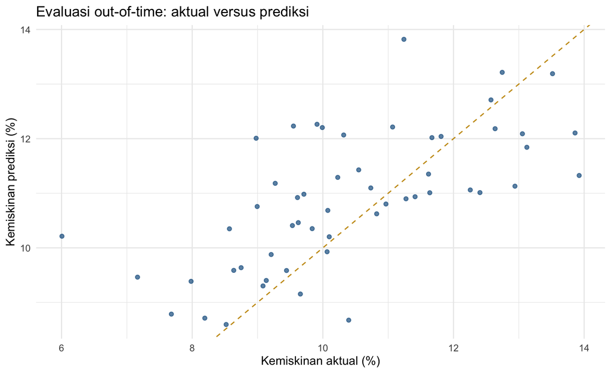

```r
pred |>
  ggplot2::ggplot(ggplot2::aes(kemiskinan_persen, .pred)) +
  ggplot2::geom_abline(slope = 1, intercept = 0, linetype = 2, colour = "#C99A17") +
  ggplot2::geom_point(alpha = .7, colour = "#145B8C") +
  ggplot2::labs(
    title = "Evaluasi out-of-time: aktual versus prediksi",
    x = "Kemiskinan aktual (%)", y = "Kemiskinan prediksi (%)"
  )
```

## 7.7 Contoh dengan Data Nyata

Data panel INDO-DAPOER dapat dibagi berdasarkan waktu, misalnya training sampai 2015 dan test 2016-2018, selama indikator memiliki kelengkapan memadai. Karena data historis, tujuan latihan adalah mengevaluasi pipeline, bukan memberi rekomendasi kebijakan terkini.

**Kartu dataset real.**

- **Nama:** panel indikator subnasional INDO-DAPOER untuk latihan *time-aware validation*.
- **Sumber dan URL:** World Bank Data Catalog, https://datacatalog.worldbank.org/search/dataset/0041056/indonesia-database-for-policy-and-economic-research.
- **Tahun:** hingga 2018; contoh split: training ≤2015 dan test 2016–2018 jika data tersedia.
- **Unit observasi:** wilayah–tahun.
- **Variabel/definisi:** outcome regional dipilih dari indikator numerik; predictors berupa indikator ekonomi/sosial yang diketahui sebelum outcome pada horizon prediksi.
- **Alasan digunakan:** struktur waktu memungkinkan demonstrasi perbedaan random split dan temporal holdout serta risiko leakage.
- **Keterbatasan:** data historis tidak digunakan untuk klaim kondisi terkini; fitur dengan publikasi terlambat dapat menyebabkan *look-ahead bias*. (World Bank 2026)

## 7.8 Analisis Menggunakan R

```r
library(tidymodels)
set.seed(260807)
reg <- read_csv("data/simulasi_panel_regional.csv", show_col_types = FALSE) |> filter(tahun == 2025)
split <- initial_split(reg, prop = .8, strata = kemiskinan_persen)
tr <- training(split); te <- testing(split)

rec <- recipe(kemiskinan_persen ~ pdrb_perkapita_juta + tpt_persen + internet_persen + ipm + umkm_per_1000,
              data = tr) |>
  step_normalize(all_numeric_predictors())

mod <- linear_reg() |> set_engine("lm")
wf <- workflow() |> add_recipe(rec) |> add_model(mod) |> fit(tr)
p <- predict(wf, te) |> bind_cols(te |> select(kemiskinan_persen))
yardstick::metrics(p, truth = kemiskinan_persen, estimate = .pred)
```

```
#> # A tibble: 3 × 3
#>   .metric .estimator .estimate
#>   <chr>   <chr>          <dbl>
#> 1 rmse    standard       1.66
#> 2 rsq     standard       0.369
#> 3 mae     standard       1.42
```

## 7.9 Paket Output Validasi Lengkap

```r
set.seed(260817)
dat7 <- readr::read_csv("data/simulasi_panel_regional.csv", show_col_types = FALSE) |>
  dplyr::select(kemiskinan_persen, pdrb_perkapita_juta, tpt_persen, internet_persen, ipm, umkm_per_1000)
split7 <- rsample::initial_split(dat7, prop=.8)
tr7 <- rsample::training(split7); te7 <- rsample::testing(split7)
folds7 <- rsample::vfold_cv(tr7, v=5)
wf7 <- workflows::workflow() |>
  workflows::add_recipe(recipes::recipe(kemiskinan_persen ~ ., data=tr7) |> recipes::step_normalize(recipes::all_numeric_predictors())) |>
  workflows::add_model(parsnip::linear_reg() |> parsnip::set_engine("lm"))
res7 <- tune::fit_resamples(wf7, resamples=folds7, metrics=yardstick::metric_set(yardstick::rmse, yardstick::mae, yardstick::rsq))
fold_metric7 <- tune::collect_metrics(res7, summarize=FALSE)
knitr::kable(fold_metric7, digits=3, caption="Metric setiap fold — bukan hanya rata-rata")
```

Table 7.2: Metric setiap fold — bukan hanya rata-rata

| id | .metric | .estimator | .estimate | .config |
| --- | --- | --- | --- | --- |
| Fold1 | rmse | standard | 1.123 | pre0_mod0_post0 |
| Fold1 | mae | standard | 0.926 | pre0_mod0_post0 |
| Fold1 | rsq | standard | 0.802 | pre0_mod0_post0 |
| Fold2 | rmse | standard | 1.346 | pre0_mod0_post0 |
| Fold2 | mae | standard | 1.086 | pre0_mod0_post0 |
| Fold2 | rsq | standard | 0.647 | pre0_mod0_post0 |
| Fold3 | rmse | standard | 1.328 | pre0_mod0_post0 |
| Fold3 | mae | standard | 1.084 | pre0_mod0_post0 |
| Fold3 | rsq | standard | 0.667 | pre0_mod0_post0 |
| Fold4 | rmse | standard | 1.356 | pre0_mod0_post0 |
| Fold4 | mae | standard | 1.016 | pre0_mod0_post0 |
| Fold4 | rsq | standard | 0.724 | pre0_mod0_post0 |
| Fold5 | rmse | standard | 1.414 | pre0_mod0_post0 |
| Fold5 | mae | standard | 1.007 | pre0_mod0_post0 |
| Fold5 | rsq | standard | 0.714 | pre0_mod0_post0 |

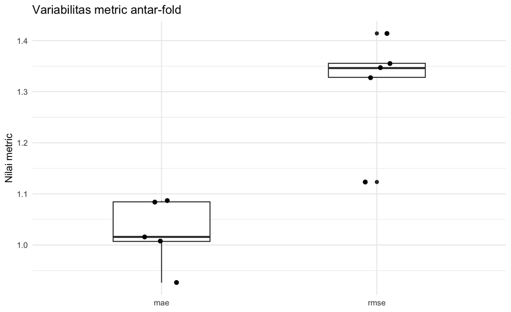

```r
ggplot2::ggplot(fold_metric7 |> dplyr::filter(.metric %in% c("rmse","mae")), ggplot2::aes(.metric,.estimate)) +
  ggplot2::geom_boxplot(width=.45) + ggplot2::geom_jitter(width=.08, size=2) +
  ggplot2::labs(title="Variabilitas metric antar-fold", x=NULL, y="Nilai metric")
```

```r
fit7 <- generics::fit(wf7, data = tr7)
pred7 <- predict(fit7, te7) |> dplyr::bind_cols(te7 |> dplyr::select(kemiskinan_persen))
yardstick::metrics(pred7, truth=kemiskinan_persen, estimate=.pred) |>
  knitr::kable(digits=3, caption="Final test metrics setelah resampling selesai")
```

Table 7.3: Final test metrics setelah resampling selesai

| .metric | .estimator | .estimate |
| --- | --- | --- |
| rmse | standard | 1.096 |
| rsq | standard | 0.719 |
| mae | standard | 0.870 |

## 7.10 Interpretasi dalam Konteks Regional

Model dengan RMSE 1,2 poin kemiskinan berarti error tipikal berada pada skala sekitar satu poin persentase, tetapi implikasinya berbeda bagi wilayah 3% dan 20%. Evaluasi perlu melihat error menurut kelompok: urban/rural, wilayah miskin/nonmiskin, dan wilayah dengan data terbatas.

## 7.11 Latihan

1. Apa perbedaan training error dan test error?
2. Berikan contoh data leakage dalam monitoring kemiskinan.
3. Mengapa random split dapat bermasalah untuk data time series?
4. **Analisis:** bandingkan split acak dan split waktu pada data simulasi.
5. **Analisis:** hitung RMSE per kelompok urban/nonurban.
6. **Mini-case:** model nasional bagus tetapi buruk di wilayah timur. Apa evaluasi tambahan yang wajib dilakukan sebelum deployment?

### 7.11.1 Tugas 3 — Validation & Leakage Audit (2,5%)

Bandingkan minimal dua model pada split yang sesuai dengan deployment (random/group/time). Laporkan baseline, CV metric distribution, final test metric, dan tabel leakage audit. Setiap transformasi harus dikerjakan hanya pada training/resample yang relevan.

### 7.11.2 Kuis 2 — Minggu 4–7 (2,5%)

Kisi-kisi: summary/inequality; visualisasi; OLS; CI; interaction; RMSE/MAE; cross-validation; bias–variance; ridge/lasso; leakage; baseline comparison.

## 7.12 Hubungan dengan Capstone Project

Kelompok harus menetapkan **evaluation protocol** sebelum mencoba banyak model: unit split, metric utama, metric sekunder, baseline, dan subgroup check.

## 7.13 Kesimpulan

Evaluasi yang jujur lebih penting daripada skor spektakuler. Leakage dapat membuat model tampak hebat namun gagal saat digunakan untuk keputusan nyata.

## 7.14 Pendalaman Magister — Generalization dan resampling

### 7.14.1 Audit metodologis

1. Random split tidak sesuai deployment.
2. Test set dipakai tuning.
3. Preprocessing fit pada seluruh data.
4. Hanya melaporkan satu metric.
5. Resample dependence diabaikan.
6. Model kompleks tanpa baseline.

### 7.14.2 Pertanyaan viva / diskusi kelas

1. Apa target generalization?
2. Mengapa temporal split berbeda dari random split?
3. Apa bias–variance trade-off?
4. Bagaimana ridge dan lasso berbeda?
5. Mengapa test set hanya sekali?
6. Apa arti variability antar-fold?

# 8 UTS: Integrative Regional Data Case

## 8.1 Pendahuluan

UTS menguji integrasi kompetensi minggu 1-7. Fokusnya bukan menghafal sintaks, melainkan membuat keputusan analitik yang dapat dipertanggungjawabkan.

## 8.2 Tujuan Pembelajaran

Mahasiswa mampu mengaudit dataset, merumuskan pertanyaan, melakukan EDA, membangun baseline model, mengevaluasi, dan menulis interpretasi kebijakan singkat secara individual.

## 8.3 Definisi dan Konsep

UTS menggunakan *open-book analytical case*. Mahasiswa dapat melihat dokumentasi R, tetapi harus menjelaskan alasan pilihan metode dan interpretasi. Data dapat berupa potongan indikator kabupaten/kota dengan masalah kualitas yang sengaja disisipkan.

## 8.4 Formulasi Matematis

Formula yang diujikan berasal dari bab 1-7: rate, standardisasi, mean/variance, korelasi, regresi, RMSE, dan MAE. Mahasiswa tidak dinilai karena menghafal formula, tetapi karena memilih formula yang sesuai dan menjelaskan simbol serta unitnya.

### 8.4.1 Formula sheet UTS yang harus dipahami, bukan dihafal tanpa konteks

UTS mengintegrasikan materi minggu 1–7. Mahasiswa harus dapat menjelaskan kapan setiap rumus relevan dan asumsi apa yang menyertainya.

**Rate dan growth**
$$r=\frac{a}{b}k,\qquad g_t=\frac{x_t-x_{t-1}}{x_{t-1}}.$$

**Z-score**
$$z=\frac{x-\bar x}{s}.$$

**Correlation**
$$r=\frac{\sum_i(x_i-\bar x)(y_i-\bar y)}{(n-1)s_xs_y}.$$

**OLS**
$$\hat\beta=(X'X)^{-1}X'y.$$

**RMSE/MAE**
$$RMSE=\sqrt{n^{-1}\sum_i e_i^2},\qquad MAE=n^{-1}\sum_i|e_i|.$$

**CV risk**
$$\widehat R_{CV}=n^{-1}\sum_{k}\sum_{i\in\mathcal I_k}L(y_i,\hat f^{(-k)}(x_i)).$$

### 8.4.2 Filosofi soal UTS

UTS bukan ujian “mengetik kode tercepat”. Sebuah jawaban lengkap memiliki empat lapis:

1. **analytical framing** — apa unit analisis dan target keputusan;
2. **statistical correctness** — metode, asumsi, dan metrik tepat;
3. **computational reproducibility** — kode dapat dijalankan dan transformasi terdokumentasi;
4. **regional interpretation** — temuan diterjemahkan ke karakter wilayah, bukan sekadar angka model.

### 8.4.3 Kisi-kisi UTS (20% nilai akhir)

| Area | Proporsi skor UTS | Kemampuan yang diuji |
| --- | --- | --- |
| Problem framing & metadata | 15% | unit analisis, outcome, provenance, keterbatasan |
| Data quality & wrangling | 20% | missing, duplicate, join, feature construction |
| EDA & visualization | 20% | memilih ringkasan/grafik dan membaca disparitas |
| Inferensi/regresi | 20% | formulasi, asumsi, interpretasi koefisien/CI |
| Prediction & validation | 15% | split/CV, RMSE/MAE, leakage |
| Policy interpretation | 10% | insight, caveat, recommendation |

### 8.4.4 Bentuk UTS yang disarankan

- **Individual**, open-book, akses dokumentasi R diperbolehkan.
- Dataset regional baru yang strukturnya serupa dengan latihan tetapi angka/topiknya berbeda.
- Durasi 150–180 menit atau *take-home controlled window* sesuai kebijakan program.
- Jawaban: `.Rmd/.qmd` atau notebook + PDF/HTML hasil render.
- Generative AI **tidak digunakan untuk menghasilkan jawaban selama ujian**, kecuali dosen secara eksplisit menetapkan mode AI-assisted; kebijakan harus diumumkan sebelum ujian.

### 8.4.5 Rubrik ringkas UTS

Setiap bagian dinilai: **ketepatan (40%) + alasan metodologis (25%) + interpretasi regional (25%) + reproducibility/komunikasi (10%)**. Kesalahan yang menghasilkan klaim kebijakan tidak valid dapat menurunkan skor lebih besar daripada kesalahan sintaks kecil yang mudah diperbaiki.

## 8.5 Intuisi Metode

UTS mensimulasikan situasi analis: data belum sempurna, waktu terbatas, dan stakeholder membutuhkan ringkasan yang akurat. Jawaban terbaik bukan yang memakai model paling kompleks, tetapi yang menjaga validitas dari awal sampai interpretasi.

### 8.5.1 Mock UTS Case — struktur jawaban ideal

**Kasus:** dataset 27 kabupaten/kota × 2016–2024 berisi TPT, kemiskinan, pertumbuhan PDRB, internet, dan pendidikan. Ada duplikasi 6 key, missing internet 2020 untuk 4 wilayah, dan satu nilai TPT=82 akibat salah decimal.

**Langkah 1 — audit.** Jangan langsung `drop_na()`. Identifikasi duplicate key dan nilai impossible. Verifikasi dari source sebelum koreksi.

**Langkah 2 — feature.** Untuk memprediksi TPT 2024, fitur yang berasal dari outcome 2024 tidak boleh digunakan. Gunakan lag 2023 atau indikator yang tersedia sebelum keputusan.

**Langkah 3 — EDA.** Minimal satu grafik trend, satu cross-sectional relationship, satu regional ranking/map. Setiap grafik punya source/unit.

**Langkah 4 — baseline.** Fit model linear pada ≤2022, validasi 2023, test 2024. Interpretasikan conditional associations.

**Langkah 5 — metric.** Jika RMSE 1.4 percentage points, terjemahkan: “typical squared-error scale sekitar 1.4 poin TPT”, bukan “akurasi 98.6%”.

**Langkah 6 — policy memo.** Pisahkan observation, hypothesis, dan recommendation.

### 8.5.2 Contoh scoring jawaban

Jawaban dengan kode sempurna tetapi menggunakan data 2024 untuk feature yang memprediksi 2024 dapat kehilangan skor besar karena **target leakage**. Sebaliknya syntax kecil yang tidak memengaruhi kesimpulan dapat mendapat penalti lebih ringan. Ini menegaskan prioritas validitas dibanding kosmetika.

### 8.5.3 Mini formula drill

1. Dari 12 ke 9: relative change $=(9-12)/12=-25\%$.
2. Error $(1,-2,3)$: $MAE=2$, $RMSE=\sqrt{14/3}=2.160$.
3. Jika $R_j^2=0.9$, $VIF=10$.
4. Jika mean=50, SD=10, $x=70$, z-score=2.
5. Jika SSE=200, SST=500, $R^2=0.6$.

Mahasiswa seharusnya mampu menghitung dan **menjelaskan** makna tiap hasil.

### 8.5.4 UTS reproducibility checklist

File harus dapat di-knit dari awal. Gunakan path relatif; jangan menggunakan `setwd("/Users/nama/Desktop")`; jangan menyunting angka output secara manual; dan catat package yang dipakai. Bila data ujian disediakan lokal, gunakan `here` atau struktur folder sederhana.

## 8.6 Contoh dengan Data Simulasi

```r
set.seed(260808)
uts_case <- read_csv("data/simulasi_panel_regional.csv", show_col_types = FALSE) |>
  filter(tahun %in% c(2023, 2024, 2025)) |>
  sample_n(60) |>
  mutate(internet_persen = if_else(row_number() %% 13 == 0, NA_real_, internet_persen))
knitr::kable(head(uts_case, 8), digits = 2, caption = "Contoh struktur data case UTS")
```

Table 8.1: Contoh struktur data case UTS

| wilayah | tahun | urban | longitude | latitude | pdrb_perkapita_juta | kemiskinan_persen | tpt_persen | ipm | internet_persen | umkm_per_1000 | indeks_pendidikan | akses_kesehatan | indeks_inovasi |
| --- | --- | --- | --- | --- | --- | --- | --- | --- | --- | --- | --- | --- | --- |
| Wilayah_23 | 2025 | 0 | 106.92 | -6.89 | 41.20 | 13.05 | 7.05 | 69.78 | 72.33 | 35.41 | 65.93 | 70.35 | 70.57 |
| Wilayah_27 | 2023 | 1 | 107.67 | -6.04 | 42.78 | 12.10 | 8.44 | 67.63 | 77.99 | 31.82 | 65.90 | 59.45 | 66.14 |
| Wilayah_08 | 2023 | 0 | 106.96 | -6.76 | 32.64 | 12.09 | 6.92 | 68.94 | 64.86 | 30.16 | 70.45 | 60.78 | 59.17 |
| Wilayah_18 | 2025 | 1 | 107.84 | -7.68 | 53.71 | 9.84 | 7.75 | 70.68 | 84.59 | 40.48 | 64.91 | 63.78 | 67.93 |
| Wilayah_24 | 2024 | 1 | 108.35 | -6.50 | 52.89 | 11.27 | 7.99 | 68.66 | 82.10 | 38.27 | 62.40 | 60.52 | 63.88 |
| Wilayah_16 | 2023 | 1 | 107.54 | -7.54 | 46.36 | 9.45 | 9.43 | 65.87 | 77.38 | 32.02 | 59.58 | 55.15 | 64.34 |
| Wilayah_21 | 2025 | 0 | 107.06 | -6.75 | 24.04 | 11.24 | 6.74 | 67.78 | 65.66 | 31.20 | 60.43 | 64.54 | 60.84 |
| Wilayah_10 | 2025 | 1 | 107.47 | -7.51 | 66.15 | 8.52 | 8.09 | 71.62 | 96.99 | 46.95 | 77.19 | 76.32 | 70.22 |

### 8.6.1 Visualisasi Output: Audit Missing Data untuk Kasus UTS

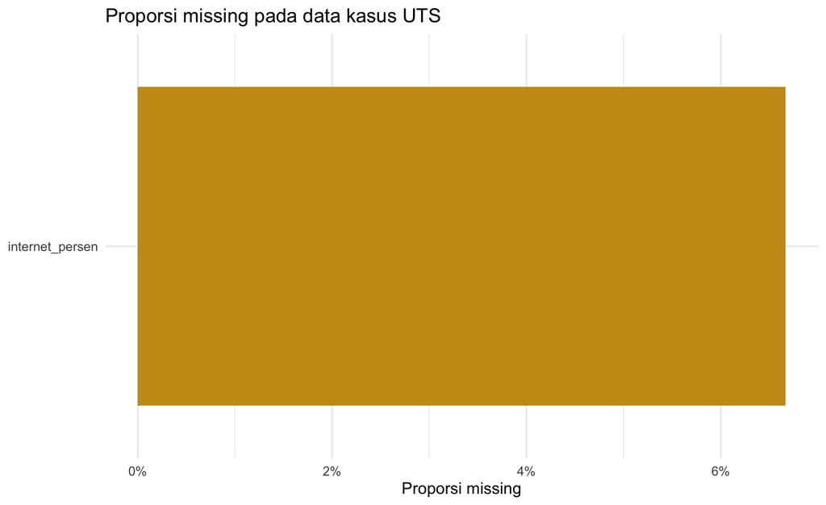

```r
uts_case |>
  dplyr::summarise(dplyr::across(dplyr::everything(), ~mean(is.na(.x)))) |>
  tidyr::pivot_longer(dplyr::everything(), names_to = "variabel", values_to = "prop_missing") |>
  dplyr::filter(prop_missing > 0) |>
  ggplot2::ggplot(ggplot2::aes(reorder(variabel, prop_missing), prop_missing)) +
  ggplot2::geom_col(fill = "#C99A17") +
  ggplot2::coord_flip() +
  ggplot2::scale_y_continuous(labels = scales::percent) +
  ggplot2::labs(title = "Proporsi missing pada data kasus UTS", x = NULL, y = "Proporsi missing")
```

## 8.7 Contoh dengan Data Nyata

Dosen dapat mengganti case dengan subset Open Data Jabar yang diunduh sebelum ujian. Dataset dan metadata diberikan bersama agar ujian mengukur analisis, bukan kemampuan mencari URL.

**Kartu dataset real untuk UTS.**

- **Nama:** TPT dan Jumlah Penduduk Miskin kabupaten/kota Jawa Barat (subset yang disiapkan dosen).
- **Sumber dan URL:** Open Data Jawa Barat/BPS: TPT https://opendata.jabarprov.go.id/id/dataset/tingkat-pengangguran-terbuka-berdasarkan-kabupatenkota-di-jawa-barat; kemiskinan https://opendata.jabarprov.go.id/id/dataset/jumlah-penduduk-miskin-berdasarkan-kabupatenkota-di-jawa-barat.
- **Tahun:** subset dari 2007–2024 (TPT) dan 2002–2025 (kemiskinan), dengan tahun overlap ditetapkan pada soal.
- **Unit observasi:** kabupaten/kota–tahun.
- **Variabel/definisi:** identitas wilayah, TPT (%), jumlah penduduk miskin (ribu jiwa), tahun; dosen dapat menambahkan denominator/populasi.
- **Alasan digunakan:** cukup kaya untuk menguji framing, cleaning, EDA, visualisasi, dan model dasar tanpa bergantung pada pencarian data saat ujian.
- **Keterbatasan:** kedua indikator tidak mengukur konsep yang sama; jumlah miskin dipengaruhi ukuran populasi sehingga perbandingan membutuhkan konteks/denominator. (Pemerintah Provinsi Jawa Barat 2026b)

## 8.8 Analisis Menggunakan R

Template minimum jawaban:

```r
dat <- uts_case |> tidyr::drop_na()
fit <- lm(kemiskinan_persen ~ internet_persen + pdrb_perkapita_juta + tpt_persen, data = dat)
broom::glance(fit) |>
  dplyr::select(r.squared, adj.r.squared, sigma, AIC) |>
  knitr::kable(digits = 3, caption = "Output contoh UTS: ringkasan baseline regression")
```

Table 8.2: Output contoh UTS: ringkasan baseline regression

| r.squared | adj.r.squared | sigma | AIC |
| --- | --- | --- | --- |
| 0.573 | 0.549 | 1.246 | 189.426 |

## 8.9 Interpretasi dalam Konteks Regional

Nilai tinggi diberikan untuk interpretasi yang mengenali trade-off dan ketidakpastian. Mahasiswa harus menghindari kalimat kausal jika desain data hanya observasional.

## 8.10 Latihan

1. Buat checklist 10 menit pertama saat menerima dataset baru.
2. Apa bukti minimal bahwa model baseline layak?
3. Apa tiga hal yang harus ada dalam executive summary analitik?
4. **Analisis:** kerjakan ulang salah satu mini-case bab 1-7 tanpa melihat solusi.
5. **Analisis:** buat fungsi R untuk audit missing dan duplikasi.
6. **Mini-case:** tulis policy note 200 kata dari satu grafik dan satu model.

### 8.10.1 Latihan Pra-UTS

Kerjakan satu *mock case* 90 menit: data kabupaten–tahun dengan dua masalah kualitas, satu missing mechanism yang perlu didiskusikan, satu visualisasi yang salah, dan satu baseline regression. Jawaban harus memuat kode serta policy interpretation.

### 8.10.2 Checklist Sebelum UTS

Mahasiswa harus dapat menjelaskan tanpa membuka catatan: unit analisis; denominator; z-score; correlation; OLS objective; arti CI; RMSE vs MAE; K-fold CV; data leakage; dan mengapa prediksi tidak identik dengan kausalitas.

## 8.11 Hubungan dengan Capstone Project

UTS menjadi *quality gate*: kelemahan individu yang muncul pada UTS harus diperbaiki sebelum tim masuk ke model ML capstone.

## 8.12 Kesimpulan

UTS menilai integrasi, bukan potongan teknik. Kemampuan mendokumentasikan keputusan analitik sama pentingnya dengan mendapatkan output model.

## 8.13 Pendalaman Magister — Integrasi pra-UTS

### 8.13.1 Audit metodologis

1. Syntax diprioritaskan di atas validitas.
2. Metadata dilewati.
3. Jawaban tidak membedakan association/prediction.
4. Metric tanpa unit.
5. Kode tidak reproducible.
6. Rekomendasi tidak traceable ke hasil.

### 8.13.2 Pertanyaan viva / diskusi kelas

1. Bagaimana mengaudit kasus baru dalam 10 menit pertama?
2. Rumus apa yang harus dipahami bukan dihafal?
3. Bagaimana menemukan leakage?
4. Apa bentuk jawaban policy interpretation yang baik?
5. Bagaimana memprioritaskan waktu ujian?
6. Apa bukti minimal sebelum recommendation?

# 9 Machine Learning untuk Data Regional

## 9.1 Pendahuluan

Machine learning berguna ketika hubungan antarvariabel kompleks, interaksi banyak, atau tujuan utama adalah prediksi. Namun model harus dibandingkan dengan baseline yang sederhana dan dipilih berdasarkan generalisasi, interpretabilitas, biaya kesalahan, serta konteks implementasi. (James dkk. 2021; Kuhn dan Silge 2022)

## 9.2 Tujuan Pembelajaran

Mahasiswa mampu menjelaskan bias-variance trade-off, membangun workflow ML dengan resampling, menggunakan tree-based model, dan membandingkan kinerja dengan regresi baseline.

## 9.3 Definisi dan Konsep

**Bias** adalah error sistematis dari model yang terlalu sederhana; **variance** adalah sensitivitas model terhadap perubahan sampel. Random forest menggabungkan banyak pohon dengan bootstrap dan random feature selection sehingga variance berkurang. (Breiman 2001)

## 9.4 Formulasi Matematis

Dekomposisi error prediksi secara konseptual:

$$E[(Y-\hat f(X))^2]=\sigma^2 + Bias[\hat f(X)]^2 + Var[\hat f(X)].$$

Untuk random forest regresi, prediksi adalah rata-rata pohon:

$$\hat f_{RF}(x)=\frac{1}{B}\sum_{b=1}^{B}\hat f^{(b)}(x),$$

dengan $B$ jumlah pohon.

### 9.4.1 Decision tree untuk regresi

Pada node $R$, prediksi konstan terbaik untuk squared error adalah mean
$$\hat c_R=\frac{1}{|R|}\sum_{i:x_i\in R}y_i.$$
Split $(j,s)$ dipilih untuk meminimalkan
$$\sum_{i:x_i\in R_1(j,s)}(y_i-\hat c_1)^2+
\sum_{i:x_i\in R_2(j,s)}(y_i-\hat c_2)^2.$$
Tree yang terlalu dalam cenderung overfit; hyperparameter seperti `min_n`, depth, atau cost complexity mengendalikan kompleksitas. (James dkk. 2021)

### 9.4.2 Classification tree: Gini dan entropy

Jika node $m$ memiliki proporsi kelas $\hat p_{mk}$,
$$Gini(m)=\sum_{k=1}^{K}\hat p_{mk}(1-\hat p_{mk})=1-\sum_k\hat p_{mk}^2.$$
Entropy:
$$H(m)=-\sum_{k=1}^{K}\hat p_{mk}\log\hat p_{mk}.$$
Split dicari untuk menurunkan impurity tertimbang.

### 9.4.3 Bagging dan random forest

Untuk bootstrap sample $b=1,\ldots,B$, fit tree $\hat f^{(b)}$. Prediksi regresi bagging:
$$\hat f_{bag}(x)=\frac{1}{B}\sum_{b=1}^{B}\hat f^{(b)}(x).$$
Random forest menambahkan random subset fitur pada setiap split untuk mengurangi korelasi antar-tree; prinsip ini dapat menurunkan variance ensemble. (Breiman 2001)

Untuk klasifikasi, probabilitas dapat diperkirakan dari rata-rata probabilitas tree atau proporsi votes:
$$\hat p_k(x)=\frac{1}{B}\sum_{b=1}^{B}I\{\hat f^{(b)}(x)=k\}.$$

### 9.4.4 Gradient boosting

Boosting membangun model aditif
$$F_M(x)=F_0(x)+\sum_{m=1}^{M}\nu\rho_m h_m(x),$$
dengan weak learner $h_m$, step size $\rho_m$, dan learning rate $0<\nu\le1$. Pada setiap iterasi, learner baru diarahkan untuk mengurangi loss melalui negative gradient. (Friedman 2001)

XGBoost menambahkan regularization pada objective:
$$\mathcal L^{(t)}=\sum_i l(y_i,\hat y_i^{(t-1)}+f_t(x_i))+\Omega(f_t),$$
dengan penalti kompleksitas tree $\Omega(f_t)$. (Chen dan Guestrin 2016)

### 9.4.5 Variable importance bukan bukti sebab-akibat

Permutation importance untuk fitur $j$ dapat diringkas sebagai kenaikan error setelah nilai fitur tersebut diacak:
$$VI_j=Err_{perm(j)}-Err_{base}.$$
Jika dua prediktor sangat berkorelasi, importance dapat tersebar/tidak stabil. Importance menunjukkan kontribusi prediktif dalam model dan distribusi data tertentu, bukan efek intervensi. Untuk kebijakan, gunakan sebagai alat diagnosis model, bukan klaim kausal.

### 9.4.6 Baseline-first principle

Model kompleks $M_1$ harus dibandingkan dengan baseline $M_0$. Perbaikan relatif error:
$$\Delta_{rel}=\frac{Err(M_0)-Err(M_1)}{Err(M_0)}\times100\%.$$
Jika perbaikan sangat kecil tetapi kompleksitas, biaya komputasi, dan kesulitan interpretasi meningkat tajam, baseline dapat lebih layak untuk sistem kebijakan.

## 9.5 Intuisi Metode

Satu pohon mudah dijelaskan tetapi tidak stabil. Random forest membuat banyak pohon yang berbeda dan merata-ratakan keputusan. Kinerja dapat meningkat, tetapi interpretasi kebijakan menjadi lebih tidak langsung; gunakan variable importance atau partial dependence secara hati-hati, bukan sebagai bukti kausal.

### 9.5.1 Worked Example — mencari split tree

Node memiliki outcome $(3,4,5,10,12,13)$ dan satu fitur yang memungkinkan split setelah observasi ke-3. Mean kiri =4, mean kanan =11.667. SSE split:
$$SSE_L=(3-4)^2+(4-4)^2+(5-4)^2=2,$$
$$SSE_R=(10-11.667)^2+(12-11.667)^2+(13-11.667)^2\approx4.667.$$
Total 6.667. Tree membandingkan candidate split lain dan memilih penurunan impurity terbesar.

### 9.5.2 Gini impurity numeric

Node memiliki 8 prioritas dan 2 non-prioritas:
$$Gini=1-(0.8^2+0.2^2)=0.32.$$
Node pure 10/0 memiliki Gini=0. Split yang menghasilkan child lebih pure menurunkan weighted impurity.

### 9.5.3 Bagging variance intuition

Jika $B$ estimator individual memiliki variance $\sigma^2$ dan pairwise correlation $\rho$, variance rata-rata kira-kira
$$Var(\bar f)=\rho\sigma^2+\frac{1-\rho}{B}\sigma^2.$$
Menambah $B$ mengurangi komponen kedua, tetapi tidak menghilangkan komponen korelasi. Random feature selection pada random forest bertujuan menurunkan correlation antartree. (Breiman 2001)

### 9.5.4 Boosting learning rate

Learning rate kecil $\nu$ memerlukan lebih banyak trees tetapi sering memberi regularization lebih baik. Ada trade-off antara `trees`, `tree_depth`, dan `learn_rate`. Tuning harus dilakukan pada resamples training; jangan memilih parameter karena satu test metric terlihat paling baik.

### 9.5.5 Model card ringkas

Untuk model project, buat tabel:

| Elemen | Isi |
| --- | --- |
| Intended use | screening wilayah untuk review |
| Not intended | menentukan penerima individu |
| Training period | contoh 2015–2022 |
| Target | TPT 2023 atau prioritas biner |
| Metrics | RMSE/MAE atau PR-AUC/calibration |
| Key limitations | historical coverage, spatial dependence |
| Fairness slices | urban/rural atau kawasan bila justified |

Dokumentasi model semacam ini sejalan dengan gagasan *model cards*. (Mitchell dkk. 2019)

### 9.5.6 R comparison template

```r
models <- tibble::tribble(
  ~model, ~kompleksitas, ~kekuatan, ~risiko,
  "Linear regression", "Rendah", "Interpretabel; baseline kuat", "Nonlinearitas tidak tertangkap",
  "Decision tree", "Sedang", "Aturan keputusan mudah dijelaskan", "Tidak stabil; mudah overfit",
  "Random forest", "Tinggi", "Menangkap nonlinearitas/interaksi", "Interpretasi lebih sulit"
)
knitr::kable(models, caption = "Output: model comparison matrix sebelum tuning")
```

Table 9.1: Output: model comparison matrix sebelum tuning

| model | kompleksitas | kekuatan | risiko |
| --- | --- | --- | --- |
| Linear regression | Rendah | Interpretabel; baseline kuat | Nonlinearitas tidak tertangkap |
| Decision tree | Sedang | Aturan keputusan mudah dijelaskan | Tidak stabil; mudah overfit |
| Random forest | Tinggi | Menangkap nonlinearitas/interaksi | Interpretasi lebih sulit |

### 9.5.7 Interpretability hierarchy

Gunakan tiga lapis: (1) **global performance**, (2) **global structure/importance**, (3) **local prediction explanation**. Jangan meloncat ke local explanation bila model global tidak tervalidasi. Penjelasan model tidak memperbaiki model yang salah atau data yang tidak relevan.

## 9.6 Contoh dengan Data Simulasi

```r
library(tidymodels)
set.seed(260809)
dat <- read_csv("data/simulasi_panel_regional.csv", show_col_types = FALSE) |> filter(tahun == 2025)
s <- initial_split(dat, prop = .8)
tr <- training(s); te <- testing(s)

rf_spec <- rand_forest(trees = 500, mtry = 4, min_n = 3) |>
  set_engine("ranger", importance = "permutation") |>
  set_mode("regression")

rf_fit <- workflow() |>
  add_formula(kemiskinan_persen ~ pdrb_perkapita_juta + tpt_persen + ipm + internet_persen + umkm_per_1000 + akses_kesehatan) |>
  add_model(rf_spec) |>
  fit(tr)

predict(rf_fit, te) |>
  bind_cols(te |> select(kemiskinan_persen)) |>
  yardstick::metrics(truth = kemiskinan_persen, estimate = .pred)
```

```
#> # A tibble: 3 × 3
#>   .metric .estimator .estimate
#>   <chr>   <chr>          <dbl>
#> 1 rmse    standard     1.90
#> 2 rsq     standard     0.00147
#> 3 mae     standard     1.51
```

## 9.7 Contoh dengan Data Nyata

INDO-DAPOER dapat menyediakan fitur sosial-ekonomi lintas kabupaten. Karena jumlah indikator sangat banyak dan missingness bervariasi, pemilihan fitur harus mengikuti teori dan data availability; memasukkan semua indikator tanpa screening dapat meningkatkan leakage dan instability.

**Kartu dataset real.**

- **Nama:** panel multivariat INDO-DAPOER.
- **Sumber dan URL:** World Bank Data Catalog, https://datacatalog.worldbank.org/search/dataset/0041056/indonesia-database-for-policy-and-economic-research.
- **Tahun:** hingga 2018; satu rentang waktu konsisten dipilih setelah audit missingness.
- **Unit observasi:** kabupaten/kota–tahun.
- **Variabel/definisi:** outcome (mis. poverty rate/HDI) dan features fiskal, ekonomi, sosial-demografi, atau infrastruktur; setiap feature mempertahankan kode indikator dan metadata aslinya.
- **Alasan digunakan:** jumlah indikator memungkinkan perbandingan model linear dengan tree-based/nonlinear model tanpa kehilangan konteks regional.
- **Keterbatasan:** high-dimensional missingness, collinearity, dan leakage; feature screening harus berbasis teori dan availability pada waktu prediksi. (World Bank 2026)

## 9.8 Analisis Menggunakan R

```r
# Bandingkan model sederhana dan RF pada split yang sama.
lm_fit <- linear_reg() |> set_engine("lm") |>
  fit(kemiskinan_persen ~ pdrb_perkapita_juta + tpt_persen + ipm + internet_persen + umkm_per_1000 + akses_kesehatan,
      data = tr)

lm_pred <- predict(lm_fit, te) |> bind_cols(te |> select(kemiskinan_persen))
rf_pred <- predict(rf_fit, te) |> bind_cols(te |> select(kemiskinan_persen))

bind_rows(
  yardstick::metrics(lm_pred, kemiskinan_persen, .pred) |> mutate(model = "Linear"),
  yardstick::metrics(rf_pred, kemiskinan_persen, .pred) |> mutate(model = "Random forest")
) |>
  filter(.metric %in% c("rmse", "mae")) |>
  select(model, .metric, .estimate) |>
  knitr::kable(digits = 3)
```

| model | .metric | .estimate |
| --- | --- | --- |
| Linear | rmse | 2.114 |
| Linear | mae | 1.797 |
| Random forest | rmse | 1.896 |
| Random forest | mae | 1.510 |

### 9.8.1 Visualisasi Output: Perbandingan Prediksi Model

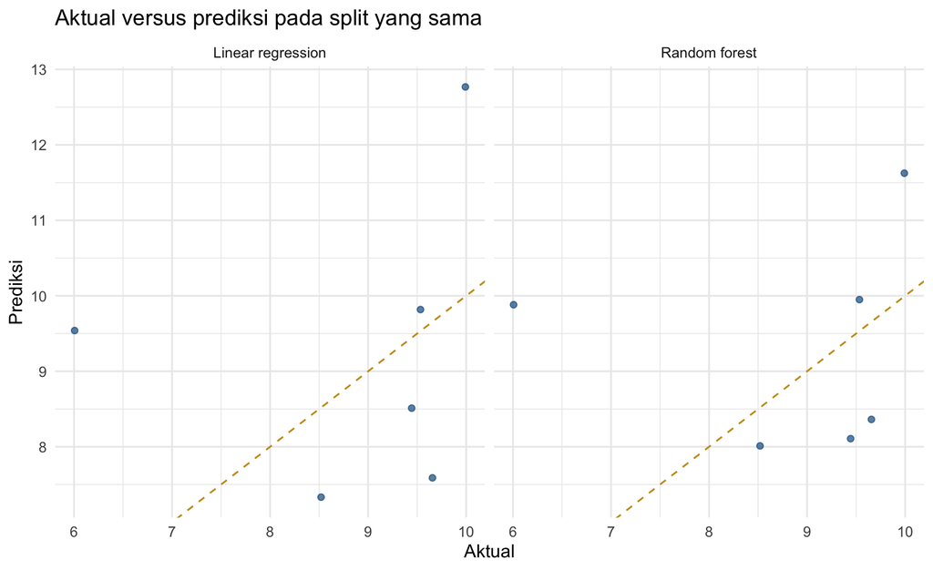

```r
vis_compare <- dplyr::bind_rows(
  lm_pred |> dplyr::transmute(actual = kemiskinan_persen, pred = .pred, model = "Linear regression"),
  rf_pred |> dplyr::transmute(actual = kemiskinan_persen, pred = .pred, model = "Random forest")
)
ggplot2::ggplot(vis_compare, ggplot2::aes(actual, pred)) +
  ggplot2::geom_abline(slope = 1, intercept = 0, linetype = 2, colour = "#C99A17") +
  ggplot2::geom_point(alpha = .7, colour = "#145B8C") +
  ggplot2::facet_wrap(~model) +
  ggplot2::labs(title = "Aktual versus prediksi pada split yang sama", x = "Aktual", y = "Prediksi")
```

## 9.9 Paket Output Machine Learning Lengkap

```r
rf_engine9 <- workflows::extract_fit_engine(rf_fit)
imp9 <- tibble::enframe(rf_engine9$variable.importance, name="feature", value="importance") |>
  dplyr::arrange(dplyr::desc(importance))
knitr::kable(imp9, digits=3, caption="Permutation variable importance Random Forest")
```

Table 9.2: Permutation variable importance Random Forest

| feature | importance |
| --- | --- |
| pdrb_perkapita_juta | 2.214 |
| internet_persen | 0.132 |
| umkm_per_1000 | 0.032 |
| akses_kesehatan | 0.014 |
| tpt_persen | -0.060 |
| ipm | -0.071 |

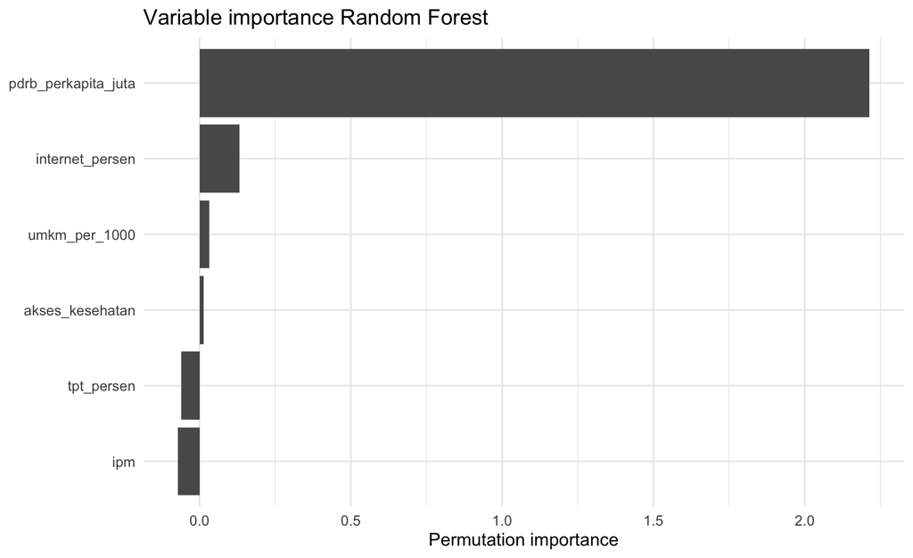

```r
ggplot2::ggplot(imp9, ggplot2::aes(reorder(feature, importance), importance)) +
  ggplot2::geom_col() + ggplot2::coord_flip() +
  ggplot2::labs(title="Variable importance Random Forest", x=NULL, y="Permutation importance")
```

```r
error9 <- dplyr::bind_rows(
  lm_pred |> dplyr::mutate(model="Linear"),
  rf_pred |> dplyr::mutate(model="Random forest")
) |> dplyr::mutate(error=.pred-kemiskinan_persen)
err_summary9 <- error9 |> dplyr::group_by(model) |>
  dplyr::summarise(RMSE=sqrt(mean(error^2)), MAE=mean(abs(error)), Bias=mean(error), MaxAbs=max(abs(error)), .groups="drop")
knitr::kable(err_summary9, digits=3, caption="Perbandingan distribusi error model")
```

Table 9.3: Perbandingan distribusi error model

| model | RMSE | MAE | Bias | MaxAbs |
| --- | --- | --- | --- | --- |
| Linear | 2.114 | 1.797 | 0.401 | 3.534 |
| Random forest | 1.896 | 1.510 | 0.464 | 3.876 |

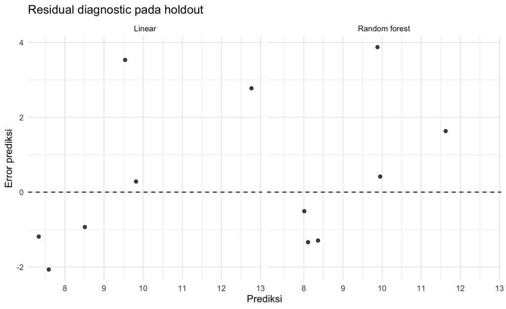

```r
ggplot2::ggplot(error9, ggplot2::aes(.pred, error)) +
  ggplot2::geom_hline(yintercept=0,linetype=2) + ggplot2::geom_point(alpha=.75) +
  ggplot2::facet_wrap(~model) + ggplot2::labs(title="Residual diagnostic pada holdout", x="Prediksi", y="Error prediksi")
```

## 9.10 Interpretasi dalam Konteks Regional

Jika random forest hanya memperbaiki RMSE sedikit tetapi jauh lebih sulit dijelaskan, model linear mungkin lebih berguna untuk dialog kebijakan. Sebaliknya, jika tujuan operasional adalah screening ribuan unit dan RF mengurangi false negatives secara substansial, kompleksitas tambahan dapat dibenarkan.

## 9.11 Latihan

1. Jelaskan bias-variance trade-off dengan bahasa nonteknis.
2. Mengapa variable importance bukan ukuran kausal?
3. Kapan baseline sederhana sebaiknya dipertahankan?
4. **Analisis:** variasikan `mtry` dan `min_n` lalu bandingkan kinerja.
5. **Analisis:** evaluasi error model pada 20% wilayah dengan kemiskinan tertinggi.
6. **Mini-case:** model RF naik 2% akurasi tetapi tidak dapat dijelaskan kepada dinas pelaksana. Tentukan kriteria keputusan apakah model baru layak dipakai.

### 9.11.1 Tugas Terstruktur Pertemuan 9

Gunakan dataset yang sama untuk baseline linear model, regression tree, dan random forest. Pastikan split sama. Bandingkan RMSE/MAE, training time secara sederhana, dan interpretability. Beri rekomendasi model untuk deployment pemerintah daerah—boleh memilih model yang bukan paling akurat bila alasannya kuat.

### 9.11.2 Kuis Formatif Pertemuan 9

1. Apa fungsi bootstrap dalam bagging?
2. Mengapa random subset fitur dipakai pada random forest?
3. Apa beda bagging dan boosting?
4. Mengapa variable importance bukan causal effect?
5. Apa makna relative error improvement 3% terhadap baseline?

## 9.12 Hubungan dengan Capstone Project

Milestone model dimulai: minimal satu baseline interpretable dan satu model alternatif. Tim harus mendokumentasikan alasan perbandingan, bukan sekadar menambah algoritma.

## 9.13 Kesimpulan

Machine learning memberi fleksibilitas, bukan otomatis validitas. Keunggulannya harus dibuktikan pada data holdout dan dikaitkan dengan keputusan kebijakan.

## 9.14 Pendalaman Magister — Tree-based machine learning

### 9.14.1 Audit metodologis

1. Tuning pada test.
2. Importance ditafsirkan kausal.
3. Lebih banyak trees dianggap selalu lebih baik secara substantif.
4. Imbalance diabaikan.
5. Model card tidak dibuat.
6. Baseline sederhana tidak dibandingkan.

### 9.14.2 Pertanyaan viva / diskusi kelas

1. Bagaimana tree memilih split?
2. Mengapa RF menurunkan korelasi tree?
3. Apa beda bagging dan boosting?
4. Apa fungsi learning rate?
5. Apa keterbatasan permutation importance?
6. Kapan model linear lebih layak dipilih?

# 10 Classification dan Prioritisasi Intervensi

## 10.1 Pendahuluan

Classification relevan saat outcome bersifat kategori: desa prioritas/nonprioritas, risiko tinggi/rendah, UMKM potensial/tidak, atau keberhasilan program. Namun threshold classification adalah keputusan yang membawa konsekuensi alokasi sumber daya.

## 10.2 Tujuan Pembelajaran

Mahasiswa mampu menerapkan logistic regression dan classifier, membaca confusion matrix, precision, recall, specificity, F1, ROC-AUC, dan memilih threshold berdasarkan biaya kesalahan.

## 10.3 Definisi dan Konsep

False negative dapat lebih mahal daripada false positive jika model digunakan untuk mendeteksi wilayah yang sangat rentan. Karena itu, accuracy saja tidak cukup, terutama bila kelas tidak seimbang.

## 10.4 Formulasi Matematis

Logistic regression:

$$\log\left(\frac{p_i}{1-p_i}\right)=\beta_0+\boldsymbol\beta^\top\mathbf x_i,$$

dengan $p_i=P(Y_i=1\mid X_i)$.

Precision dan recall:

$$Precision=\frac{TP}{TP+FP},\qquad Recall=\frac{TP}{TP+FN}.$$

F1:

$$F1=2\frac{Precision\times Recall}{Precision+Recall}.$$

### 10.4.1 Logistic regression

Untuk $Y_i\in\{0,1\}$,
$$p_i=P(Y_i=1\mid X_i).$$
Logit model:
$$\log\left(\frac{p_i}{1-p_i}\right)=\beta_0+\sum_{j=1}^{p}\beta_jx_{ij}.$$
Sehingga
$$p_i=\frac{\exp(\eta_i)}{1+\exp(\eta_i)},\qquad \eta_i=\beta_0+\mathbf x_i'\beta.$$
Odds ratio untuk kenaikan satu unit $x_j$ adalah $\exp(\beta_j)$, dengan prediktor lain tetap. Interpretasi odds ratio bukan perubahan probabilitas absolut yang konstan.

### 10.4.2 Likelihood dan cross-entropy

Likelihood Bernoulli:
$$L(\beta)=\prod_{i=1}^{n}p_i^{y_i}(1-p_i)^{1-y_i}.$$
Negative log-likelihood / binary cross-entropy:
$$-\ell(\beta)=-\sum_i\left[y_i\log p_i+(1-y_i)\log(1-p_i)\right].$$

### 10.4.3 Confusion matrix dan metrik

Dengan TP, TN, FP, FN:
$$Accuracy=\frac{TP+TN}{TP+TN+FP+FN},$$
$$Sensitivity=Recall=\frac{TP}{TP+FN},$$
$$Specificity=\frac{TN}{TN+FP},$$
$$Precision=\frac{TP}{TP+FP},$$
$$F_1=2\frac{Precision\times Recall}{Precision+Recall}.$$

Balanced accuracy:
$$BA=\frac{Sensitivity+Specificity}{2}.$$
Untuk kelas prioritas yang jarang, accuracy dapat tinggi walaupun seluruh kasus prioritas gagal ditemukan.

### 10.4.4 Threshold berbasis biaya

Jika tindakan diberikan saat $\hat p_i\ge t$, expected classification cost pada validation data:
$$C(t)=C_{FN}FN(t)+C_{FP}FP(t).$$
Pilih $t$ yang meminimalkan biaya **atau** memenuhi kapasitas intervensi. Jika pemerintah hanya mampu menangani 15% wilayah, threshold dapat dikaitkan dengan kuantil risk score, tetapi keputusan itu harus transparan.

### 10.4.5 ROC, AUC, dan precision-recall

ROC memplot TPR vs FPR dengan
$$FPR=1-Specificity.$$
AUC dapat dipahami sebagai
$$AUC=P(\hat p^{+}>\hat p^{-}),$$
probabilitas satu observasi positif acak memperoleh score lebih tinggi daripada observasi negatif acak. (Fawcett 2006)

AUC mengukur ranking discrimination, bukan calibration dan bukan manfaat kebijakan. Untuk kelas sangat imbalanced, precision–recall curve sering lebih informatif.

### 10.4.6 Calibration

Prediksi terkalibrasi berarti di antara unit dengan $\hat p\approx0.2$, sekitar 20% benar-benar positif pada data serupa. Calibration intercept/slope dapat diperiksa melalui model
$$\operatorname{logit}P(Y=1)=\alpha+\gamma\operatorname{logit}(\hat p).$$
Idealnya $\alpha=0$ dan $\gamma=1$. Calibration penting jika probabilitas dipakai untuk alokasi sumber daya, bukan hanya ranking.

## 10.5 Intuisi Metode

Threshold 0,5 bukan hukum alam. Jika anggaran hanya mampu mengintervensi 15% desa, threshold dapat ditetapkan berdasarkan kapasitas program dan tujuan, lalu kinerja serta fairness dinilai pada threshold itu.

### 10.5.1 Worked Example — confusion matrix

Dari 200 wilayah/desa: TP=30, FN=10, FP=40, TN=120.
$$Sensitivity=30/(30+10)=0.75,$$
$$Specificity=120/(120+40)=0.75,$$
$$Precision=30/(30+40)=0.429,$$
$$Accuracy=(30+120)/200=0.75,$$
$$F_1=2(0.429)(0.75)/(0.429+0.75)=0.545.$$
Interpretasi: model menemukan 75% kasus prioritas, tetapi hanya 43% dari unit yang ditandai benar-benar prioritas berdasarkan label. Jika verifikasi lapangan murah, precision ini mungkin dapat diterima; jika intervensi mahal, threshold perlu ditinjau.

### 10.5.2 Threshold trade-off

Jika threshold turun, secara umum sensitivity naik dan specificity turun. Pilih threshold dari **validation**, bukan test. Bila $C_{FN}=4$, $C_{FP}=1$:
$$C(t)=4FN(t)+FP(t).$$
Bandingkan beberapa $t$, lalu lakukan sanity check apakah jumlah unit terpilih sesuai kapasitas program.

### 10.5.3 Odds ratio vs probability

Jika $\beta=\log(2)$, odds ratio=2. Bila baseline probability 0.10, odds=0.111; setelah dua kali odds=0.222, probability=0.182. Kenaikan probability hanya 8.2 points. Bila baseline probability 0.50, odds=1 →2, probability=0.667, naik 16.7 points. Efek probability bergantung baseline.

### 10.5.4 Calibration bins

Bagi prediksi menjadi deciles/bin. Untuk bin $b$:
$$\bar p_b=\frac{1}{n_b}\sum_{i\in b}\hat p_i,\qquad
\bar y_b=\frac{1}{n_b}\sum_{i\in b}y_i.$$
Plot $\bar p_b$ vs $\bar y_b$; garis ideal $y=x$. Untuk kebijakan risk-based, calibration dapat lebih penting daripada sedikit perbedaan AUC.

### 10.5.5 R threshold table

```r
set.seed(260820)
prob <- runif(200)
y <- rbinom(200,1,prob)
thresholds <- c(.2,.3,.4,.5,.6)
threshold_table <- purrr::map_dfr(thresholds, function(t){
  pred <- as.integer(prob>=t)
  TP <- sum(pred==1 & y==1); FN <- sum(pred==0 & y==1)
  FP <- sum(pred==1 & y==0); TN <- sum(pred==0 & y==0)
  tibble(threshold=t,
         sensitivity=TP/(TP+FN), specificity=TN/(TN+FP),
         precision=ifelse(TP+FP==0,NA,TP/(TP+FP)),
         selected=TP+FP, cost=4*FN+FP)
})
knitr::kable(threshold_table, digits=3)
```

| threshold | sensitivity | specificity | precision | selected | cost |
| --- | --- | --- | --- | --- | --- |
| 0.2 | 0.980 | 0.314 | 0.578 | 166 | 78 |
| 0.3 | 0.939 | 0.500 | 0.643 | 143 | 75 |
| 0.4 | 0.898 | 0.588 | 0.677 | 130 | 82 |
| 0.5 | 0.827 | 0.735 | 0.750 | 108 | 95 |
| 0.6 | 0.724 | 0.833 | 0.807 | 88 | 125 |

### 10.5.6 Policy question before metric

- Jika tujuan **screening**, false negative biasanya lebih mahal → sensitivity.
- Jika intervensi mahal dan kapasitas terbatas → precision/PPV + cost.
- Jika ranking untuk manual review → AUC/PR + top-k capture.
- Jika probability masuk formula alokasi → calibration.

Tidak ada “metric terbaik” tanpa decision context. (Fawcett 2006)

## 10.6 Contoh dengan Data Simulasi

```r
library(tidymodels)
set.seed(260810)

# Membaca data simulasi dan menstandarkan label kelas.
# "prioritas" sengaja ditempatkan sebagai level pertama karena dalam yardstick
# level pertama adalah event class secara default.
desa <- read_csv("data/simulasi_klasifikasi_desa.csv", show_col_types = FALSE) |>
  mutate(
    .label_raw = tolower(trimws(as.character(prioritas_intervensi))),
    prioritas_intervensi = case_when(
      .label_raw %in% c("1", "prioritas", "ya", "yes", "true") ~ "prioritas",
      .label_raw %in% c("0", "non", "non-prioritas", "tidak", "no", "false") ~ "non",
      TRUE ~ NA_character_
    )
  ) |>
  select(-.label_raw)

# Guardrail pedagogis: ROC hanya terdefinisi jika kedua kelas tersedia.
# Jika file simulasi lama memiliki kelas yang terlalu timpang atau labelnya tidak
# dikenali, label simulasi dibentuk ulang dari skor kerentanan regional.
zscore_safe <- function(x) {
  sx <- stats::sd(x, na.rm = TRUE)
  mx <- mean(x, na.rm = TRUE)
  if (!is.finite(sx) || sx == 0) return(rep(0, length(x)))
  (x - mx) / sx
}

class_count <- desa |>
  filter(!is.na(prioritas_intervensi)) |>
  count(prioritas_intervensi, name = "n")

if (nrow(class_count) < 2 || min(class_count$n) < 8 || anyNA(desa$prioritas_intervensi)) {
  skor_kerentanan <- with(
    desa,
    1.00 * zscore_safe(kemiskinan_persen) +
    0.55 * zscore_safe(jarak_pusat_km) -
    0.45 * zscore_safe(akses_kesehatan) -
    0.40 * zscore_safe(kualitas_jalan) -
    0.50 * zscore_safe(internet_persen)
  )

  batas_prioritas <- as.numeric(stats::quantile(
    skor_kerentanan, probs = 0.70, na.rm = TRUE, names = FALSE
  ))

  desa <- desa |>
    mutate(
      prioritas_intervensi = if_else(
        skor_kerentanan >= batas_prioritas, "prioritas", "non"
      )
    )
}

desa <- desa |>
  mutate(
    prioritas_intervensi = factor(
      prioritas_intervensi,
      levels = c("prioritas", "non")
    )
  )

# Tampilkan keseimbangan kelas sebelum pemodelan.
class_count <- desa |>
  count(prioritas_intervensi, name = "n") |>
  mutate(proporsi = n / sum(n))

knitr::kable(
  class_count, digits = 3,
  caption = "Distribusi kelas sebelum train-test split"
)
```

Table 10.1: Distribusi kelas sebelum train-test split

| prioritas_intervensi | n | proporsi |
| --- | --- | --- |
| prioritas | 240 | 0.3 |
| non | 560 | 0.7 |

```r
# Stratified split mempertahankan proporsi kelas pada training dan testing.
sp <- initial_split(desa, prop = .8, strata = prioritas_intervensi)
trc <- training(sp)
tec <- testing(sp)

# Pemeriksaan eksplisit agar evaluasi classification tidak berjalan pada test set
# yang hanya berisi satu kelas.
if (dplyr::n_distinct(tec$prioritas_intervensi) < 2) {
  stop(
    "Testing set hanya memiliki satu kelas. Periksa distribusi prioritas_intervensi ",
    "atau gunakan data simulasi yang telah diperbarui."
  )
}

knitr::kable(
  tec |> count(prioritas_intervensi, name = "n_test"),
  caption = "Distribusi kelas pada testing set"
)
```

Table 10.1: Distribusi kelas pada testing set

| prioritas_intervensi | n_test |
| --- | --- |
| prioritas | 48 |
| non | 112 |

```r
logit <- logistic_reg() |>
  set_engine("glm") |>
  fit(
    prioritas_intervensi ~ kemiskinan_persen + jarak_pusat_km +
      akses_kesehatan + kualitas_jalan + internet_persen,
    data = trc
  )

pr <- predict(logit, tec, type = "prob") |>
  bind_cols(predict(logit, tec, type = "class")) |>
  bind_cols(tec |> select(prioritas_intervensi))

conf_mat(pr, truth = prioritas_intervensi, estimate = .pred_class)
```

```
#>            Truth
#> Prediction  prioritas non
#>   prioritas        47   0
#>   non               1 112
```

```r
metric_set(accuracy, sens, spec, precision, recall, f_meas)(
  pr,
  truth = prioritas_intervensi,
  estimate = .pred_class
)
```

```
#> # A tibble: 6 × 3
#>   .metric   .estimator .estimate
#>   <chr>     <chr>          <dbl>
#> 1 accuracy  binary         0.994
#> 2 sens      binary         0.979
#> 3 spec      binary         1
#> 4 precision binary         1
#> 5 recall    binary         0.979
#> 6 f_meas    binary         0.989
```

### 10.6.1 Visualisasi Output: ROC Curve

```r
# AUC dan ROC menggunakan "prioritas" sebagai event class.
auc_out <- yardstick::roc_auc(
  pr,
  truth = prioritas_intervensi,
  .pred_prioritas,
  event_level = "first"
)

knitr::kable(auc_out, digits = 3, caption = "ROC AUC pada testing set")
```

Table 10.2: ROC AUC pada testing set

| .metric | .estimator | .estimate |
| --- | --- | --- |
| roc_auc | binary | 1 |

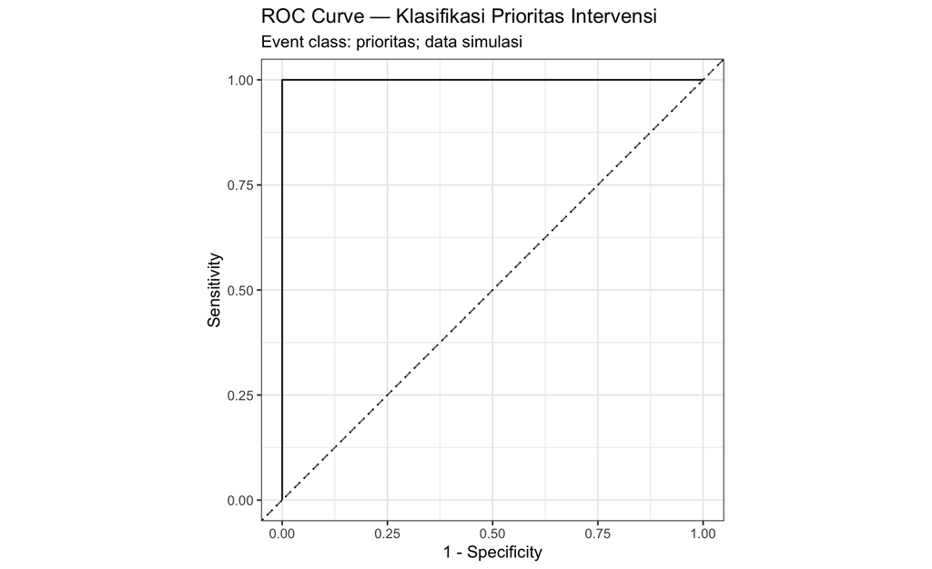

```r
roc_out <- yardstick::roc_curve(
  pr,
  truth = prioritas_intervensi,
  .pred_prioritas,
  event_level = "first"
)

autoplot(roc_out) +
  ggplot2::geom_abline(linetype = 2, alpha = .6) +
  ggplot2::labs(
    title = "ROC Curve — Klasifikasi Prioritas Intervensi",
    subtitle = "Event class: prioritas; data simulasi",
    x = "1 - Specificity",
    y = "Sensitivity"
  )
```

## 10.7 Contoh dengan Data Nyata

Classification dapat dibentuk dari data nyata dengan mendefinisikan label kebijakan, misalnya kabupaten dengan poverty rate di atas quantile 75 sebagai *screening target*. Tetapi label berbasis cut-off statistik bukan ground truth kebijakan; mahasiswa wajib menjelaskan bahwa label dibuat untuk latihan dan tidak otomatis valid untuk penetapan program.

**Kartu dataset real.**

- **Nama:** INDO-DAPOER—classification exercise berbasis poverty rate.
- **Sumber dan URL:** World Bank Data Catalog, https://datacatalog.worldbank.org/search/dataset/0041056/indonesia-database-for-policy-and-economic-research.
- **Tahun:** hingga 2018; gunakan satu periode/holdout yang konsisten.
- **Unit observasi:** wilayah–tahun.
- **Variabel/definisi:** `SI.POV.NAPR.ZS` = poverty rate; label latihan `prioritas=1` dibuat dari cut-off eksplisit (mis. kuantil 75), sementara predictors dipilih dari indikator yang tersedia sebelum keputusan.
- **Alasan digunakan:** memperlihatkan confusion matrix, probability, threshold, calibration, dan cost-sensitive decision.
- **Keterbatasan:** label cut-off adalah konstruksi pedagogis, bukan *ground truth* kebijakan; threshold harus diuji sensitivitasnya dan tidak boleh dipakai untuk keputusan nyata tanpa proses substantif. (World Bank 2026)

## 10.8 Analisis Menggunakan R

```r
# Threshold 0.30 untuk meningkatkan sensitivitas terhadap kelas prioritas.
pr2 <- pr |>
  mutate(.pred_30 = factor(if_else(.pred_prioritas >= .30, "prioritas", "non"),
                           levels = c("prioritas", "non")))
conf_mat(pr2, truth = prioritas_intervensi, estimate = .pred_30)
```

```
#>            Truth
#> Prediction  prioritas non
#>   prioritas        47   0
#>   non               1 112
```